# Counting: Numerals and numeral classifiers

Malcolm Ross

## 1. Introduction and background[^1]

The reconstruction of POc numeral terms other than ‘one’ is relatively straightforward, as POc inherited a reconstructable PMP decimal system with single-word terms up to 100. Two related matters contribute to the length of this chapter, however. One is the evident existence of numeral classifiers in POc, intimately involved in the reconstruction of numerals. The other is a search for the reasons why POc numerals and classifiers constituted such an extensive system.

The history of numeral terms since the break-up of POc, especially in Western Oceanic and SOc languages, has been complex, resulting in the loss of some (and in a few languages, all) POc numerals. This history is sketched in Chapter 15.

Recently, traditional numeral systems in many Oceanic languages have been modified or have disappeared because of their speakers’ contact with a European language. The numeral system, writes Comrie (2005), is more endangered than the language itself. The data presented here were collected either before this modernisation or from older members of the speech community who still remembered them.

Section 14.1.1 introduces numeral classifiers, as they play a role in the reconstruction of numerals. Section 14.1.2 discusses the uses of numerals in early Oceanic communities. The remaining sections are devoted to reconstruction: §14.2 to verbs of counting, §14.3 and §14.4 and their subsections to cardinal numerals, §14.5 to non-cardinal numerals, and §14.6 to classifiers.

Both numeral and classifier terms were inherited by POc. Classifiers have been lost or fossilised in many Oceanic languages, but are very much alive in others.

### 1.1. Numeral classifiers and their semantic classes

Grammarians divide English common nouns into two categories. One consists of nouns like *banana*, *chair* or *mouse*, which can form a plural and be counted: *three bananas*, *two chairs*, *six mice*. These are ‘count’ nouns. The other category contains ‘mass’ nouns, like *hay*, *firewood* or *water*, so called because they denote an undifferentiated mass of something. On its own a mass noun cannot be counted. Phrases like *two hays*, *three firewoods* or *six waters* are odd,[^2] and such nouns are counted using another noun that measures relevant quantities: *two bundles of hay*, *three loads of firewood*, *six glasses of water*. A count noun can also be counted in this way, e.g., *two hands of bananas*, but *bananas* retains its plural form in this construction.

Nouns like *bundle*, *load*, *glass* or *hand* in this construction are conventionally labelled ‘mensural classifiers’, as each denotes a certain measure of the thing(s) denoted by the noun that follows of.

Oceanic languages treat common nouns differently. Generally, no common noun has a distinct plural form, and in certain Oceanic languages, the structure used to say things like *two bundles of hay* and *three loads of firewood* is used to count all nouns. Thus for three dogs one says something corresponding to ‘three animals of dog’, and for three men ‘three humans of man’. This introduces a new complication, as ‘animals’ and ‘humans’ are not mensural, but sortal: they categorise into ‘sorts’ (Lyons 1977:463). Indeed, Oceanic classifiers fall into a number of semantic classes, indicated by the bolded words in what follows and exemplified mostly from Woleaian (Mic).

The Woleaian classifier construction is shown in (1) with **sortal** classifiers. The English classifiers above are nouns, but the Woleaian classifiers are bound forms to which the numeral is prefixed. Oceanic sortal classifiers reflect semantic classes that occur worldwide in languages with numeral classifiers (see Aikhenvald 2000:98; Senft 1995:9).

1. 1. Woleaian (Mic): (Sohn 1975:59, 206, 62)

      ‘2 people’ (lit. ‘2 animates of person’)

      | *ʐʉwe-mar* | *yaʐemar* |  |
      | --- | --- | --- |
      | 2-CLF:animate | person |  |

   2. Woleaian (Mic): (Sohn 1975:59, 206, 62)

      ‘four canoes’ (lit. ‘4 long objects of canoe’)

      | *fā-faʂ* | *wa* |  |
      | --- | --- | --- |
      | 4-CLF:long.object | canoe |  |

   3. Woleaian (Mic): (Sohn 1975:59, 206, 62)

      ‘two stones’ (lit. ‘2 round objects of stone’)

      | *ʐʉwe-faʉ* | *faʉ* |  |
      | --- | --- | --- |
      | 2-CLF:round.object | stone |  |

Sometimes a sortal classifier has the same form as the noun it classifies, as in (1c), as classifiers are often derived from nouns. Pe (1965) called such classifiers ‘repeaters’, and Benton (1968) introduced the term into Oceanic studies in his study of Chuukese classifiers. Often the ‘repeater’ denotes a larger category than the classified noun. Here the classifier *-faʉ* denotes a round object, whereas the noun *faʉ* denotes one or more stones.

Sortal classifiers can also be used like pronouns: in a conversation in which (1b) has appeared, further reference to the four canoes can be made with *fā-faʂ*, where English uses *they* or perhaps *the four*.

Bril (2014:181) provides a nice Nêlêmwa (NCal) example of meaning contrast between two sortal classifiers used with the same noun. In (2a) a living *ʃãlaga* ‘crab’ is classified as *ā-* ‘animate’, but in (2b) as *pʷa-* ‘default inanimate’, the dead crab sold at market.

2. 1. Nêlêmwâ (NCal): (Bril 2014:181)

      ‘one crab’ (living)

      | *ā-ɣīk* | *ʃãlaga* |  |
      | --- | --- | --- |
      | CLF:animate-one | crab |  |

   2. Nêlêmwâ (NCal): (Bril 2014:181)

      ‘one crab’ (dead, sold at market)

      | *pʷa-ɣīk* | *ʃãlaga* |  |
      | --- | --- | --- |
      | CLF:default.inanimate-one | crab |  |

Note that the numeral is suffixed to the classifier in Nêlêmwa, whereas in Woleaian it is prefixed.

Every Oceanic language that has numeral classifiers has a default sortal classifier that is used with inanimate nouns that do not belong to an obvious classifier category or to save the speaker selecting a classifier. In Woleaian this is *-uw*:

3. - Woleaian (Mic): (Sohn 1975:61)

     ‘one cup’

     | *se-uw* | *texax* |  |
     | --- | --- | --- |
     | one-CLF | cup |  |

The classifiers in (4) are **mensural**.

4. 1. Woleaian (Mic): (Sohn 1975:202)

      ‘8 mouthfuls of water’

      | *wari-gumʷ* | *ʂar* |  |
      | --- | --- | --- |
      | 8-CLF:mouthful | water. |  |

   2. Woleaian (Mic): (Sohn 1975:60)

      ‘one bundle of sennit’

      | *se-ʂimʷ* | *xaroxar* |  |
      | --- | --- | --- |
      | 1-CLF:bundle | sennit. |  |

A numeral + mensural.classifier combination can also be used without a following noun. Thus *wari-gumʷ* means ‘8 mouthfuls (of liquid)’, since *-gumʷ* always quantifies liquid.

A **multiplicative** classifier itself specifies a numerical quantity. English equivalents are *pair*, *dozen* and *score*.

5. - Woleaian (Mic): (Sohn 1975:202)

     ‘ten books’ (lit. ‘one ten of book’)

     | *se-ix* | *fʷuk* |  |
     | --- | --- | --- |
     | one-CLF:10 | book |  |

A multiplicative classifier’s sole function is to be multiplied by the preceding numeral. Thus Woleaian *se-ix* is 1 × 10; *ʐʉe-ix* is 2 × 10 (= 20); *seri-ix* is 3 × 10 (= 30); and so on.

Many Oceanic languages have a classifier type that is both mensural and multiplicative. Hence in (6) *-yaf* specifies both that classified objects are round and that the bundle contains ten of them (Sohn & Tawerilmang, 1976:170). This is called an **enumerative** classifier here.

6. - Woleaian (Mic): (Sohn 1975:170)

     ‘a bundle of 10 (round) coconuts’

     | *se-yaf* | *rʉ* |  |
     | --- | --- | --- |
     | one-CLF:bundle.10.round | coconut |  |

Modern Woleaian does not preserve many enumerative classifiers (Sohn 1976:284–285). Languages with more include closely related Chuukese (Benton 1968; Goodenough & Sugita 1980):

7. - Trukese (Mic): (Goodenough & Sugita 1980:354)

     ‘3 strings of 10 breadfruit’

     | *wɨnɨ-ttīt* | *mǣy* |  |
     | --- | --- | --- |
     | 3-CLF:string.10.breadfruit | breadfruit |  |

Woleaian also has **unit-of-time** classifiers, which form adverbial phrases, as in:

8. - Woleaian (Mic): (Sohn 1975:61)

     ‘one day’

     | *se-ʐan* | *ʐan* |  |
     | --- | --- | --- |
     | one-CLF:day | day |  |

Finally, Woleaian has **unit-of-measurement** classifiers, discussed in §16.1.1.

If an Oceanic language uses numeral classifiers, it will have at least mensural classifiers. Enumerative classifiers are also widespread, sortal classifiers somewhat less so, facts discussed in §14.1.2.4. The number of multiplicative classifiers is constrained by the fact that semantically they are a component of the numeral system. Unit-of-time and unit-of-measurement classifiers are rarer because their meanings are more constrained.

Scattered Oceanic languages in Micronesia, the Admiralties and New Caledonia also have a frequentative classifier which forms an adverbial phrase with the same function as reflexes of the POc frequentative prefix *pa[ka]- (§14.5.2).

9. - Ponapean (Mic): (Rehg 1981:128)

     ‘three times’

     | *pān* | *sili-pak* |  |
     | --- | --- | --- |
     | time | 3-CLF:TIME |  |

The structure of POc phrases using numeral classifiers is taken up in §14.3, their forms in §14.6.

### 1.2. The decimal system, classifiers and cultural context

**Table 14.1** Reconstructable POc lexical numerals

|  | A |  |
| --- | --- | --- |
| 1 | *sa-, *ta-sa, *tai, *ta-kai, *sa-kai | §14.4.1 and subsections |
| 2 | *rua | §14.4.2.1 |
| 3 | *tolu | §14.4.2.2 |
| 4 | *pat[i] | §14.4.2.3 |
| 5 | *lima | §14.4.2.4 |
| 6 | *onom | §14.4.3.1 |
| 7 | *pitu | §14.4.3.2 |
| 8 | *walu | §14.4.3.3 |
| 9 | *siwa | §14.4.3.4 |
|  | B |  |
| 10 | *sa=[ŋa] puluq | §14.4.5.1 and subsections |
| 20 | *rua ŋa puluq | §14.4.5.1 and subsections |
| 30 | *tolu ŋa puluq | §14.4.5.1 and subsections |
| 40 | *pati ŋa puluq | §14.4.5.1 and subsections |
| 50 | *lima ŋa puluq | §14.4.5.1 and subsections |
| 60 | *ono(m) ŋa puluq | §14.4.5.1 and subsections |
| 70 | *pitu ŋa puluq | §14.4.5.1 and subsections |
| 80 | *walu ŋa puluq | §14.4.5.1 and subsections |
| 90 | *siwa ŋa puluq | §14.4.5.1 and subsections |
|  | C |  |
| 100 | *sa=[ŋa] Ratus | §14.4.5.1 |
| 200 | *rua ŋa Ratus | §14.4.5.1 and subsections |
| 300 | *tolu ŋa Ratus | §14.4.5.1 and subsections |
| 400 | *pati ŋa Ratus | §14.4.5.1 and subsections |
| 500 | *lima ŋa Ratus | §14.4.5.1 and subsections |
| 600 | *ono(m) ŋa Ratus | §14.4.5.1 and subsections |
| 700 | *pitu ŋa Ratus | §14.4.5.1 and subsections |
| 800 | *walu ŋa Ratus | §14.4.5.1 and subsections |
| 900 | *siwa ŋa Ratus | §14.4.5.1 and subsections |

The decimal systems of some Micronesian and Polynesian languages famously have multiplicative classifiers for very high powers of ten (Harrison & Jackson 1984; Bender & Beller 2006a). Kiribati *te-ea*, Ponapean *rar*, Woleaian *se-piy*, Rennellese *nimo* and Nukuoro *se-lō* all mean ‘a million’. The first morpheme of the Kiribati, Woleaian and Nukuoro terms is ‘one’, the second morpheme a multiplicative classifier (§14.1.1). Like several other Micronesian languages, Woleaian uses classifiers to count up to 100,000,000 (Harrison & Jackson 1984).

10. - Woleaian (Mic)

      ‘a hundred million books’ (lit. ‘one hundred.million of book’)

      | *sa-ŋeʐai* | *fʷuk* |  |
      | --- | --- | --- |
      | one-CLF:100,000,000 | book |  |

This raises a few questions. Were POc speakers able to count using powers of ten higher than a hundred, or did this ability develop later? And did they use multiplicative classifiers for this purpose? The answer to both questions is almost certainly, ‘Yes,’ causing one to ask in what circumstances these were used.

When a numeral system is eroded by contact, the highest simple numerals are usually replaced first. Outside Micronesia and Polynesia, we still find lexical items for 1,000 and higher powers of 10 in scattered languages whose number systems were recorded before their invasion by a Pacific pidgin or a colonial language. In Lou and Nyindrou (both Adm) the highest simple numeral is 10,000. Motu (PT) counts *daha* ‘1000’, *ɣerebu* ‘10,000’, *domaɣa* ‘100,000’. New Ireland and NW Solomonic languages typically have a term for ‘1000’, Roviana (MM) also for ‘10,000’. Bugotu (SES) boasts *toɣa* ‘1,000’, *mola* ‘10,000’, *feferi* ‘100,000’, *vuðera* ‘1,000,000’ and *vaðeɣila* ‘10,000,000’. Mellow (2014) and Healey (2013) respectively record Owa (SES) and Maskelynes (NCV) numerals up to a million. The presence of these numerals suggests rather strongly that early Oceanic speakers did count as far as perhaps ten million. Yet where simple numerals for powers of ten above 100 can be reconstructed, the reconstructions are almost all limited to a local group of languages (Eastern Admiralty, south New Ireland, Buka/N Bougainville, Choiseul, New Georgia, Santa Isabel, Northern Vanuatu).

The evidence is thus contradictory. POc forms for powers above 100 cannot be reconstructed, but the likelihood that such numerals were used seems considerable. How is this contradiction to be resolved? If, as suggested below, knowledge of these numerals was restricted to high-status older men and their use was limited to certain special occasions (§14.1.2.1), then there was a real possibility that they were forgotten across the generations and later recreated (§14.4.6). This would account for the seeming contradiction.

#### 1.2.1. Ceremonial exchange and wealth redistribution

What then were these numerals used for? Apparently to count up the quantities of various gifts, mainly of food, at customary feasts. On ethnographic evidence feasts took two main forms: (i) wealth distribution for the purpose of maintaining or gaining status and (ii) ceremonial exchanges of various kinds. In wealth distributions the feast-giver might be a hereditary chief or, in communities without chieftainship, someone intent on becoming a ‘big man’. These exchanges have atrophied in many Oceanic societies since European contact, but not before they had been described by various linguists and ethnographers. Crowley (2006a:61) mentions the function of Avava (NCV) numerals.

> Higher numerals were traditionally used for counting yams associated with the highly elaborate grade-taking ceremonies for which Malakula is well known in the ethnographic literature, and all of the neighbouring languages appear to have had similarly elaborate counting systems. Preparations for these ceremonies often took years, and it was necessary to keep track of who had provided large numbers of yams over this period.

Hogbin (1964a:65-66) describes how a Longgu (SES) man holds a status-gaining feast.

> By about three o’clock all the food stood in front of Atana’s house. He and his immediate kinsmen had contributed the 250 pounds of dried fish, the 3000 yam cakes, 11 bowls of yam pudding, and 8 pigs. Soon the Longgu villagers, together with some of the residents of the surrounding settlements, began drifting into the hamlet. Nearly everybody brought along some dried fish and a few yam cakes, and several of the leaders sent a pig and a bowl of pudding as well. On the final count the various heaps contained 300 pounds of fish, nearly 5000 yam cakes, 19 bowls of pudding, and 13 pigs.

A parallel situation from northern Malaita is described by Hogbin (1939).

In northern Vanuatu, a man climbed the scale of ranks in a similar way. François (2013:235) writes:

> The way for a man to climb the political scale of *suᵐbʷe involved the public display of considerable wealth. This would take the form, typically, of a number of pigs …. Besides, the candidate had to bring offerings of kava, along with massive quantities of shellmoney …. This shellmoney consisted of small cone shells (Conus sp.) that had been patiently filed into circular discs, then pierced and threaded onto a very long string of beads … The quantity of such money required for some higher ranks could measure up to 10 fathoms in length, and involved considerable work on part of the candidate’s female relatives.

An oft-quoted account of chiefly wealth distribution comes from Elbert’s grammar of the Polynesian language Rennellese (Elbert 1988:186):

> Much of a chief’s life before 1938 (aside from fighting) consisted of fishing and raising fine gardens, and presenting the fruit of the land and of the sea, carefully counted, first to the gods with impressive rituals, and then to relatives and allies. A chief’s prestige was gauged by the size of the offerings he was able to amass; this was an indication of the resources he commanded, his industry, and his personality. The emphasis on carefully counted quantity extended to competitive giving. In [a later section] is a text of a discussion of such a competition in 1937 or 1938, in which 10,000 coconuts and 7,600 banana bunches were collected, offered to the gods, and distributed.

People with counting skills were required at such ceremonies in Polynesia, whether in Rennell, in Hawai’i or in Tonga (Bender & Beller 2007b:228). Counting similarly occurred at Tolai feasts in New Britain, and Paraide (2008) alludes to today’s near-disappearance of traditional counting.

Carrier (1981:471–474) describes ceremonial exchange on Ponam Island (Admiralties). Every important social event included exchange, usually between in-laws. A man made a gift to an in-law, who later presented a return gift. Descendants of siblings of the donor’s ancestors also contributed (and later the return gift would be distributed among them). The closer the relationship to the donor, the larger the contribution. At an appointed time the gifts amassed by each group of relatives were brought to the donor’s house and laid out on the ground in a formal display that represented the closeness of each group’s relationship to the donor. The donor or his representative then counted the gifts, announcing what was in each pile and in whose name it was given, then the goods were carried to the recipient’s house and placed in a single pile. Formal speeches ensued, then the recipient arranged the gifts to reflect the groups of relatives to whom he would distribute the gifts. He then also counted the gifts, and the ceremony ended.

The ethnographic literature refers to the counting of feast gifts in other Oceanic communities. Panoff (1970:364), writing about the Mengen (NNG) of New Britain, mentions the counting of taro tubers ceremonially brought from the gardens for a feast and of fish formally cooked in earth ovens on festive occasions. Garde (2015:126) alludes to the counting of food items at feasts in Sa-speaking communities in Pentecost (NCV). Bender and Beller (2007a), summarising research into numeral use in Polynesian societies, comment that “A concern with collecting and redistributing resources was particularly strong in islands with powerful chiefs or kings, such as Tonga or Tahiti…”. Alkire (1970) describes the counting of coconuts associated with a funerary exchange on Woleai Atoll.[^3]

The distribution of these customs across Oceanic subgroups suggests that they date back to the Lapita culture and that POc speakers counted gifts (mostly food), an effect of which was to maintain the inherited decimal counting system up to high powers of ten.

Did the ability to count huge food gifts facilitate counting and calculation in other areas? The answers here are mixed. Only Carrier (1981) examines this in any detail, and she finds that skills in mental arithmetic, associated, for example, with card games, are well developed among Ponam speakers. She notes that “Elderly unschooled people keep score mentally as accurately as young people do with pencil and paper” (1981:469). Smith (1986), on the other hand, provides an overview of counting practices in Papua New Guinea and concludes that the POc decimal counting system was not a necessary part of gift-giving and exchange. In societies that were most influenced by their Papuan speaking neighbours, number systems atrophied. The Adzera of the upper Markham Valley of mainland New Guinea (NNG) maintained traditional feasting practices, but formal presentations of gift objects and the comparison of one quantity with another were evidently what continued to matter. Smith writes, “Bunches of bananas in Adzera, for example, were not counted prior to distribution, but mounted on a structure reaching the top of a coconut tree.” His case is supported by the fact that the Adzera numeral system consists only of the numerals 1 and 2. Similarly, Duau (PT) speakers, with a base-5-20 system, reckon the amount to be repaid by pile size rather than by counting (Thune 1978:74).

#### 1.2.2. Trade

It is sometimes assumed that trade must have fostered the use of a decimal numeral system, but the evidence for this is ambiguous. Smith (1986) points out that traditional trade among Oceanic speakers was an extension of ceremonial exchange. He writes,

> …ever since Malinowski’s pioneering work on the kula expeditions of Milne Bay it has been recognised that trade in Melanesia also involves some of these ceremonial features. A great deal of the energy expended in kula shell exchanges, for example, appears to outside observers to have little justification in terms of economic benefit. Thus it might be argued that such overseas expeditions should be regarded not so much as trading ventures as complex social rituals.

He notes, though, that applying this thinking to the trade network of the Vitiaz Strait is controversial. Harding (1970) thinks that the ceremonial aspects of trade have been over-emphasised, and that the traders of the Strait, at least, were primarily interested in commerce, acting as middlemen between the Bilbil network centred near present-day Madang and networks that ran along the north and south coasts of New Britain. The Siassi ‘engaged in social rituals of exchange as a means of acquiring valued need serving goods’ (1970:108). Smith writes,

> They acted as middlemen, exchanging goods at favourable rates by manipulating exchange ratios in the different Vitiaz Strait ports. A pig, for example, could be exchanged on Umboi for 5-10 packets of sago, which in turn were exchanged at Sio or Gitua for 50-100 pots. These pots could then be transported to New Britain, where they yielded 5-10 pigs (Harding 1970: 139). Thus goods of little value in one community were transported to others where they were in short supply, or had high prestige, usually for ceremonial purposes, and thereby appeared to yield a considerable profit. …

Even in the situation described by Harding (1967, 1970), the need for a counting system as sophisticated as the POc decimal system would have been minimal. Gift exchange always entailed exchanging an amount of a particular commodity for an equivalent amount of the same commodity. The Siassi traders exchanged a set amount of a one commodity for an ‘equivalent’ amount of another. This did not entail sophisticated calculation skills. Indeed, numeral systems on either side of the Vitiaz Strait are base-5-20 or -5-10-20 systems that have more in common with digit tally systems than with the extensive POc system (§15.4).

#### 1.2.3. Other uses of counting?

Another pointer to the restricted application of decimal counting is that various ethnographers have observed that Oceanic speakers do not count people or their ages or time in any form.

Carrier (1981:417) writes of Ponam speakers:

> One of the most striking things about Ponams is that they do not count people. Despite obvious skill with numbers, no one has any idea how many people live on the island, how many households there are or how many children are attending the primary school. Even more surprising, many parents of large families do not know how many children they have without stopping to think about it. And almost no one knows that there are 14 clans on the island, although everyone knows their names and can calculate the number in a few moments. Ponams simply are not interested in counting people; apparently these quantifications tell them nothing interesting about social relations. But other sorts of quantifications do, most importantly those used in exchange.

Thune’s (1978:74) account of numeration among the Duau (PT) of Normanby Island overlaps strikingly with Carrier’s, except that the Duau appear not to use counting even in gift exchanges.

> … mothers of children only a few years old do not know (nor do they care about) the ages of their children. It is not so much that one couldn’t develop means for keeping track of age using the Loboda numerical terminology, or for that matter the introduced English terminology, as there is no interest in doing so. … Loboda people of course are quite able to refer to the age of people: they have terms for infant (*memeyo*), child (*gwama*), adolescent boys and girls (*tubuhau*, *gomwagwehine*), and so forth. But in using these terms to speak of the age of people, they think of a stage or fraction of a person’s life rather than of an abstract number of countable years.

Alkire (1970:37) comments on Woleaian (Mic) counting, which is decimal and employed in ceremonial exchanges,

> An individual does not think of his age in terms of years (a unit of measurement of little traditional importance on Woleai) or of seasons (a unit which is important and discussed below), but only comparatively, as being younger or older than some other person of reference. The life span of a person, however, is divided into several “ages” which vary according to sex.

Elbert (1988:186) writes,

> Not everything was counted in Rennellese culture. No one knew or was at all interested in his own age. One was content with the vague terms for the life span: infancy (*mi’ime’o’anga*), adolescence (*bagokaa ’anga*), middle age (*mi’itauiku ’anga*), old age (*tauiku*), and extreme old age or senility (*hu’oitouiku*, *neneba*, *tau mago ti’aki*). Years and generations were not counted at all. Time was told by looking at the sky.

Labrecque (2009) comments on Southeast Ambrym speakers:

> If you were to ask someone how many children they have, they would have to name each one and count on their fingers as they think of their children by name, not number. Even in the same conversation, 2 minutes later, if asked to verify that they had 5 children, they would need to start counting all over again. This is the same for number of gardens, pigs, cattle, chickens.

#### 1.2.4. The origin of Oceanic enumerative classifiers

Formal counting at feasts was mostly performed with a decimal system, but this was accompanied by the use of enumerative classifiers. That is, each product was arranged or bundled in units that contained a certain number of each product, and it was these units that were counted, rather than the product itself.

Elbert (1988:187) describes a wealth distribution 20 years later than the one quoted in §14.1.2.1, by which time the young no longer fully understand the counting practices of their elders:

> In 1958 on Rennell the traditional distributions were to some extent still practiced on great occasions, with the Christian god replacing those of Rennell. The main event of the greatest holiday, New Year’s, was the food distribution. A few elderly men supervised what seemed to the young an impressive but overly fussy way of arranging the huge displays. Why should large fish, reptiles, and humans be counted differently than small fish? Why should yams and breadfruit be counted in pairs, banana bunches in fours, and bunches of taro stalks in fives?

The last two sentences refer to the use of enumerative classifiers in counting. The Rennellese elders counted with enumerative classifiers of different quantities, the quantity depending on the item counted.

Fox (1931) takes the connection between Arosi numerals and feasting for granted when he discusses the term for ten million coconuts: ‘The people say they never needed in practice a larger numeral term, as they never prepared for a feast more than ten million nuts, and so they did not go any further.’

Enumerative classifiers have been recorded in many Oceanic languages (for specifics see §14.6.3). Ivens (1930) and Hogbin (1964a), both cited by Hill & Unger (2018), mention large numbers of foodstuffs at ceremonial exchanges. They write,

> A reader of their ethnographic work may wonder how they knew there were 5,000 yam cakes or 20,000 yams, and why it was important to the communities to calculate exactly how many yam cakes or yams there were. There was no written numeration so, once counted, how did speakers remember these numbers?

Hill & Unger’s answer is that SE Solomons languages use enumerative classifiers[^4] (§14.1.1) to count items in tens, thereby reducing counting and memorisation (also Bender & Beller 2007a, 2007b). In (11) *paga* is an enumerative classifier meaning ‘ten animals’. The structure is an analogue of English ‘a school of fish’, but *school* specifies no quantity, whereas Lengo *paga* is a group of ten animals.

11. - Lengo (SES)

      ‘one “ten.animals” of fish’

      | *sakai* | *na* | *paga* | *ni* | *iɣa* |  |
      | --- | --- | --- | --- | --- | --- |
      | one | ART | ten.animals | ASSOCIATIVE | fish |  |

But this cannot have been the whole answer to the ‘how’ question. There must have been at least two other ingredients to counting large quantities. First, some enumerative classifiers counted multiples of other enumerative classifiers (§§14.6.3–4). Second, people kept tallies by various ethnographically recorded means. These included plucking the leaflets from a fern (Fox 1931; Paraide 2008) or tying knots in a string (Codrington 1891:353). Codrington also describes more complex tallies.

> At Saa when yams are counted two men count out each five, making ten, and as each ten is made they call out ‘one’, ‘two’, and so on. A man sits by, and when ‘ten’ is called making a hundred, he puts down a little yam for a tally.

Bender & Beller (2006a, 2007b) argue convincingly that enumerative classifiers count products that are both culturally salient and abundant (§14.6.3). Cultural salience here means that the counted products are considered worthy of ceremonial exchange or as representative of the donor’s distributions. This suggests in turn that enumerative classifiers arose from nouns that designated the smallest collection units in which products were laid out at these ceremonies. However, no POc enumerative classifier can be securely reconstructed, and the evidence for this hypothesis consists of the circumstantial evidence offered in the subsections of §14.6.3. It includes the fact that the items counted with an enumerative classifier are the items that are presented in ceremonial exchanges and that the classifiers themselves participated in classifier hierarchies where each classifier denoted a multiple of a numeral associated with the counted product. The numeral was often two, i.e. a pair.

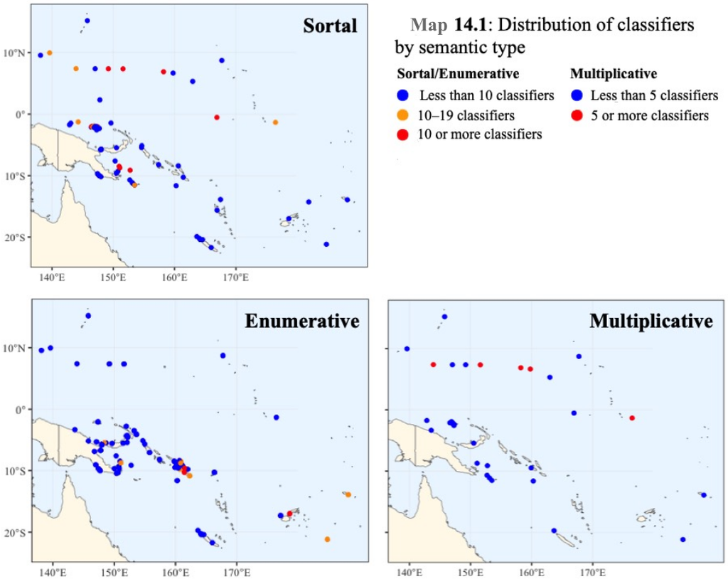

**Map 14.1:** Distribution of classifiers by semantic type

This account of the emergence of enumerative classifiers receives support from their geographic distribution. Map 14.1 shows the distribution of the types of classifiers (§14.1.1) across Oceanic languages (whether they are bound or free forms is disregarded). Mensural classifiers are omitted because they occur in all languages. Much of Polynesia is omitted because of its huge extent. The maps are based on the numbers of classifiers recorded in what are probably fairly complete listings in the literature, but it is likely that some classifiers have disappeared in the recent past. What are of interest, then, are languages where larger number of classifiers appear than elsewhere. Sortal classifiers occur in larger numbers than elsewhere in Micronesian and in some Admiralties (Seimat, Ponam) and Papuan Tip (Kilivila, Muyuw and Sudest) languages. Multiplicative classifiers occur in relatively larger quantities in Micronesian languages (Harrison & Jackson 1984). Strikingly, however, enumerative classifiers occur more widely in Map 14.1 than either sortal or multiplicative classifiers. They occur in languages of New Ireland, Bougainville and the Solomon Islands, which largely lack grammaticalised sortal or multiplicative classifiers, and they are more common than sortal classifiers in Bauan Fijian, Tongan and Samoan—but less common in Micronesian and Admiralties languages.

This difference in distribution between sortal and enumerative classifiers reflects a difference in history. A core set of sortal classifiers is of POc—and earlier—antiquity (§14.6.1), but there is little evidence of POc enumerative classifiers. This does not mean that they did not occur, but that there has been a continual process of replacement by fresh invention as a result of the ceremonial processes described above. The map shows that they have also been innovated in places where sortal and multiplicative classifiers do not occur, and in Micronesian and Admiralties languages have not been innovated in languages where sortal classifiers are plentiful. The difference in distribution reflects a difference in the cultural contexts of sortal and enumerative classifiers. The former are in everyday use, the latter in ceremonial use.

## 2. Reconstruction: Proto Oceanic terms for ‘count’

The only term meaning ‘to count’ that has non-Oceanic cognates is POc *i(y)ap, reflected only in a few North New Guinea and Papuan Tip languages. A possible reason for its disappearance is its form. PMP *ihap became POc *iap. In languages where final consonants were lost it became †*ia or just †*ya, defying the Oceanic preference for disyllabic roots and becoming ripe for replacement.

| **PMP** |  | *ihap | ‘count’ (ACD) |
| --- | --- | --- | --- |
| **POc** |  | *iap | [VI] ‘count’ |
| **POc** |  | *iap-i- | [VT] ‘count’ |
| NNG | Tami | *yau* | ‘count’ |
| NNG | Bing | *(su)yiy-ai* | ‘count’ |
| PT | Maisin | *(ko)yav-i* | ‘count’ |
| PT | Gumawana | *-(katu)yaiv-i(na)* | ‘count’ |
| PT | Dawawa | *-(s)iava* | ‘count’ (initial *s-* unexpected) |
| PT | Ubir | *-iyab* | ‘count; read’ |
| PT | Wedau | *-yava* | ‘count’ |
| PT | Gapapaiwa | *-iava* | ‘count; read’ |

The most widely attested POc verb meaning ‘count’ is POc *wase, but this was just one of its meanings, which included at least ‘distribute (food at a feast), divide up, count out’, carrying an association with feasting and the distribution of ceremonial gifts as well as food, meshing with the context of decimal counting described in §14.1.2. The primary sense of *wase was almost certainly ‘distribute’, and so the supporting cognate set and discussion of its senses is found in §13.5.1.

POc *topoŋ (V) ‘measure’ is reconstructed in §16.3. It has fewer ‘count’ reflexes than the terms reconstructed here, and those reflexes may well be local extensions from the sense ‘measure.’

The cognate set reflecting POc *luku ‘count’ has a rather unusual distribution. It is given here in the hope that further research will shed light on it. Reflexes have been found only in languages of New Britain’s Gazelle Peninsula and in the Torres and Banks Islands of north Vanuatu. The distribution may reflect later migration from New Britain to Vanuatu (§15.9.2).

| **POc** |  | *luku | ‘count’ |
| --- | --- | --- | --- |
| MM | Minigir | *lu-luku* | ‘count’ |
| MM | Tolai | *lu-luk* | ‘count’ |
| MM | Ramoaaina | *lu-luk* | ‘count’ |
| MM | Bilur | *lu-luk* | ‘count’ |
| NCV | Hiw | *yʉkʷ* | ‘count’ |
| NCV | S Gaua | *luɣ* | ‘count’ |
| NCV | Lakon | *luɣ-luɣ* | ‘count’ |
| NCV | Loh | *luk* | ‘count’ |
| NCV | Vera’a | *luku-n* | ‘count’ |

Although the Santa Isabel terms listed under ‘cf. also’ bear some formal similarity to reflexes of the verb given in POLLEX as PPn *tau ‘count’, the sound correspondences between the two sets do not permit a reconstruction.[^5]

| **PPn** |  | *tau | ‘count, tell’ (POLLEX) |
| --- | --- | --- | --- |
| Pn | Niuean | *totou* | ‘read, count’ |
| Pn | Samoan | *fai-tau* | ‘count’ |
| Pn | Tuvalu | *tau* | ‘count, read’ |
| Pn | Emae | *tāu-a* | ‘count, read’ |
| Pn | Nukuoro | *dau* | ‘count, read’ |
| Pn | Rennellese | *tau* | ‘count, enumerate’ |
| Pn | Takuu | *tau* | ‘count, enumerate’ |
| Pn | Tikopia | *tau* | ‘count, reckon, measure’ |
| Pn | West Futunan | *tau-a* | ‘count, add, read’ |
| Pn | West Uvean | *tau, tau-a* | ‘count, number, read’ |
| Pn | Pukapukan | *ta-tau* | ‘count’ |
| Pn | Tahitian | *tau* | ‘count, number’ |
| Pn | Tongareva | *ta-tau* | ‘read, count’ |
| Pn | Tuamotuan | *ta-tau* | ‘describe, relate, recount’ |
| Pn | Marquesan | *ta-tau* | ‘count, recite’ |
| Pn | Māori | *ta-tau* | ‘count’ |

cf. also:

| MM | Zabana | *taho* | ‘count’ |
| --- | --- | --- | --- |
| MM | Laghu | *taho* | ‘count’ |
| MM | Kokota | *ta-taho* | ‘count’ |

| **PPn** |  | *lau | ‘recite, count, list’ (POLLEX) |
| --- | --- | --- | --- |
| Pn | Tongan | *lau* | ‘mention; think of; consider; count, reckon, estimate, assess; read, recite’ |
| Pn | Niuafo’ou | *lau* | ‘count’ |
| Pn | Samoan | *lau* | ‘read; call out, give out song verse by verse’ |
| Pn | Anutan | *rau* | ‘count’ |
| Pn | Tuvalu | *lau* | ‘count, recite’ |
| Pn | East Futunan | *lau* | ‘read, recite; count’ |
| Pn | East Uvean | *lau* | ‘count, calculate’ |
| Pn | Tikopia | *rau* | ‘enumerate, count, go through items on a list’ |
| Pn | Pukapukan | *waka-lau* | ‘count’ |

## 3. The structure of POc phrases containing an attributive numeral

### 3.1. The *NUMERAL *ŋa* CLASSIFIER and *sa-CLASSIFIER structures

Table 14.1 shows that POc numerals for tens and hundreds, e.g. *sa=[ŋa] puluq ‘10’, *rua ŋa puluq ‘20’, *tolu ŋa puluq ‘30’, had a structure in which the morphemes *puluq ‘10’ and *Ratus ‘100’ appear to be multiplicative classifiers (§14.1.1). The numeral is connected to the classifier by the ligature *ŋa.[^6] This *ŋa seems to have originally been absent after *sa- ‘one’, a proclitic that was immediately attached to the classifier. The *NML *ŋa* CLF structure and its variant *sa*-CLF are of PMP antiquity, and are reflected as far down the Oceanic tree as Polynesian. This raises the question, Did the POc structure reflect a productive numeral classifier structure, or was it just a fossil?

Being productive would mean that the structure was also used with other classifiers—and it was, according to evidence from both higher and lower nodes of the Austronesian tree. Table 14.2 shows forms for 1–3, 10–30 and 100–300 in one western and three central Malayo-Polynesian languages (i.e. languages at higher nodes; see figure 1.2) and POc. Certain facts are obvious. Cognates of POc *sa=[ŋa] puluq ‘10’ and *sa=[ŋa] Ratus ‘100’ are preceded by a proclitic that is cognate with POc *sa= ‘one’. In Javanese *sa* ‘1’ is not followed by a ligature cognate with *ŋa, but the ligature occurs after 2 and 3. In the other three languages the ligature has been generalised to occur with ‘one’ as well. In Javanese *ŋa is reflected as *-ŋ* on simple numerals from 2 upward. In Hawu *ŋa-puluq and *ŋa-Ratus have become *ŋuru* and *ŋahu*, in Kambera *-ᵐbulu*[^7] and *ŋahu*, and in Kéo *mbudu* and *ŋasu*. In Kéo the morpheme order is reversed for numerals 2 and above.

**Table 14.2** Non-Oceanic and POc 1–3, 10–30 and 100–300

|  | Javanese (wMP) | Hawu (cMP) | Kambera (cMP) | Kéo (cMP) | POc |
| --- | --- | --- | --- | --- | --- |
| 1 | *siji* | *əhi* | *diha* | *ha* | _*(i)sa_¹ |
| 2 | *loro* | *ɗue* | *dua* | *rua* | *rua |
| 3 | *təlu* | *təlu* | *tailu* | *tedu* | *tolu |
| 10 | *sa=puluh* | *he-ŋuru* | *ha-ka-mbulu ha* | *mbudu* | *sa=[ŋa] puluq |
| 20 | *ro=ŋ puluh* | *ɗue ŋuru* | *dua ka-mbulu* | *mbudu rua* | *rua ŋa puluq |
| 30 | *təlu=ŋ puluh* | *təlu ŋuru* | *tailu ka-mbulu* | *mbudu tedu* | *tolu ŋa puluq |
| 100 | *s-atus* | *he-ŋahu* | *ha-ŋahu* | *ha ŋasu* | *sa=[ŋa] Ratus |
| 200 | *ro=ŋ atus* | *ɗue ŋahu* | *dua ŋahu* | *ŋasu rua* | *rua ŋa Ratus |
| 300 | *təlu=ŋ atus* | *təlu ŋahu* | *tailu ŋahu* | *ŋasu tedu* | *tolu ŋa Ratus |

¹There were probably several POc forms meaning ‘1’ (§14.4.1).

The critical point here is that in each language other classifiers occur in the same slot as the multiplicative classifiers in Table 14.2. Javanese mensural classifiers occur in it: *sa=prapat* ‘a quarter’, *təlu=ŋ prapat* ‘three-quarters’; *ro-ŋ taun* ‘two years’; *pata-ŋ jam* ‘4 hours’ (Robson 1992). Hawu sortal classifiers occur there: *he=ŋiʔu wawi* ‘one pig’, *ɗue ŋiʔu wawi* ‘two pigs’, where *ŋiʔu* is the classifier for animals (Walker 1982). Kambera has sortal classifiers based on shape. After *ha-* ‘one’, these do not reflect *ŋa, but after ‘2’ or greater, the initial consonant undergoes a change that does reflect *ŋa: *ha=puŋu pena* ‘one pen’ vs *dua mbuŋu pena* ‘two pens’; *ha=wala kapambal* ‘one plank’ vs *ha dua mbala kapambal* ‘two planks’ (Klamer 2010).[^8] In Kéo the reversal of constituents with 2 and above attested in Table 14.2 also occurs with sortal classifiers: *aki ha=ᵑgaʔe* [man one-CLF] vs *aki ⁿgaʔe dima* [man CLF 5] (*ᵑgaʔe* ‘human being’) (Baird 2002).

This evidence that *NML *ŋa* CLF occurred in languages at higher nodes than POc only says that POc could have retained the productive structure. The tens and hundreds in Table 14.1 could be fossils. However, evidence from Admiralties, Micronesian and Polynesian languages tells us that POc did retain *NML *ŋa* CLF as a productive numeral classifier structure. Admiralties and Micronesian languages have NML CLF order, reflecting POc *NML *ŋa* CLF, but less obviously than in Table 14.2.

**Table 14.3** Ponam (Adm) numerals reflecting POc *ŋa and a sample of classifiers

|  | A | B | C | D | E | F | G |
| --- | --- | --- | --- | --- | --- | --- | --- |
|  | 1–4 | tens | hundreds | heaps of coconuts | bundles | branches | fish hooks |
| 1 | *si* | *sa-ŋuf* | *sa-ŋat* | *sa-hum* | *sa-bis* | *sa-kal* | *sa-kau* |
| 2 | *luo-f* | *lu-ŋuf* | *lo-ŋat* | *lo-hum* | *lo-bis* | *lo-kal* | *lo-kau* |
| 3 | *talo-f* | *tulu-ŋuf* | *tulu-ŋit* | *tulu-hum* | *tulu-bis* | *tulu-kel* | *tulu-kau* |
| 4 | *fa-f* | *fa-ŋuf* | *fa-ŋat* | *fa-hum* | *fa-bis* | *fa-kal* | *fa-kou* |

Micronesian classifiers are exemplified in §14.1.1 and are well described in the various grammars of Micronesian languages. The situation resembles that of Admiralties languages. The ligature *ŋa is preserved in PMic *-ŋawulu ‘unit of ten (in counting)’ and PChk *-ŋa-ratu ‘thousand (numeral classifier)’ (Bender et al. 2003a; cf data in §14.4.5.1). It is not obviously inherited in Micronesian forms with other classifiers, but *ŋa is sometimes reflected in a prenasalisation of the following classifier: see under POc *-tau ‘animate; person’ (§14.6.1) and POc *-pui ‘bunch, group’ (§14.6.2).

Finally, *ŋa is alive and well in certain Polynesian languages.Table 14.4 shows classifiers used in the Tongan reflex of the POc *NML *ŋa* CLF structure. Column A shows the numerals 1–4. Columns B and C show that the structure of 10–40 and 100-400 is identical to that of the enumerative classifiers in columns D–G. Thus *-fulu* ‘unit of 10’ and *-au* ‘unit of 100’ are also multiplicative classifiers. One apparent anomaly is *ho-ŋo-fulu* ‘10’, which retains the structure of PPn *ha-ŋa-pulu ‘10’ where the other classifiers in the row have replaced *ha-ŋa- with the PPn non-specific article *te-.

**Table 14.4** Tongan (Pn) classifiers reflecting PPn *ŋa

|  | A | B | C | D | E | F | G |
| --- | --- | --- | --- | --- | --- | --- | --- |
|  | 1–4 | tens | hundreds | scores of coconuts | tens of scores of coconuts | tens of scores of yam pieces¹ | tens of fathoms high or deep |
| 1 | *taha* | *ho-ŋo-fulu* | *te-au* | *te-kau* | *te-fua* | *te-fuhi* | *te-kumi* |
| 2 | *ua* | *uo-fulu* | *ue-ŋe-au* | *ue-ŋa-kau* | *uo-fua* | *uo-ŋo-fuhi* | *uo-ŋo-kumi* |
| 3 | *tolu* | *tolu-ŋo-fulu* | *tolu-ŋe-au* | *tolu-ŋa-kau* | *tolu-fua* | *tolu-ŋo-fuhi* | *tolu-ŋo-kumi* |
| 4 | *fā* | *fā-ŋo-fulu* | *fā-ŋe-au* | *fā-ŋa-kau* | *fā-fua* | *fā-ŋo-fuhi* | *fā-ŋo-kumi* |

¹For planting.

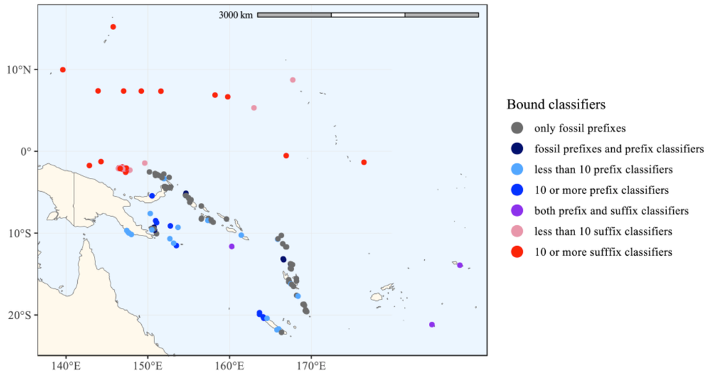

**Map 14.2:** Bound classifiers in the SW Pacific

### 3.2. The CLASSIFIER + NUMERAL structure

This, however, is not the whole story. There is evidence that alongside the *NML *ŋa* CLF structure POc also had a *CLF NML structure. Evidence for this comes from SHWNG languages, Oceanic languages with this structure, and especially Polynesian.

The SHWNG languages Buli (Maan 1951:42), Taba (Bowden 2001:242–245), Ambel (Arnold 2018:159–161) and Magey Matbat (Remijsen 2010:287–290), all have CLF NML order.[^10] None has a reflex of *NML *ŋa* CLF. Rongga (Arka 2008) and Waima’a (Himmelmann 2010:56), CMP languages of Wallacea and cousins to SHWNG also have a CLF NML structure. But as shown in §14.3.1 not all CMP languages have CLF NML. Some reflect *NML *ŋa* CLF This implies that the CLF NML structure was innovated somewhere in the CEMP linkage and was inherited into POc. The origin of CLF NML seems straightforward. As most prefixed classifiers reflect earlier nouns (§14.6), CLF NML reflects the regular noun-phrase order noun NML.

For classifiers other than ‘unit of 10’ and ‘unit of 100’ non-Polynesian Oceanic languages retain either CLF NML or NML [*ŋa] CLF, but not both. The classifier precedes the numeral in some Papuan Tip[^11] a few Meso-Melanesian,[^12] and all New Caledonian languages. This distribution is strikingly areal, as Map 14.2 shows. In the north a classifier follows the numeral. In the south it precedes it.

Blust (2013:284–285) briefly discusses ‘onset runs’ in numerals. These are runs of numerals that begin with the same segment or syllable. He includes Buma (TM) *tilu* ‘2’, *tete* ‘3’, *teva* ‘4’, *tili* ‘5’, *tuo* ‘6’, *tibi* ‘7’, *tua* ‘8’, *tudi* ‘9’ and Mwotlap (NCV) *voyo* ‘2’, *vetel* ‘3’, *vevɛt* ‘4’. He comments that they result from prefixation of unknown morphemes. In these two cases it seems likely that they reflect prefixation of a no longer productive classifier: *tau- ‘human being’ in Buma, and the default classifier *pua- in Mwotlap (§14.6.1). Fossilised prefixes on simple numerals are rife in the southern prefixing area, stretching from New Ireland in the north to the southernmost languages of Vanuatu (Map 14.2).

### 3.3. A conclusion

On this evidence it is difficult to avoid the untidy conclusion that POc retained both the *NML [*ŋa*] CLF structure and the *CLF NML structure, and that various languages either (i) generalised CLF NML, but usually retained NML *ŋa* CLF in counting tens and hundreds; or (ii) generalised NML *ŋa* CLF; or (iii) lost numeral classifiers altogether.

Some Polynesian languages are striking in that they retain both structures. In this respect they form a relic area which supports the claim that POc also had both structures. Clark (1999) reconstructs both structures for PPn, and an inspection of Tongan, Samoan and Rennellese data confirms this.[^13] It evidently continued the POc situation. Unlike Admiralties and Micronesian, where all counting is done with a classifier, PPn classifiers were only used to count certain nouns associated with what Elbert (1988:192) terms “planting, fishing, and ostentatious display”. If a classifier was used with a numeral to express a number less than 10, then CLF NML order was used. For example, PPn *toka- ‘human’ (Clark 1999:198) was used to count people up to 9, e.g. *toka-rua ‘two (people)’. For quantities of 10 and above, either structure might be used, depending on what one was counting. Exactly how this division of labour worked in PPn is unclear, as languages of the two first-order Polynesian groups, Tongic and Nuclear Polynesian, do not always agree. But one thing is clear: when PPn used the NML CLF structure, the classifier was always enumerative (§14.1.1), denoting a multiple of the thing counted.

## 4. Reconstructing cardinal numerals: serial, attributive, and predicative

Cardinal numerals (‘one’, ‘two’, ‘three’ etc) are reconstructed in §14.4.1–14.4.4. They are used in two ways. In **serial** counting, the speaker says the numbers one after the other in sequence. When a numeral is used for quantification it is either **attributive** or **predicative**. An attributive numeral forms part of a noun phrase (e.g. two houses, twelve pigs). A predicative numeral is a predicate, as in *We are two* in the sense ‘There are two of us’.

It seems probable that POc serial counting was done with plain root forms, as in Mussau and in Micronesian languages. In their quantifying function POc simple decimal numerals above ‘one’ seem to have functioned both attributively and predicatively. From the perspective of POc grammar, this is uncontroversial. POc had very few adjectives (Ross 1998a), and most properties were encoded as verbs, simply appearing unaffixed when attributive. However, it seems that POc attributive numerals either formed a class of their own or were a quantifier subclass, as they took the prefix *ka- when they occurred attributively, as in (12), and perhaps occurred before the noun they quantified.

12. 1. Mussau (Adm): (Brownie & Brownie 2007:51)

       ‘three big canoes’

       | *ko-tolu* | *olimo* | *namū* |  |
       | --- | --- | --- | --- |
       | ATTRIB-3 | canoe | big |  |

    2. Ughele (MM): (Frostad 2012:59)

       ‘four girls and two men’

       | *ka* | *made* | *vineki* | *meke* | *ka* | *rua* | *koreo* |  |
       | --- | --- | --- | --- | --- | --- | --- | --- |
       | ATTRIB | 4 | girls | and | ATTRIB | 2 | men |  |

    3. Kwamera (SV): (Lindstrom & Lynch 1994:16)

       ‘two houses’

       | *nimʷa* | *kəru* |  |
       | --- | --- | --- |
       | house | 2 |  |

In the cognate set below, most reflexes of *ka- are fossilised, i.e. they occur as part of the cardinal numeral regardless of its function. There are many languages where *ka- is reflected as the first element only of ‘one’. These instances are excluded here, as they appear to reflect a distinct but homophonous morpheme participating in some of the many forms for ‘one’ either alone or as their first syllable (§14.4.1).

| **POc** |  | *ka- | [ATTRIBUTIVE] |
| --- | --- | --- | --- |
| Adm | Mussau | *ɣa-, ka-, ko-* | [ATTRIB] (*ɣa-*: 2, 4-9; *ka-* 1, 10; *ko-* 3) (Brownie and Brownie 2007: 48–51) |
| MM | Tangga | *ka-* | [SERIAL] (all) (Maurer 1966: 74) |
| MM | Vaghua | *ka-* | [FOSSIL] (1–9) |
| MM | Varisi | *ka-* | [FOSSIL] (1–9) |
| MM | Simbo | *ka-* | [FOSSIL] (1–3, 8) |
| MM | Ghanongga | *ka-* | [ATTRIB] (4–9) (Chambers 2009: 84) |
| MM | Roviana | *ka-* | [FOSSIL] (2) |
| MM | Ughele | *ka-* | [ATTRIB] (all; also SERIAL with 1-2) (Frostad 2012: 58) |
| MM | Marovo | *ka-* | [FOSSIL] (2) |
| MM | Vangunu | *ka-* | [FOSSIL] (2) |
| MM | Bareke | *ka-* | [FOSSIL] (2, 4–9) |
| NCV | Tamambo | *a-* | (1–9, W dialect *ɣa-*) |
| SV | Utaha | *ka-* | [FOSSIL] (2-3) |
| SV | Lenakel | *ka-, ke-, kə-* | [FOSSIL] (2-9) |
| SV | Kwamera | *ka-, ku-, kə-* | [FOSSIL] (2–5) |

Blust’s (2013:284–285) discussion of ‘onset runs’ was mentioned in §14.3.2. One of the runs Blust cites is Neve’ei (NCV) *iru* ‘2’, *itl* ‘3’, *ifah* ‘4’, *ilim* ‘5’. The *i-* prefix is a realis 3SG subject marker. In neighbouring Neverver the paradigm is (Barbour 2012:157):

|  | REALIS | IRREALIS |
| --- | --- | --- |
| 2 | *i-ru* | *ib-ru* |
| 3 | *i-tl* | *ibi-tl* |
| 4 | *i-vas* | *iʙ-was* |
| 5 | *i-lim* | *ib-lim* |

The fact that there is a realis/irrealis contrast shows (a) that these numerals are (stative) verbs; and (b) that syntactically they are the predicates of relative clauses rather than attributives. The phrase in (14) is more literally translated as ‘small bows of theirs that are two’:

14. - Neverver (NCV): (Barbour 2012:157)

      ‘two small bows of theirs’

      | *nivis-bratn* | *lele* | *titi-dr* | *i-ru* |  |
      | --- | --- | --- | --- | --- |
      | bow-real | small | P:3-PL | 3REALIS:SG-two |  |

In a number of Oceanic languages predicative numerals with realis prefixes have been reanalysed as attributives, with fossilised *i-*, *e-* or (in SW Santo) *mo-*.

### 4.1. One

Oceanic languages display a plethora of forms for ‘one’. This is an exception to the claim that, across language families, numerals 1 to 5 are slow to change relative to both other numerals and to basic lexicon (Pagel, Atkinson & Meade 2007; Pagel & Meade 2018). Previous accounts have tended to gloss over this.

Where a term for ‘one’ is known to be serial or attributive in function, this is shown below. Where a form is glossed ‘a’ or ‘some’ or marked as an indefinite article, this tells us that it is used attributively, but does not necessarily mean that there is a distinct serial form.

#### 4.1.1. *sa-, *sa, *tasa, *tasi and *ta

Some nouns always took a numeral + classifier combination as an attribute, and others took a simple numeral (§14.3). In the former case, the attribute was *sa-CLF. In the latter case, the attributive marker *ka- (§14.4) was possibly used, but we cannot be sure that it occurred with ‘one’. POc *(i)sa ‘one’ is also reflected as the PPn indefinite article *sa (ACD), which, with an irregular vowel change, became Proto Nuclear Polynesian *se (Clark 1976:50).[^14] Thus POc *(i)sa was attributive, hovering between a numeral and an indefinite article.

PNCV *sa-wa is included under *(i)sa because it seems to be a local development in more northerly areas of Vanuatu. Added *-wa, sense unknown (perhaps POc *pua- DEFAULT CLASSIFIER), also occurs in *tai-wa, in an overlapping area. N-C Vanuatu terms often reflect further additions.

| **PAn** |  | *isa, *esa, *asa | ‘one’ (ACD) |
| --- | --- | --- | --- |
| **POc** |  | *(i)sa | ‘one’ (attributive); ’’ |
| NNG | Mangap | *sa* | ‘some’ |
| NNG | Barim | *sa* | ‘some’ |
| NNG | Amara | *so* | ‘some’ |
| NNG | Lamogai | *(i)sa* | ‘one’; ‘some’ |
| PT | Gapapaiwa | *sa(go)* | ‘one’; ‘another’ |
| PT | Boanaki | *sa(go)* | ‘one’ |
| MM | Nakanai | *(i)sa-sa* | ‘one’ |
| SES | Owa | *ta* | ‘one’ |
| NCV | Rano | *sa* | ‘one’ |
| **PNCV** |  | *sa-wa | ‘one’ |
| NCV | Sa | *su* | ‘a’; ‘one’ |
| NCV | N Ambrym | *hu* | ‘one’ |
| NCV | Orkon | *ho(l)* | ‘one’ |
| NCV | Daakaka | *swa* | ‘one’ |
| NCV | Lonwolwol | *hu* | ‘one’ |
| NCV | Letemboi | *sua* | ‘one’ |
| NCV | Unua | *soɣa* | ‘one’ |
| NCV | Maskelynes | *sua* | ‘one’; |
| **Proto N Malakula** |  | *sa-ɣa-l | ‘one’ |
| NCV | Malua Bay | *sxa(l)* | ‘one’ |
| NCV | Tirax | *haxa(l)* | ‘a’; ‘one’ |
| NCV | Navwien | *(i)saɣa(l)* | ‘one’ |
| **Proto CW Malakula** |  | *sava[ɣ,m] | ‘one’ |
| NCV | Neve’ei | *sava(ɣ)* | ‘one’ |
| NCV | Neverver | *(i)sɣa(m)* | ‘one’ |
| NCV | Avava | *sap(m)* | ‘a’; ‘one’ |
| NCal | Tinrin | *sā* | ‘one’ |
| NCal | Xârâcùù | *ʃā* | ‘one’ |
| Mic | Kosraean | *so(ko)* | ‘other’ |
| Mic | Pulo-Annan | *de-* | ‘one’ |
| **PPn** |  | *sa | ’’ (Clark 1976: 50) |
| Pn | Tongan | *ha* | [INDEFINITE ARTICLE] |
| Pn | Niuean | *ha* | [SINGULAR INDEFINITE ARTICLE] |
| **PNPn** |  | *se | ’’ (Clark 1976: 50) |
| Pn | East Futunan | *se* | [INDEFINITE ARTICLE] |
| Pn | Rennellese | *he* | [SINGULAR, NON-SPECIFIC ARTICLE] |
| Pn | Pukapukan | *e* | [INDEFINITE ARTICLE] |
| Pn | Hawaiian | *he* | [INDEFINITE ARTICLE] |

It seems reasonable to associate a serial form *ta-sa with the above.

| **POc** |  | *ta-sa | ‘one’ (PEOc: Pawley 1972:52; ACD; serial) |
| --- | --- | --- | --- |
| **Proto Kilivila** |  | *-ta-za | ‘one’ |
| PT | Kilivila | *-tala* | ‘one’ |
| PT | Muyuw | *-(i)tan* | ‘one’ |
| PT | Gawa | *-tara* | ‘one’ |
| PT | Gumawana | *ta-ya[mo]* | ‘one’ (*-mo* ‘only’) |
| MM | Vitu | *taða* | ‘some’ |
| MM | Meramera | *tasa* | ‘one’ |
| MM | Roviana | *tasa* | ‘one’ (serial) |
| MM | Gao | *tasa* | ‘one’ |
| MM | Kokota | *taho* | ‘one’ (serial, archaic) |
| **Proto Tongic** |  | *taha | ‘one; another’ |
| Pn | Tongan | *taha* | ‘one; someone, anyone; person; other, another’ |
| Pn | Niuean | *taha* | ‘one, any, an; singly, by itself; another’ |
| Pn | Niuafo’ou | *taha* | ‘one’ |

Clark (1999) takes PNPn *tasi to be an idiosyncratic development from PPn *tasa, and these forms are listed below with apparent cognates that may imply POc *ta-si.

| SJ | Yamna | *tes* | ‘one’ |
| --- | --- | --- | --- |
| SJ | Sobei | *tesesesi* | ‘one’ |
| NCV | Atchin | *(i)tes* | ‘one’ (SERIAL) |
| NCV | Namakir | *(i)teh* | ‘one’ |
| Pn | Samoan | *tasi* | ‘one’ |
| Pn | Tuvalu | *tasi* | ‘one’ |
| Pn | Rennellese | *tasi, tahi* | ‘one’ |
| Pn | Ifira-Mele | *tasi* | ‘one’ |
| Pn | East Futunan | *tasi* | ‘one’ |
| Pn | Tikopia | *tasi* | ‘one’ |
| Pn | Rapanui | *tahi* | ‘one’ |
| Pn | Hawaiian | *kahi, (ʔe)kahi* | ‘one’ |
| Pn | Mangareva | *(e)tai, taʔi* | ‘one’ |
| Pn | Marquesan | *tahi* | ‘one’ |
| Pn | Māori | *tahi* | ‘one’ |

It is very probable that the *ta of *ta-sa reflected a PAn indefinite article, the origin of which is briefly discussed in Lynch et al. (2002:71). This raises the question of how *sa and *ta differed. The one clue is that *sa was a numeral that in some languages was reinterpreted as an indefinite article, whereas the reinterpretation of *ta seemingly moved in the opposite direction. Another possibility is that *sa was a non-specific indefinite article, and *ta specific indefinite (in keeping with its earlier case-marking function).

In many of the forms listed below, the reflex of *ta is followed by one or more apparently monosyllabic morphemes. Some suffixed forms, reflecting PPT *-mo, *-qa and *-moqa, evidently meant ‘only’. If *ta was indeed the indefinite article, then these forms may have specified that its meaning in this context was ‘one’. With reasonable confidence, final *-n* or *-na* is a singular marker reflecting POc *-ña, which, suffixed to an attributive adjective, marked a noun phrase as singular.

| **POc** |  | *ta | ‘one’ (INDEFINITE ARTICLE) |
| --- | --- | --- | --- |
| NNG | Bariai | *(e)ta* | ‘some, any’ |
| NNG | Mangap | *ta* | ‘one’ |
| NNG | Mangap | *tata(ŋa)* | ‘a few’ |
| NNG | Barim | *ta* | ‘one’ |
| NNG | Sengseng | *ta* | ‘one’ |
| NNG | Wogeo | *ta* | ‘one’ |
| NNG | Yabem | *ta(gɛŋ)* | ‘one’ |
| NNG | Yabem | *ta-ɛŋ, tɛŋ* | ‘a, some’ |
| **PPT** |  | *ta | ‘one’ |
| **Proto Sudest-Nimoa** |  | *-ta[ɣa] | ‘one’ |
| PT | Sudest | *ra, re(ɣa)* | ‘one’ |
| PT | Nimoa | *-ta(ga)* | ‘one’ |
| PT | Misima | *(e)te(ga)* | ‘one’ |
| **Proto North Mainland/D’Entrecasteaux** |  | *ta-mo[qa]- | ‘one’ |
| PT | Gumawana | *ta-ya(mo)* | ‘one’ |
| PT | Iamalele | *(ʔai)ta(moga-na)* | ‘one’ (*ʔai* < POc *kai- CLF) |
| PT | Ubir | *(kai)ta(mom)* | ‘one’ (*kai* < POc *kai- CLF) |
| PT | Doga | *ta(mo-na)* | ‘one’ |
| PT | Minaveha | *(ai)ta(mo(ata))* | ‘one’ (*ai* < POc *kai- CLF) |
| PT | Wedau | *ta(gogi)* | ‘one’ |
| PT | Suau (Bonalua) | *ta(ya)* | ‘one’ |
| **Proto Central Papuan** |  | *ta | ‘one’ |
| PT | Taboro | *ta* | ‘one’ |
| PT | Motu | *ta, ta(mo-na)* | ‘one’ |
| PT | Roro | *ha(momo)* | ‘one’ |
| MM | Bola | *ta(ku)* | ‘one’ |
| MM | Kara (East) | *ta* | ‘one’ |
| NCV | Bierebo | *ta* | ‘one’ |
| NCV | Lewo | *ta(ŋa)* | ‘one’ |
| **PNCal** |  | *tta | ‘one’ |
| NCal | Voh-Koné | *θā* | ‘one’ |
| NCal | Paicî | *cā-* | ‘one’ |
| NCal | Ajië | *ra* | ‘one’ |

#### 4.1.2. Constituent monosyllables

In §14.4.1.3 below are listed other widely attested forms for ‘one’. Taken together with the forms reconstructed above, it becomes obvious that across Oceanic ‘one’ is often either one of the monosyllables in (15) or a disyllable made up of two of them. The monosyllables form a pattern.

| *sa | *si | *sai |
| --- | --- | --- |
| *ta | *ti | *tai |
| *ka | — | *kai |

Of the monosyllables in (15) all but *si occur alone as ‘one’. Initial *si- and *ti- tend to occur in the same combinations as *sa- and *ta-, suggesting that at various times and places *si- and *sa- have been in an allomorphic or allophonic relationship, and so have *ti- and *ta-. Final *-si occurs only in *ta-si, an apparent variant of *ta-sa, discussed above. Final *-ka only occurs in contexts in which *-kai also occurs, so they too are treated as one morpheme. This leaves us with the monosyllables in the lefthand column of (16), which also shows the disyllables formed from them. Disyllables that occur only once in the data or only in a small closely knit subgroup are excluded. Bolded forms are those reconstructed in §14.4.1.1.

| *sa | … | … | *sa-kai |
| --- | --- | --- | --- |
| *sai | *sai-sa | … | … |
| *ta | *ta-sa | … | *ta-kai |
| *tai | *tai-sa | … | … |
| *ka | … | *ka-ti | … |
| *kai | *kai-sa | … | *kai-kai |

POc disyllables tend to have at most three moras, and out of the nine possible 4-mora forms to which *sai, *tai and *kai could give rise, only the reduplicate *kai-kai is putatively attested.

This still gives far more forms for ‘one’ than are expected in a single language. Can this be explained? Several factors may contribute to this situation. One is perhaps that an independent morpheme should have a minimum of two moras. One strategy for achieving this with single-mora reflexes of *sa, *ta or *ka is to add a morpheme meaning ‘only’, as noted in §14.4.1.1. When two of the monosyllables in (15) join to form a term for ‘one’ in (16), the second was perhaps being used in the sense of ‘only’.

Some reflexes of POc *sa and *ta (§14.4.1.1) also function as indefinite articles. The semantic distinction between attributive ‘one’ and an indefinite specific article is small. In *My sister married a handsome man*, the phrase *a handsome man* refers to an individual known to the speaker, just as *one person* does in *Only one person came to my party*. But it is only a short move from here to *My sister wants to marry a handsome man* or *I’ll meet one boy tonight*, where a and one may refer to a specific individual or to an indefinite member of the class ‘man’/‘boy’. Possibly the semantic links from ‘one’ to a specific article and from there to an indefinite article are enough to bring about the coining of disyllabic forms as a means of disambiguation.

Another explanation lies in marking the serial/attributive distinction (§14.4). The POc proclitic *sa- ‘one’ was clearly attributive, as it was used with classifiers (§14.4.1.1). The corresponding serial form was perhaps *ta-sa. The serial/attributive distinction can be reconstructed with reasonable certainty for two Oceanic subgroups: PSES *kesa ‘one (serial)’ (< *kai-sa) vs PSES *sa-kai ‘one (attributive)’, and PMic *tai-sa ‘one (serial)’ vs PMic *te- ‘one (attributive)’ (Bender et al. 2003a).

Reconstructing forms that are monosyllables or are constructed from them (see below) is tricky in any event, as there is an increased probability that homophonous forms have different origins. A case in point is initial *kai-. It may be the *kai- in (15); or it may reflect the classifier for long rigid objects *kai- (§14.6.1).

#### 4.1.3. Other widely attested forms for ‘one’

This subsection contains forms that are widely enough attested to imply a reconstruction. ‘Widely enough attested’ means that they have reflexes on both sides of the Near/Remote Oceanic boundary (§1.4.4.2). The disyllables in (16) are certainly not all of POc antiquity, and it is likely that the same morpheme sequences have been innovated independently in various times and places. They are presented here because organising the data in this way indicates what is there, and suggests future research.

##### 4.1.3.1. *tai and *tai-

Forms reflecting *tai are so widespread that this appears to have been a standalone POc form for ‘one’. It is perhaps an extended form of *ta (§14.4.1.1), but the function of added *-i is not known. As mentioned above, there are various local additional syllables.

| **POc** |  | *tai | ‘one’ |
| --- | --- | --- | --- |
| **PWAd** |  | *tai- | ‘one’ |
| Adm | Kaniet | *tē-* | ‘one’ |
| Adm | Seimat | *te-* | ‘one’ |
| Adm | Wuvulu | *ai* | ‘one’ (serial) |
| Adm | Wuvulu | *e-* | ‘one’ (attributive) |
| SJ | Kayupulau | *tai* | ‘one’ |
| SJ | Tobati | *tei* | ‘one’ |
| NNG | Sio | *tai(tu)* | ‘one’ |
| NNG | Kaulong | *te(hen)* | ‘one’ |
| NNG | Gedaged | *tai* | ‘one’ |
| NNG | Kairiru | *tai* | ‘one’; ‘some (uncountable)’ |
| NNG | Numbami | *te* | ‘a’ |
| NNG | Hote | *te* | ‘a’ |
| PT | Miniafia | *tai(mon)* | ‘one’ |
| PT | Kakabai | *te(gana)* | ‘one’ |
| PT | Balawaia | *te(bona)* | ‘one’ |
| TM | Nagu | *ɞte* | ‘one’ (attributive) |
| TM | Nagu | *tete* | ‘one’ (serial) |
| TM | Natügu | *tesə* | ‘one’ (< *tai-sa; serial) |
| TM | Nebao | *tua* | ‘one’ (< *tai-wa ?) |
| NCV | Ambae | *te(a)* | ‘one’ (serial) |
| NCV | Merei | *(e)se* | ‘one’ |
| NCV | Araki | *(he)se* | ‘one’ |
| NCV | Mafea | *te(a)* | ‘one’ |
| NCV | Tamambo | *(a)te(a)* | ‘one’ |
| NCV | Southeast Ambrym | *tei* | ‘one’ |
| NCV | Paamese | *tāi* | ‘one’ |
| NCV | Lewo | *tai* | ‘a, some’ (INDEFINITE ARTICLE) |
| NCV | Lewo | *tā(ga)* | ‘one’; ‘the same’ (attributive) |
| **PNCV** |  | *te-wa[le] | ‘one’ |
| NCV | Loh | *tuwe* | ‘one’ |
| NCV | Mwesen | *(ni)tiwia(l)* | ‘one’ |
| NCV | Mwotlap | *(VI)tiwa(ɣ)* | ‘one’ |
| NCV | Mota | *tuwa(le)* | ‘one’ |
| NCV | Baetora | *tivʷa(le)* | ‘one’ |
| NCV | Ambae | *(ka)tewa(le)* | ‘one’ (attributive) |
| NCV | Raga | *(ɣai)tuvʷa* | ‘one’ |
| NCV | Sowa | *tuwa(l)* | ‘one’ |
| NCV | Valpei | *tew* | ‘one’ |
| NCV | Nokuku | *tev* | ‘one’ |
| **PMic** |  | *te- | ‘one’ (attributive) (Harrison and Jackson 1984: 66) |
| Mic | Kosraean | *se* | ‘one’ |
| Mic | Kiribatese | *tēra* | ‘one’ (< *tai-sa; serial) |
| Mic | Kiribatese | *te-* | ‘one’ (attributive) |
| Mic | Marshallese | *ci-* | ‘one’ |
| Mic | Trukese | *ēt* | ‘one’ (< *tai-sa; serial) |
| Mic | Trukese | *e-, i-* | ‘one’ (attributive) |
| Mic | Puluwatese | *ye-* | ‘one’ (attributive) |
| Mic | Woleaian | *yet* | ‘one’ (< *tai-sa; serial) |
| Mic | Woleaian | *se-* | ‘one’ (attributive) |
| Mic | Ponapean | *ɛ̄t* | ‘one’ (< *tai-sa; serial) |
| Mic | Ponapean | *e-* | ‘one’ (attributive) |

##### 4.1.3.2. *sakai and *takai

The morph *kai ‘one’ is fairly widely recorded with and without extensions in Western Oceanic languages: e.g. NNG: Takia *kai-k*; Apalik *ke*; Poeng *ke-na*; PT: Tawala *e-mosi*; Duau *kai-geda*; MM: Tigak *kai*; Babatana *kə-ke*; Roviana *kɛ-ke* (attributive); Kokota *kaike* ‘one’ (attributive) (cf. also *kai-sa; §14.4.1.3.3).

The two sets immediately below, *sa-kai and *ta-kai, appear to be parallel extensions of *sa and *ta (§14.4.1.1). They are not assigned here to POc, as multiple independent origins are possible.

*sa-kai ‘one’

| **Proto Bwaidoga** |  | *sa-qe-ana | ‘one’ |
| --- | --- | --- | --- |
| PT | Iduna | *saʔey(ana), sey(ana)* | ‘one’ (< Proto Bwaidoga *sa-qe-ana) |
| MM | Lavongai | *sikei* | ‘one’ (SERIAL and ATTRIBUTIVE) |
| MM | Kara (East) | *saɣa* | ‘one’ |
| TM | Asumboa | *saka* | ‘one’ |
| NCal | Xârâgurè | *ʃaxā* | ‘one’ |
| **PSES** |  | *sa-kai | ‘one’ (attributive) |
| SES | Bugotu | *sikei* | ‘one’; ‘any, other’ (ATTRIBUTIVE) |
| SES | Lengo | *sakai* | ‘one’ |
| SES | Tolo | *cika, cikai* | ‘one’ |
| SES | Longgu | *teʔe* | ‘one’ (ATTRIBUTIVE) |
| SES | To’aba’ita | *teʔe* | ‘one’ (ATTRIBUTIVE) |
| SES | Kwaio | *teʔe* | ‘one’ (ATTRIBUTIVE) |
| SES | ’Are’are | *taʔai* | ‘one’ |
| NCV | Tape | *(i)sig* | ‘one’ |
| NCV | Southwest Bay | *(i)siʔ* | ‘one’ |
| NCV | Namakir | *siki(tek)* | ‘one’ |
| **Proto Efate** |  | *si-kai | ‘one’ |
| NCV | Nguna | *sikai* | ‘one’ |
| NCV | Lelepa | *skei* | ‘one’ |
| NCV | South Efate | *(i)skei* | ‘one’ |
| SV | Utaha | *soɣoi* | ‘one’ |

*ta-kai ‘one’; ‘other’

| NNG | Dami | *taka(le)* | ‘one’ |
| --- | --- | --- | --- |
| NNG | Medebur | *taka-na* | ‘one’ |
| NNG | Medebur | *taka(raka)* | ‘other’ |
| NNG | Kairiru | *taka(naŋ)* | ‘other’ |
| NNG | Zenag | *tika* | ‘one’ |
| NNG | Piu | *tika* | ‘one’ |
| PT | Nimoa | *-tia* | ‘one’ |
| MM | Label | *takai* | ‘one’ |
| MM | Tolai | *tikai* | ‘one’ |
| MM | Tangga | *tika, tike* | ‘one’ (SERIAL; Maurer 1966:74) |
| NCV | Naha’ai (Malfaxal) | *(i)tɛx* | ‘one’ |
| NCV | Avok | *-ciki(nene)* | ‘one’ |
| NCV | Nasvang | *(i)cigai* | ‘one’ |
| NCal | Ajië | *rāxã̄* | ‘one’ |
| NCal | Ôrôe | *rakẽ* | ‘one’ |

##### 4.1.3.3. *kaisa

*kai ‘one’ and its extensions are mentioned in §14.4.1.3.2. One of these forms, *kai-sa, meets the ‘widely enough attested’ criterion (§14.4.1.3). Like *sakai and *takai, and for the same reason, it is not assigned to POc.

*kai-sa ‘one’ (serial)

| NNG | Aria | *kesa* | ‘one, some’ |
| --- | --- | --- | --- |
| PT | Are | *kesa(na)* | ‘one’ |
| MM | Tabar | *kes* | ‘one’ |
| MM | Madak | *kes* | ‘one’ |
| MM | Sursurunga | *kes* | ‘one’ |
| MM | Torau | *kāsa* | ‘one’ |
| MM | Gao | *kahe(ni)* | ‘one’ |
| MM | Maringe | *kaise(i)* | ‘one’ (ATTRIBUTIVE) |
| MM | Maringe | *keha* | ‘one’ (SERIAL) |
| **PSES** |  | *kesa | ‘one’ (serial) |
| SES | Bugotu | *keha* | ‘one’ (SERIAL) |
| SES | Gela | *keza* | ‘one’ |
| SES | Ghari | *kesa* | ‘one’ |
| SES | Longgu | *eta* | ‘one’ (SERIAL) |
| SES | To’aba’ita | *eta* | ‘one’ (SERIAL) |
| SES | Arosi | *eta* | ‘one’ (SERIAL) |
| SES | Owa | *eta(ɣai)* | ‘one’ |
| TM | Natügu | *esə* | ‘one’ |

### 4.2. From two to five

The inherited decimal numerals from 2 to 5 are reflected in so many Oceanic languages that a cognate set of several pages could be mustered for each. Since reconstruction is straightforward, only a sample from each small language group is given in the interests of space.

#### 4.2.1. Two

Below are reflexes of POc *rua ‘2’.

| **PAn** |  | *duSa | ‘2’ (ACD) |
| --- | --- | --- | --- |
| **PMP** |  | *duha | ‘2’ (ACD) |
| **POc** |  | *rua | ‘2’ (ACD) |
| Yap | Yapese | *ruw* | ‘2’ |
| Adm | Mussau | *lua* | ‘2’ (SERIAL) |
| Adm | Seimat | *hũõ-hu* | ‘2’ |
| Adm | Aua | *(e)rua(i)* | ‘2’ |
| Adm | Lou | *rue(p)* | ‘2’ (*-p* < POc *pua- DEFAULT CLASSIFIER) |
| Adm | Ponam | *luo(f)* | ‘2’ (*-f* < POc *pua- DEFAULT CLASSIFIER) |
| SJ | Kayupulau | *to(ti)* | ‘2’ |
| NNG | Gitua | *rua* | ‘2’ |
| NNG | Mangap | *ru* | ‘2’ |
| NNG | Poeng | *lua* | ‘2’ |
| NNG | Bilibil | *ru* | ‘2’ |
| NNG | Manam | *(o)ru* | ‘2’ |
| NNG | Bukawa | *lú* | ‘2’ |
| NNG | Mapos Buang | *lu* | ‘2’ |
| NNG | Numbami | *luwa* | ‘2’ |
| PT | Sudest | *-iwɔ* | ‘2’ |
| PT | Kilivila | *-yu* | ‘2’ |
| PT | Dobu | *(ʔe)rua* | ‘2’ |
| PT | Gapapaiwa | *rua* | ‘2’ |
| PT | Motu | *rua* | ‘2’ |
| MM | Vitu | *rua* | ‘2’ |
| MM | Tabar | *lua* | ‘2’ |
| MM | Sursurunga | *ru* | ‘2’ |
| MM | Tangga | *u* | ‘2’ |
| MM | Minigir | *(i)ruə* | ‘2’ |
| MM | Petats | *(hua)lu* | ‘2’ (*hua-* < POc *pua- DEFAULT CLASSIFIER) |
| MM | Mono-Alu | *(e)lua* | ‘2’ |
| MM | Vaghua | *(ka)rua* | ‘2’ (*ka-* < POc *ka- ATTRIBUTIVE) |
| MM | Roviana | *(ka)rua* | ‘2’ (*ka-* < POc *ka- ATTRIBUTIVE) |
| SES | Gela | *rua* | ‘2; a partner’ |
| SES | To’aba’ita | *rua* | ‘2’ (SERIAL) |
| TM | Äiwoo | *(li)lu* | ‘2’ |
| TM | Buma | *(ti)lu* | ‘2’ |
| NCV | Loh | *(vi)ruə* | ‘2’ (*vi-* < POc *pua- DEFAULT CLASSIFIER) |
| NCV | Ambae | *rue* | ‘2’ |
| NCV | Raga | *rua* | ‘2’ |
| NCV | Araki | *(mo)rua* | ‘2’ (*mo-* REALIS 3SG SUBJECT) |
| NCV | Daakaka | *lo* | ‘2’ |
| NCV | Paamese | *(e)lu* | ‘2’ |
| NCV | Neverver | *(i)ru* | ‘2’ (*i-* REALIS 3SG SUBJECT) |
| NCV | Unua | *(ɣe)ru* | ‘2’ (*ɣe-* < POc *kai- CLASSIFIER) |
| NCV | Lewo | *lua* | ‘2’ |
| NCV | Lelepa | *rua* | ‘2’ |
| SV | Sye | *(dru)ru* | ‘2’ |
| SV | Kwamera | *(kə)ru* | ‘2’ (*kə-* < POc *ka- ATTRIBUTIVE) |
| SV | Anejom̃ | *(e)rou* | ‘2’ |
| NCal | Dehu | *lue* | ‘2’ |
| NCal | Nêlêmwâ | *-ru* | ‘2’ (with prefixed classifier) |
| Mic | Nauruan | *(a)ro, (a)ru-* | ‘2’ |
| Mic | Kosraean | *luo* | ‘2’ (incorporating default classifier) |
| Mic | Kiribatese | *uā* | ‘2’ (SERIAL) |
| Mic | Kiribatese | *ua-* | ‘2’ (with suffixed classifier) |
| Mic | Woleaian | *ẓʉw* | ‘2’ (SERIAL) |
| Mic | Woleaian | *ẓʉwa-, ẓʉwe-* | ‘2’ (with suffixed classifier) |
| Fij | Wayan | *rua* | ‘2’ |
| Pn | Tongan | *ua* | ‘2’ |
| Pn | Samoan | *lua* | ‘2’ |
| Pn | Rennellese | *gua* | ‘2; second; twice’ |
| Pn | Hawaiian | *lua* | ‘2, second, secondary, twice; companion’ |
| Pn | Mangareva | *lua* | ‘2, second, secondary, twice; companion’ |

Formosan data in Li (2006) show that PAn formed numerals used with human beings by *Ca- reduplication. There are indications that this survived into POc.

| **PAn** |  | *da-duSa | ‘two, of people’ (ACD) |
| --- | --- | --- | --- |
| **POc** |  | *ra-rua | ‘two, of people’ (ACD) |
| NNG | Takia | *raru* | ‘2’ |
| PT | Motu | *rarua* | ‘2, of persons’ |
| SV | Southwest Tanna | *(kəlikəlip kə)lalu* | ‘7’ (i.e. 5 + 2) |

#### 4.2.2. Three

Below are reflexes of POc *tolu ‘3’. Motu *ta-toi* ‘3 (of people)’ appears to reflect POc *ta-tolu (< PAn *ta-telu; ACD) ‘3 (of people)’, but there are no other known Oceanic reflexes.

| **PAn** |  | *telu | ‘3’ (ACD) |
| --- | --- | --- | --- |
| **POc** |  | *tolu | ‘3’ (ACD) |
| Yap | Yapese | *ðali-p* | ‘3’ |
| Adm | Mussau | *tolu* | ‘3’ (SERIAL) |
| Adm | Seimat | *tolu* | ‘3’ |
| Adm | Aua | *olu(ai)* | ‘3’ |
| Adm | Lou | *tılı(p)* | ‘3’ (*-p* < POc *pua- DEFAULT CLASSIFIER) |
| Adm | Ponam | *talo(f)* | ‘3’ (*-f* < POc *pua- DEFAULT CLASSIFIER) |
| SJ | Kayupulau | *toru* | ‘3’ |
| NNG | Gitua | *tolu* | ‘3’ |
| NNG | Mangap | *tɛl* | ‘3’ |
| NNG | Bilibil | *toli* | ‘3’ |
| NNG | Manam | *toli* | ‘3’ |
| NNG | Bukawa | *tǿ* | ‘3’ |
| NNG | Mapos Buang | *lɔ̄* | ‘3’ |
| NNG | Numbami | *toli* | ‘3’ |
| PT | Sudest | *-tɔ* | ‘3’ |
| PT | Kilivila | *-tolu* | ‘3’ |
| PT | Dobu | *(ʔe)toi* | ‘3’ |
| PT | Are | *tonu* | ‘3’ |
| PT | Motu | *toi* | ‘3’ |
| MM | Vitu | *tolu* | ‘3’ |
| MM | Lavongai | *(a)tol* | ‘3’ |
| MM | Tabar | *tour* | ‘3’ |
| MM | Sursurunga | *tul* | ‘3’ |
| MM | Tangga | *tul* | ‘3’ |
| MM | Minigir | *(u)tulu* | ‘3’ |
| MM | Papapana | *(tau)tonu* | ‘3’ (*tau-* < POc *tau- HUMAN CLASSIFIER) |
| MM | Sisiqa | *tulu* | ‘3’ |
| MM | Maringe | *tilo* | ‘3’ |
| SES | Bugotu | *tolu* | ‘3’ |
| SES | Birao | *tolu* | ‘3’ |
| SES | To’aba’ita | *ulu* | ‘3’ (SERIAL) |
| TM | Natügu | *tʉ* | ‘3’ |
| TM | Buma | *(te)te* | ‘3’ |
| NCV | Loh | *(və)təl* | ‘3’ (*və-* < POc *pua- DEFAULT CLASSIFIER) |
| NCV | Ambae | *tolu* | ‘3’ |
| NCV | Raga | *tolu* | ‘3’ |
| NCV | Araki | *(mo)rolu* | ‘3’ (*mo-* REALIS 3SG SUBJECT) |
| NCV | Daakaka | *sī* | ‘3’ |
| NCV | Paamese | *(e)tel* | ‘3’ |
| NCV | Neverver | *(i)tl* | ‘3’ (*i-* REALIS 3SG SUBJECT) |
| NCV | Unua | *(ɣe)teɾ* | ‘3’ (*ɣe-* < POc *kai- CLASSIFIER) |
| NCV | Lewo | *telu* | ‘3’ |
| NCV | Lelepa | *tolu* | ‘3’ |
| SV | Sye | *(dre)hel* | ‘3’ |
| SV | Kwamera | *(ka)har* | ‘3’ (*ka-* < POc *ka- ATTRIB) |
| SV | Anejom̃ | *(e)seɣ* | ‘3’ |
| NCal | Nêlêmwâ | *-xan* | ‘3’ (with prefixed classifier) |
| NCal | Dehu | *köni* | ‘3’ |
| Mic | Kosraean | *tol(u)* | ‘3’ (with default classifier) |
| Mic | Kiribatese | *tēn* | ‘3’ (SERIAL) |
| Mic | Kiribatese | *teni-* | ‘3’ (with suffixed classifier) |
| Mic | Ponapean | *(e)sil* | ‘3’ (SERIAL) |
| Mic | Ponapean | *sili-* | ‘3’ (with suffixed classifier) |
| Mic | Woleaian | *yēl* | ‘3’ (SERIAL) |
| Mic | Woleaian | *yēri-* | ‘3’ (with suffixed classifier) |
| Fij | Wayan | *tolu* | ‘3’ |
| Pn | Tongan | *tolu* | ‘3’ |
| Pn | Samoan | *tolu* | ‘3’ |
| Pn | Rennellese | *togu* | ‘3’ |
| Pn | Hawaiian | *kolu* | ‘3’ |
| Pn | Mangareva | *toru* | ‘3’ |

#### 4.2.3. Four

The numeral for ‘4’, POc *pat, reflects the loss of initial PMP *e- [ə-], reducing it to a single syllable. There were very few monosyllabic roots in POc, and this probably explains the emergence of the disyllabic doublet PEMP/POc *pati. John Lynch (pers. comm., 8 October 2020) found languages of northwest Malakula where reflexes of both co-occur in revealing contexts. The numerals 2–4 and 7–9 in Tape are as follows:

| *i-ru* ‘2’ | *ci-ru* ‘7’ |
| --- | --- |
| *i-təl* ‘3’ | *ci-təl* ‘8’ |
| *i-ves* ‘4’ | *ce-vet* ‘9’ |

When the base-5 system emerged (see ch. 15), Lynch suggests, two forms coexisted: a reflex of *pati and a reflex of *pat, conjoined to the ancestor of *ce-* to form ‘9’, and thus avoiding monosyllabicity. Hence Tape *-ves* reflects *pati and *-vet* reflects *pat. When the base-5 system was created, *i-* had not yet been prefixed. It was presumably a 3sg pronominal, reflecting a stage when numerals were verbs (§14.4). Lynch also draws attention to Big Nambas *-ð̼a* ‘4’ and *-sa-ð̼et* ‘9’, with a history similar to that of Tape *-ves* and *-vet*.

Among the reflexes of *pat below, Mussau, Numbami, Dobu, Vitu and Drehu each regularly add a vowel after a final POc consonant, rendering the reflex disyllabic. Ponam, Tungak, Tabar, Äiwoo, Buma, Sye, Lenakel, Kwamera and Nêlêmwa all add one or more syllables of varying origin. The history of the remaining reflexes of *pat remains a matter of conjecture.

| **PAn** |  | *Sepat | ‘4’ (ACD) |
| --- | --- | --- | --- |
| **PMP** |  | *epat | ‘4’ (ACD) |
| **PEMP** |  | *pat | ‘4’ (ACD) |
| **POc** |  | *pat | ‘4’ (Lynch 1977b) |
| Adm | Mussau | *ata* | ‘4’ (serial) |
| Adm | Wuvulu | *fa* | ‘4’ |
| Adm | Ponam | *fa(f)* | ‘4’ (*-f* < POc *pua- DEFAULT CLASSIFIER) |
| NNG | Bukawa | *há(lè)* | ‘4’ |
| NNG | Numbami | *wata* | ‘4’ |
| PT | Nimoa | *-pat* | ‘4’ |
| PT | Dobu | *ata* | ‘4’ |
| MM | Vitu | *vata* | ‘4’ |
| MM | Lavongai | *(a)puat* | ‘4’ |
| MM | Tabar | *(vo)vet* | ‘4’ |
| MM | Sursurunga | *hat* | ‘4’ |
| TM | Äiwoo | *(u)væ* | ‘4’ |
| TM | Buma | *(te)va* | ‘4’ |
| SV | Sye | *(dr)vat* | ‘4’ |
| SV | Lenakel | *(ku)vər* | ‘4’ (*ku-* < POc *ka- ATTRIBUTIVE) |
| SV | Kwamera | *(ke)fa* | ‘4’ (*ke-* < POc *ka- ATTRIBUTIVE) |
| NCal | Nêlêmwâ | *-vāk* | ‘4’ (with prefixed classifier) |
| NCal | Dehu | *eke* | ‘4’ |
| Mic | Nauruan | *a-* | ‘4’ (with suffixed classifier) |
| Mic | Ponapean | *pā-* | ‘4’ (with suffixed classifier) |
| Fij | Wayan | *vā* | ‘4’ |
| Pn | Tongan | *fā* | ‘4’ |
| Pn | Samoan | *fā* | ‘4’ |
| Pn | Rennellese | *hā* | ‘4’ |
| Pn | Hawaiian | *hā* | ‘4’ |
| Pn | Mangareva | *ʔa* | ‘4’ |

A number of the reflexes of *pati below reflect the unsurprising fact that at various times and places reflexes of *pati have displaced those of *pat.

| **PCEMP** |  | *pati | ‘4’ (ACD) |
| --- | --- | --- | --- |
| **POc** |  | *pati | ‘4’ (ACD; PEOc: Pawley 1972) |
| NNG | Bilibil | *pali* | ‘4’ |
| NNG | Manam | *wati* | ‘4’ |
| PT | Sudest | *-varɨ* | ‘4’ |
| PT | Kilivila | *-vasi* | ‘4’ |
| PT | Duau | *-hasi* | ‘4’ |
| PT | Buhutu | *fati* | ‘4’ |
| PT | Sinaugoro | *vasi-vasi* | ‘4’ |
| MM | Tangga | *fet* | ‘4’ |
| MM | Minigir | *(i)vati* | ‘4’ |
| MM | Taiof | *fac* | ‘4’ |
| MM | Banoni | *(to)vaci* | ‘4’ (*to-* < POc *tau- HUMAN CLASSIFIER) |
| MM | Mono-Alu | *(e)hati* | ‘4’ |
| MM | Vaghua | *(ka)vac* | ‘4’ (*ka-* < POc *ka- ATTRIBUTIVE) |
| MM | Sisiqa | *vati* | ‘4’ |
| MM | Maringe | *fati* | ‘4’ |
| SES | Bugotu | *vati* | ‘4’ |
| SES | Birao | *vati* | ‘4’ |
| SES | To’aba’ita | *fai* | ‘4’ (SERIAL) |
| NCV | Loh | *(və)vɛt* | ‘4’ (*və-* < POc *pua- DEFAULT CLASSIFIER) |
| NCV | Mwotlap | *(vı)vɛt* | ‘4’ (*vı-* < POc *pua- DEFAULT CLASSIFIER) |
| NCV | Ambae | *vesi* | ‘4’ |
| NCV | Raga | *vasi* | ‘4’ |
| NCV | Merei | *vat, vati* | ‘4’ |
| NCV | Daakaka | *vyer* | ‘4’ |
| NCV | Paamese | *(e)hat* | ‘4’ |
| NCV | Uripiv | *(i)vij* | ‘4’ |
| NCV | Neverver | *(i)vas* | ‘4’ (*i-* REALIS 3SG SUBJECT) |
| NCV | Unua | *(ɣe)vec* | ‘4’ (*ɣe-* < POc *kai- CLASSIFIER) |
| NCV | Lewo | *vari* | ‘4’ |
| NCV | Lelepa | *pati* | ‘4’ |
| SV | Southwest Tanna | *(ku)as* | ‘4’ (*ku-* < POc *ka- ATTRIBUTIVE) |
| Fij | Wayan | *vati-* | [PAUCAL PREFIX] (e.g. *vati-keta* ‘a few of us’) |

POc *paŋi ‘4’ appears to be a variant of POc *pati above, of unknown etiology. Motu has a reduplicated form *ha-hani* ‘4, of persons’, formed by analogy with *ra-rua* ‘2, of persons’ and *ta-tolu* ‘3, of persons’ above.

| **POc** |  | *paŋi | ‘4’ |
| --- | --- | --- | --- |
| NNG | Gitua | *paŋe* | ‘4’ |
| NNG | Mangap | *paŋ* | ‘4’ |
| NNG | Apalik | *peŋ* | ‘4’ |
| PT | Motu | *hani* | ‘4’ |
| PT | Gabadi | *vani* | ‘4’ |
| Mic | Kosraean | *æŋ* | ‘4’ (SERIAL) |
| Mic | Kosraean | *æ-* | ‘4’ (with suffixed classifier) |
| Mic | Kiribatese | *aŋ* | ‘4’ (SERIAL) |
| Mic | Kiribatese | *a-* | ‘4’ (with suffixed classifier) |
| Mic | Mokilese | *(ɔ)pɔŋ* | ‘4’ (SERIAL) |
| Mic | Ponapean | *(ɛ)pɛŋ* | ‘4’ (SERIAL) |
| Mic | Woleaian | *faŋi* | ‘4’ (SERIAL) |
| Mic | Woleaian | *fā-* | ‘4’ (with suffixed classifier) |

#### 4.2.4. Five

Terms for ‘5’ in Oceanic languages are usually derived from terms for ‘hand, arm’. The most frequently reflected POc term is *lima, which meant ‘5; hand, arm’ (vol.5:160–161). The colexification of the two concepts had survived from PAn and reflects much earlier digit-tallying (probably pre-PAn) than the early Oceanic practice described in §15.2. Reflexes of *lima are listed below.

The reflexes listed under *lima are all regular, including those that reflect *l- as *n-* or zero. The notes in parentheses after the items below show that in some languages the two forms have diverged phonologically.[^15] But some instances of divergence are of another kind. POc also had a variant *nima ‘5; hand, arm’ (vol.5:160) Its reflexes are listed separately below. It seems, though, that in scattered languages *lima remained as ‘5’, whilst the *nima variant became ‘hand, arm’. See Mussau, Sudest, Tangga and Äiwoo below. The intriguing feature of the divergences is that it is the term ‘hand, arm’ that has changed, not the term for ‘5’, presumably due to homophony avoidance.

| **PAn** |  | *lima | ‘five, hand’ (ACD) |
| --- | --- | --- | --- |
| **POc** |  | *lima | ‘five’ (ACD) |
| Adm | Mussau | *lima* | ‘5’ (serial; cf *nima* ‘hand, arm’) |
| Adm | Ponam | *lime(f)* | ‘5’ (*-f* < POc *pua- DEFAULT CLASSIFIER) |
| SJ | Sobei | *dim* | ‘5’ (cf *ima* ‘hand, arm’) |
| NNG | Bariai | *lima* | ‘5’ |
| NNG | Mangap | *lama(ta)* | ‘5’ |
| NNG | Aria | *(e)lme* | ‘5’ (cf *lim-la* [hand-3SG] ‘her/his hand’) |
| NNG | Poeng | *lima* | ‘5’ |
| NNG | Manam | *lima* | ‘5’ (cf *luma-* ‘hand, arm’) |
| NNG | Bukawa | *lím(dàŋ)* | ‘5’ (*dàŋ* ‘1’) |
| PT | Sudest | *-lima* | ‘5’ (cf *nima-* ‘hand, arm’) |
| PT | Kilivila | *-lima* | ‘5’ (cf *yama-* ‘hand, arm’) |
| PT | Dobu | *nima* | ‘5’ (cf *nima-* ‘hand, arm’) |
| PT | Are | *nima (masiana)* | ‘5’ (cf *nima-* ‘hand, arm’) |
| PT | Sinaugoro | *ima* | ‘5’ (cf *ɣima-* ‘hand, arm’) |
| PT | Motu | *ima* | ‘5’ (cf *ima-* ‘hand, arm’) |
| MM | Vitu | *lima* | ‘5’ (cf *lima-* ‘hand, arm’) |
| MM | Lavongai | *(palpa)lima* | ‘5’ |
| MM | Tabar | *(napari)riem* | ‘5’ (cf *rima-* ‘hand, arm’) |
| MM | Sursurunga | *lim* | ‘5’ |
| MM | Tangga | *lim* | ‘5’ (cf *nima-* ‘hand, arm’) |
| MM | Minigir | *(i)limə* | ‘5’ (cf *lima-* ‘hand, arm’) |
| MM | Petats | *(to)lim* | ‘5’ (*to-* < POc *tau- HUMAN CLASSIFIER; cf *walima-* ‘hand’) |
| MM | Banoni | *(ɣi)nima* | ‘5’ (*numa-* ‘hand, arm’) |
| MM | Mono-Alu | *līma* | ‘5’ (*ime-* ‘hand, arm’) |
| MM | Sisiqa | *ləma* | ‘5’ |
| MM | Roviana | *lima* | ‘5’ (cf *lima-* ‘hand, arm’) |
| MM | Maringe | *(fa)lima* | ‘5’ (serial; *fa-* < POc *fa- ORDINAL) |
| SES | Bugotu | *lima* | ‘5’ (cf *lima-* ‘hand, arm’) |
| SES | Birao | *lima* | ‘5’ (cf *lima-* ‘hand, arm’) |
| SES | To’aba’ita | *lima* | ‘5’ (serial) |
| TM | Äiwoo | *(vi)li* | ‘5’ (cf *ñimæ* ‘her/his hand’) |
| TM | Buma | *(ti)li* | ‘5’ |
| NCV | Loh | *(təvɛ)limə* | ‘5’ |
| NCV | Mwotlap | *(tɪvɪ)lɪm* | ‘5’ |
| NCV | Ambae | *lime* | ‘5’ (cf *lima-* ‘hand, arm’) |
| NCV | Raga | *lima* | ‘5’ (cf *lima-* ‘hand, arm’) |
| NCV | Merei | *lima* | ‘5’ |
| NCV | Araki | *lin̼a* | ‘5’ (cf *lima-* ‘hand, arm’) |
| NCV | Daakaka | *lim* | ‘5’ |
| NCV | Paamese | *(e)lim* | ‘5’ |
| NCV | Uripiv | *(e)lim* | ‘5’ |
| NCV | Neverver | *(i)lim* | ‘5’ (*i-* REALIS 3SG SUBJECT) |
| NCV | Unua | *(ɣe)rima* | ‘5’ (*ɣe-* < POc *kai- CLASSIFIER) |
| NCV | Lewo | *lima* | ‘5’ (cf *lima-* ‘hand, arm’) |
| NCV | Lelepa | *lima* | ‘5’ |
| SV | Sye | *(suk)rim* | ‘5’ |
| SV | Kwamera | *(kə)ri-rum* | ‘5’ (*kə-* < POc *ka- ATTRIB; cf *rɨŋi-* ‘hand, arm’) |
| NCal | Nêlêmwâ | *-nem* | ‘5’ (with prefixed classifier) |
| NCal | Cèmuhî | *ním* | ‘5’ |
| Mic | Nauruan | *(ai)yime(o)* | ‘5’ |
| Mic | Kiribatese | *nīma* | ‘5’ (SERIAL) |
| Mic | Kosraean | *lʌm* | ‘5’ (SERIAL) |
| Mic | Ponapean | *lim* | ‘5’ (SERIAL; cf *lime-* ‘hand, arm’) |
| Mic | Ponapean | *lima-* | ‘5’ (with suffixed classifier) |
| Mic | Woleaian | *rim* | ‘5’ (SERIAL; cf *rima-* ‘hand, arm’) |
| Mic | Woleaian | *rima-* | ‘5’ (with suffixed classifier) |
| Fij | Bauan | *lima* | ‘5’ (cf *liŋa-* ‘hand, arm’) |
| Fij | Wayan | *lima* | ‘5’ (SERIAL; cf *-lima* ‘hand, arm’) |
| Pn | Samoan | *lima* | ‘5; hand, arm’ |
| Pn | Rennellese | *gima* | ‘5; hand, arm’ |
| Pn | Hawaiian | *lima* | ‘5; hand, arm’ |
| Pn | Mangareva | *rima* | ‘5; hand, arm’ |

The reflexes of *nima below all reflect both senses: ‘5’ and ‘hand, arm’. The North New Guinea items all reflect *nima as ‘hand’ in the context of a digit-tally system (chapter 15), and thus reflect more recent adoptions of *nima as ‘5’. For this reason, POc *nima is not reconstructed with the sense ‘5’.

| **POc** |  | *nima- | ‘hand, arm’ (vol.5:160) |
| --- | --- | --- | --- |
| NNG | Gitua | *nima(da sirip)* | ‘5’ (*nima-* ‘hand’; *-da* ‘our’) |
| NNG | Bilibil | *nima(-nta)* | ‘5’ (*nima-* ‘hand’; *-nta* ‘our’) |
| NNG | Mapos Buang | *nəma(d-vaʁi)* | ‘5’ (*vaʁi* ‘a side’) |
| NNG | Numbami | *nima (teula)* | ‘5’ (*teula* ‘one side’) |
| SV | Anejom̃ | *nicma(n)* | ‘5’ (cf *nicma-* ‘hand, arm’) |
| Pn | Tongan | *nima* | ‘5; hand’ |

Motu *la-ima* ‘5 (of people)’ reflects POc *la-lima (< PAn *la-lima) ‘5 (of people)’, but there are no other known Oceanic reflexes.

### 4.3. From six to nine

Since numerous languages in NW Melanesia and Vanuatu have systems that include base-5, i.e. they count ‘5 + 1’ for ‘6’ etc (§15.7), there are fewer reflexes of inherited decimal 6–9 than of 2–5.

Misima (PT) provides an unexplained phenomenon visible in the cognate sets below. It uses its reflexes of the POc forms *onom ‘6’, *pitu ‘7’ and *siwa ‘9’ for the ‘wrong’ numbers: Misima *e-won* ‘7’, *e-pit* ‘8’, *e-siwa* ‘6’. The origin of *e-wata* ‘9’ is unclear: it may reflect ‘4’, from an old 5 + 4 term.

#### 4.3.1. Six

| **PAn** |  | *enem | ‘6’ (ACD) |
| --- | --- | --- | --- |
| **POc** |  | *onom | ‘6’ (ACD) |
| Adm | Mussau | *[o]nomo* | ‘6’ (serial) |
| Adm | Baluan | *(ŋ)ono-* | ‘6’ (with suffixed classifier) |
| Adm | Ponam | *ono-f* | ‘6’ (*-f* < POc *pua- DEFAULT CLASSIFIER) |
| PT | Sudest | *-wɔna* | ‘6’ (with prefixed classifier) |
| MM | Nakanai | *(i)uolo* | ‘6’ |
| MM | Notsi (archaic) | *wən* | ‘6’ |
| MM | Sursurunga | *won* | ‘6’ |
| MM | Tangga | *on* | ‘6’ |
| MM | Label | *uono* | ‘6’ |
| MM | Petats | *(to)nom* | ‘6’ (*to-* < POc *tau- HUMAN CLASSIFIER) |
| MM | Mono-Alu | *onomo* | ‘6’ |
| MM | Sisiqa | *onomo* | ‘6’ |
| MM | Roviana | *onomo* | ‘6’ |
| MM | Maringe | *(fa)mno* | ‘6’ (SERIAL) |
| SES | Bugotu | *ono* | ‘6’ |
| SES | Birao | *ono* | ‘6’ |
| SES | To’aba’ita | *ono* | ‘6’ |
| SES | Owa | *ono* | ‘6’ |
| TM | Buma | *(tu)o* | ‘6’ |
| NCV | Raga | *ono* | ‘6’ |
| NCV | Ambae | *ono* | ‘6’ |
| NCV | Nokuku | *on* | ‘6’ |
| NCV | Nese | *(ɣ)on* | ‘6’ |
| Mic | Kosraean | *on* | ‘6’ (SERIAL) |
| Mic | Kosraean | *on-* | ‘6’ (with suffixed classifier) |
| Mic | Kiribatese | *ono-* | ‘6’ (with suffixed classifier) |
| Mic | Ponapean | *(o)un* | ‘6’ (SERIAL) |
| Mic | Ponapean | *wɛnɛ-* | ‘6’ (with suffixed classifier) |
| Mic | Woleaian | *wor* | ‘6’ |
| Mic | Woleaian | *woro-, wore-* | ‘6’ (with suffixed classifier) |
| Fij | Wayan | *ono* | ‘6’ |
| Pn | Tongan | *ono* | ‘6’ |
| Pn | Samoan | *ono* | ‘6’ |
| Pn | Rennellese | *ono* | ‘6’ |
| Pn | Mangareva | *ono* | ‘6’ |

#### 4.3.2. Seven

One ‘irregularity’ occurs in the cognate set reflecting POc *pitu ‘7’. Buma (TM) and a number of N Vanuatu languages reflect *bitu rather than *pitu (Clark 2009:59, 83).

| **PAn** |  | *pitu | ‘7’ (ACD) |
| --- | --- | --- | --- |
| **POc** |  | *pitu | ‘7’ (ACD) |
| Adm | Mussau | *itu* | ‘7’ (SERIAL) |
| PT | Sudest | *-pirɨ* | ‘7’ (with prefixed classifier) |
| PT | Misima | *(e)pit* | ‘8’ (sic) |
| PT | Motu | *hitu* | ‘7’ |
| MM | Nakanai | *-vitu* | ‘7’ |
| MM | Notsi (archaic) | *it* | ‘7’ |
| MM | Sursurunga | *hit* | ‘7’ |
| MM | Tangga | *fis* | ‘7’ |
| MM | Petats | *(to)hit* | ‘7’ (*to-* < POc *tau- HUMAN CLASSIFIER) |
| MM | Mono-Alu | *hitu* | ‘7’ |
| MM | Sisiqa | *vɛttu* | ‘7’ |
| MM | Nduke | *vitu* | ‘7’ |
| MM | Maringe | *fitu* | ‘7’ (SERIAL) |
| SES | Bugotu | *vitu* | ‘7’ |
| SES | Birao | *vitu* | ‘7’ |
| SES | To’aba’ita | *fiu* | ‘7’ |
| SES | Owa | *piu* | ‘7’ |
| TM | Buma | *(ti)bi* | ‘7’ |
| NCV | Raga | *ᵐbitu* | ‘7’ |
| NCV | Ambae | *bitu* | ‘7’ |
| NCV | Nokuku | *pit* | ‘7’ |
| NCV | Nese | *(ɣo)dit* | ‘7’ |
| Mic | Kosraean | *it* | ‘7’ (SERIAL) |
| Mic | Kosraean | *it-* | ‘7’ (with suffixed classifier) |
| Mic | Kiribatese | *iti* | ‘7’ (SERIAL) |
| Mic | Kiribatese | *itu-, iti-* | ‘7’ (with suffixed classifier) |
| Mic | Ponapean | *isi* | ‘7’ (SERIAL) |
| Mic | Ponapean | *isu-* | ‘7’ (with suffixed classifier) |
| Mic | Woleaian | *fis* | ‘7’ (SERIAL) |
| Mic | Woleaian | *fisu-* | ‘7’ (with suffixed classifier) |
| Fij | Wayan | *vitu* | ‘7’ |
| Pn | Tongan | *fitu* | ‘7’ |
| Pn | Samoan | *fitu* | ‘7’ |
| Pn | Rennellese | *hitu* | ‘7’ |
| Pn | Mangareva | *ʔitu* | ‘7’ |

#### 4.3.3. Eight

| **PAn** |  | *walu | ‘8’ (ACD) |
| --- | --- | --- | --- |
| **POc** |  | *walu | ‘8’ |
| Adm | Mussau | *ualu* | ‘8’ (SERIAL) |
| PT | Sudest | *-wa* | ‘8’ (with prefixed classifier) |
| MM | Nakanai | *(i)valu* | ‘8’ |
| MM | Notsi (archaic) | *wan* | ‘8’ |
| MM | Sursurunga | *wal* | ‘8’ |
| MM | Tangga | *wal* | ‘8’ |
| MM | Label | *wal* | ‘8’ |
| MM | Petats | *(to)al* | ‘8’ (*to-* < POc *tau- HUMAN CLASSIFIER) |
| MM | Mono-Alu | *alu* | ‘8’ |
| MM | Ririo | *zɔl* | ‘8’ (*z-* is accreted before an initial vowel) |
| MM | Ughele | *alu* | ‘8’ |
| SES | Bugotu | *alu* | ‘8’ |
| SES | Birao | *alu* | ‘8’ |
| SES | To’aba’ita | *kʷalu* | ‘8’ |
| SES | Owa | *waru* | ‘8’ |
| TM | Buma | *(tu)wa* | ‘8’ |
| NCV | Raga | *vʷelu* | ‘8’ |
| NCV | Ambae | *welu* | ‘8’ |
| NCV | Nokuku | *ɒlo* | ‘8’ |
| NCV | Nese | *(ɣ)oal* | ‘8’ |
| Mic | Kosraean | *ɒl* | ‘8’ (SERIAL) |
| Mic | Kosraean | *ɒl-* | ‘8’ (with suffixed classifier) |
| Mic | Kiribatese | *wani* | ‘8’ (SERIAL) |
| Mic | Kiribatese | *wanu-* | ‘8’ (with suffixed classifier) |
| Mic | Ponapean | *(ɛ)wɛl* | ‘8’ (SERIAL) |
| Mic | Ponapean | *walu-* | ‘8’ (with suffixed classifier) |
| Mic | Woleaian | *war* | ‘8’ (SERIAL) |
| Mic | Woleaian | *wari-* | ‘8’ (with suffixed classifier) |
| Fij | Wayan | *walu* | ‘8’ |
| Pn | Tongan | *valu* | ‘8’ |
| Pn | Samoan | *valu* | ‘8’ |
| Pn | Rennellese | *bagu* | ‘8’ |
| Pn | Mangareva | *waru* | ‘8’ |

#### 4.3.4. Nine

By regular sound change PAn *Siwa would have become PMP *(h)iwa, but, for reasons discussed by Blust (1995c, 2013:728), *Siwa instead became PMP *siwa the form that was inherited by POc.

| **PAn** |  | *Siwa | ‘9’ (ACD) |
| --- | --- | --- | --- |
| **POc** |  | *siwa | ‘9’ |
| Adm | Mussau | *sio* | ‘9’ (SERIAL) |
| PT | Sudest | *-siwɔ* | ‘9’ (with prefixed classifier) |
| MM | Bulu | *rio* | ‘9’ |
| MM | Notsi (archaic) | *ciu* | ‘9’ |
| MM | Sursurunga | *siu* | ‘9’ |
| MM | Tangga | *siw* | ‘9’ |
| MM | Petats | *(to)sia* | ‘9’ (*to-* < POc *tau- HUMAN CLASSIFIER) |
| MM | Banoni | *visa* | ‘9’ (metathesis) |
| MM | Mono-Alu | *ulia* | ‘9’ |
| MM | Sisiqa | *zia* | ‘9’ |
| MM | Roviana | *sia* | ‘9’ |
| MM | Maringe | *heva* | ‘9’ (SERIAL) |
| SES | Bugotu | *hia* | ‘9’ |
| SES | Birao | *siu* | ‘9’ |
| SES | To’aba’ita | *sikʷa* | ‘9’ |
| SES | Owa | *siwa* | ‘9’ |
| TM | Nebao | *(wa)hia* | ‘9’ |
| NCV | Raga | *sivo* | ‘9’ |
| NCV | Ambae | *siwo* | ‘9’ |
| NCV | Nokuku | *ciwa* | ‘9’ |
| NCV | Nese | *(ɣɛ)sve* | ‘9’ |
| Mic | Kosraean | *yʌ* | ‘9’ |
| Mic | Kiribatese | *rua-, ruai-* | ‘9’ (with suffixed classifier) |
| Mic | Ponapean | *(a)tu* | ‘9’ (SERIAL) |
| Mic | Ponapean | *tuwa-* | ‘9’ (with suffixed classifier) |
| Mic | Woleaian | *tiw* | ‘9’ |
| Mic | Woleaian | *tiwo-* | ‘9’ (with suffixed classifier) |
| Fij | Wayan | *ðiwa* | ‘9’ |
| Pn | Tongan | *hiva* | ‘9’ |
| Pn | Samoan | *iva* | ‘9’ |
| Pn | Rennellese | *iba* | ‘9’ |
| Pn | Hawaiian | *iwa* | ‘9’ |
| Pn | Mangareva | *iva* | ‘9’ |

#### 4.3.5. Subtractive numerals 6–9

A few languages with a decimal system form the numerals 7–9 subtractively, i.e. 10–3, 10–2, 10–1. These languages are Yapese, all Eastern Admiralties languages, and Engdewo (TM). A sample is shown in Table 14.5. Final *-p* in Lou, final *-f* in Ponam and final *-h[u]* in Levei are the default classifier. Just one known language, Levei-Drehet, a pair of E Admiralties dialects, also has a subtractive numeral for 6.

**Table 14.5** Languages in which 6-9 are formed subtractively

|  | Proto Oceanic | Yapese | Lou (Adm) | Ponam (Adm) | Levei (Adm) | Engdewo (TM) |
| --- | --- | --- | --- | --- | --- | --- |
| 1 | (see §14.4.1) | *rēb* | *si-p* | *si* | *ōri* | *ɞte* |
| 2 | *rua | *[lˀaɣa]ruw* | *ruɪ-p* | *luo-f* | *luo* | *la-lī* |
| 3 | *tolu | *ðalip* | *tɪlɪ-p* | *talo-f* | *tolo-h* | *la-tǖ* |
| 4 | *pat[i] | *ʔaniŋəɣ* | *talot* | *fa-f* | *hā-hu* | *lɒ-pʷɔ̄* |
| 5 | *lima | *lāl* | *mutan* | *lime-f* | *līme* | *la-mɞp[u]* |
| 6 | *onom | *nəlˀ* | *ŋinio-p* | *wono-f* | *ja*-*hā*-*hu* | *la-mɞtimou* |
| 7 | (minus 3) | *mē*-*ðalip* | *ŋane*-*seli*-*p* | *aha*-*talo*-*f* | *ja*-*dolo*-*h* | *tu-m(u)*-*tǖ* |
| 8 | (minus 2) | *mē*-*ruk* | *ŋane*-*rue*-*p* | *aha*-*luo*-*f* | *ja*-*lue* | *tu-m(u)*-*lī* |
| 9 | (minus 1) | *mē*-*rēb* | *ŋane*-*si*-*p* | *aha*-*se* | *ja*-*ʔeri* | *tu-m(u)*-*ɞte* |
| 10 | *sa-ŋapuluq | *raɣāɣ* | *saŋaul* | _saŋu-f | *rono* | *nɔpmu* |
| Source: |  | Jensen 1977 | Stutzman 1994 | Carrier 1981 | Smythe 1975 | Vaa 2013 |

### 4.4. Teens

In Oceanic languages that have terms for the teens, i.e. ‘11’, ‘12’, ‘13’ and so on, these usually consist of the term for ‘10’, followed by the term for the digit, regardless of whether either or both are mono- or polymorphemic. In some languages an ‘and’ conjunction intervenes, in others not. No reconstruction of these forms is attempted.

### 4.5. Tens and hundreds

The structure of POc terms for tens and hundreds is discussed in §14.3.1 as part of an examination of the structures in which numeral classifiers were used. Whereas the POc numerals from 1 to 9 each consisted of a single morpheme, the tens and hundreds shown in Table 14.1 were each made up of three morphemes with the structures *X-[ŋa-]puluq ‘X times 10’ and *X-[ŋa-]Ratus ‘X times 100’. It emerges that POc *-puluq* ‘unit of 10’ and *-Ratus* ‘unit of 100’ were multiplicative classifiers within the *NML *ŋa* CLF structure inherited from PMP. The structure was clearly at least somewhat productive in POc as it continued on into PPn, where apparently new members had been added to the set of classifiers, e.g. PEOc *-rau ‘unit of 100’ (§14.6.4).

#### 4.5.1. Reconstructing forms for tens and hundreds

The data reveal that in POc *sa= and *ŋa= were separate morphemes, but were being merged with the following classifier in some dialects by the time POc broke up, so that *-puluq was replaced as ‘unit of 10’ by a reflex of either *-ŋapuluq or *saŋapuluq, or occasionally *sapuluq.

Evidence that POc *-ŋa- was a separate morpheme is seen in §14.3.1, where its Tongan reflexes occur only sporadically with the numerals 2 and 3. Archaic Samoan (Mosel & Hovdhaugen 1992:117) provides similar evidence: *-ŋa-* is missing after *se-* ‘one’ and *lua-* ‘2’ but present from *tolu-* ‘3’ onward:

|  | ‘one’ | ‘2’ | ‘3’ |
| --- | --- | --- | --- |
| tens: | *se-fulu* | *lua-fulu* | *tolu-ŋa-fulu* |
| scores of coconuts: | *se-aea* | *lua-aea* | *tolu-ŋa-aea* |

The vast majority of Oceanic decimal systems reflect *sa-ŋa-puluq and *sa-ŋa-Ratus, but a small scattering of Western Oceanic languages reflects POc *sa-puluq ‘10’ and *sa-Ratus ‘100’, witnessing to the POc separability of *ŋa and to the possibility that the ancestral forms of ‘10’ and ‘100’ lacked *ŋa. The two sets below include all known reflexes.

| **PAn** |  | *sa-puluq | ‘10’ (ACD) |
| --- | --- | --- | --- |
| **POc** |  | *sa-puluq | ‘unit of 10’ |
| NNG | Bukawa | *sàhúʔ* | ‘10’ |
| MM | Bola | *ravulu* | ‘10’ |
| MM | Nakanai | *savulu (sa)* | ‘10’ (*sa* ‘one’) |
| MM | Meramera | *savulu (tasa)* | ‘10’ (*tasa* ‘one’) |
| MM | Taiof | *(a) safunu* | ‘10’ (*a* SINGULAR ARTICLE) |
| MM | Torau | *saunu* | ‘10’ |

cf. also:

| MM | Uruava | *avūru* | ‘10’ |
| --- | --- | --- | --- |
| MM | Mono-Alu | *lahulu* | ‘10’ |
| MM | Teop | *(peha) sāvun* | ‘10’ (*peha* ‘one’) |
| Pn | Samoan | *se-fulu* | ‘10’ |
| Pn | Sikaiana | *se-hui* | ‘10’ |

Examples listed under ‘cf. also’ above are ‘false positives’: numerals that look as if they might reflect *sa-puluq but which on closer examination either probably or certainly don’t. Uruava *avūru* and Mono-Alu *lahulu* could reflect either *sapuluq or *saŋapuluq.[^16] Teop *sāvun* seems to reflect *sapuluq rather than *saŋapuluq, as Teop does not regularly lose *ŋ (but this does not explain long *-ā-*)

| **PMP** |  | *sa-Ratus | ‘100’ (ACD) |
| --- | --- | --- | --- |
| **POc** |  | *[sa]Ratus | ‘100’ |
| MM | Nakanai | *salatu (sasa)* | ‘100’ (*sasa* ‘one’) |

cf. also:

|  | Proto Northwest Solomonic | *ratus | ‘100’ |
| --- | --- | --- | --- |
| MM | Solos | *natus* | ‘100’ |
| MM | Taiof | *natus* | ‘100’ |
| MM | Banoni | *raus* | ‘100’ (methathesis of †*rasu*) |
| MM | Mono-Alu | *lātu* | ‘100’ |

Except for Bukawa, which is vigesimal from 20 upward, the languages that reflect *sa-puluq treat it as ‘unit of 10’, i.e. they have generalised it to all decades, as Table 14.6 shows.

Evidence that POc *sapuluq ‘10’ occurred alongside *saŋapuluq also includes the fact that some WMP languages reflect a contrast between cognates of *sa-puluq ‘10’ and *rua-ŋa-puluq ‘20’: Javanese *sa=puluh* but *ro=ŋ puluh*; Manggarai *cə=pulu* but *sua m=pulu*. A tempting inference is that *sa-puluq and *sa-Ratus were the original POc forms and that *sa-ŋa-puluq and *sa-ŋa-Ratus reflect an extension of the pattern of higher decades and centades to ‘10’. This may be so, but we do not know when this extension occurred: before POc or in POc?

At any rate, a large majority of Oceanic reflexes reflect the longer forms. The sets below are each just a sample of their reflexes. Certain groupings—North New Guinea, Papuan Tip and Micronesian—are ill-represented, and an area from Epi Island (NCV) southward embracing Efate, S Vanuatu and New Caledonia is not represented at all, because these languages have adopted a tally system and replaced *sa[ŋa]pulu by another lexical item (§15.8.2).

**Table 14.6** Tens with the structures *sapuluq* + NUMERAL and NUMERAL + *sapuluq*

|  |  | ‘10’ | ‘20’ | ‘30’ | ‘40’ | ‘50’ |
| --- | --- | --- | --- | --- | --- | --- |
| MM: Willaumez | Bola | *ravulu* | *ravulu rua* | *ravulu tolu* | *ravulu va* | *ravulu lima* |
| MM: Willaumez | Nakanai | *savulu sasa* | *savulu lua* | *savulu tolu* | *savulu vā* | *savulu lima* |
| MM: Willaumez | Meramera | *savulu tasa* | *savulu lua* | *savulu tolu* | *savulu hiva* | *savulu lima* |
| MM: NWS | Taiof | *a safunu* | *fuan safunu* | *fopis safunu* | *fac safunu* | *ŋim safunu* |
| MM: NWS | Torau | *saunu* | *e-rua saunu* | *[e-pisa]-saunu* | *e-wati saunu* | *nima saunu* |

| **PMP** |  | *sa ŋa puluq | ‘10’ (ACD) |
| --- | --- | --- | --- |
| **POc** |  | *sa ŋa puluq | ‘10’ |
| **PAdm** |  | *saŋafulV | ‘10’ |
| Adm | Mussau | *saŋaulu* | ‘10’ |
| Adm | Nauna | *saŋahul* | ‘10’ |
| Adm | Lou | *saŋaul* | ‘10’ |
| Adm | Loniu | *(ma)soŋon* | ‘10’ |
| Adm | Ponam | *saŋuf* | ‘10’ |
| NNG | Amara | *soŋoul* | ‘10’ |
| NNG | Kove | *saŋaulu* | ‘10’ |
| NNG | Maeng | *taŋauna (ta)* | ‘10’ (*ta* ‘one’) |
| SJ | Sobei | *snafut* | ‘10’ |
| PT | Tubetube | *sanaulu* | ‘10’ |
| PT | Motu | *ahui* | ‘10’ (combination form) |
| MM | Bali | *zaŋavuluku* | ‘10’ |
| MM | Tigak | *saŋaulu(ŋ)* | ‘10’ |
| MM | Notsi | *səŋəul* | ‘10’ |
| MM | Barok | *saŋaun* | ‘10’ |
| MM | Label | *saŋahulu* | ‘10’ |
| MM | Nehan | *haŋaulu* | ‘10’ |
| SES | Gela | *haŋavulu* | ‘10’ |
| SES | Lengo | *ðaŋavulu* | ‘10’ |
| SES | Longgu | *taŋavulu* | ‘10’ |
| SES | Lau | *taŋafulu* | ‘10’ |
| SES | Sa’a | *taŋahulu* | ‘10’ |
| SES | Arosi | *taŋahuru* | ‘10’ |
| TM | Buma | *saŋaulu* | ‘10’ |
| NCV | Mota | *saŋavul* | ‘10’ |
| NCV | Ambae | *haŋavulu* | ‘10’ |
| NCV | Raga | *haŋvulu* | ‘10’ |
| NCV | Apma | *(te)saŋʷul* | ‘10’ |
| NCV | Merei | *saŋavul* | ‘10’ |
| NCV | Daakaka | *sʊŋavi* | ‘10’ |
| NCV | Malua Bay | *səŋavəl* | ‘10’ |
| NCV | Unua | *saŋavör* | ‘10’ |
| Mic | Kosraean | *soŋuhul* | ‘10’ |
| Fij | Wayan | *saŋavulu* | ‘10’ |
| Pn | Tongan | *hoŋofulu* | ‘10’ |
| Pn | Rennellese | *aŋahugu* | ‘10’ |
| Pn | Rapanui | *aŋahuru* | ‘10’ |

| **PMP** |  | *sa ŋa Ratus | ‘100’ (ACD) |
| --- | --- | --- | --- |
| **POc** |  | *sa ŋa Ratus | ‘100’ |
| **PAdm** |  | *saŋatV | ‘100’ |
| Adm | Lou | *soŋot* | ‘100’ |
| Adm | Baluan | *soŋot* | ‘100’ |
| Adm | Ponam | *sa-ŋat* | ‘100’ |
| Adm | Sori-Harengan | *saŋaʔ* | ‘100’ |
| Adm | Bipi | *saŋakx* | ‘100’ |
| PT | Nimoa (Sabari) | *-saŋat* | ‘100’ |
| PT | Kilivila | *lakatu(tala)* | ‘100’ (for †*lagayatu*; *tala* ‘one’) |
| PT | Muyuw | *lakatu(tan)* | ‘100’ (for †*lagayatu*; *tan* ‘one’) |
| SES | Gela | *haŋalatu* | ‘100’ |
| SES | Lengo | *ðeŋetu* | ‘100’ (for †*ðaŋalatu*) |
| SES | Longgu | *taŋalau* | ‘100’[^17] |
| SES | Sa’a | *taŋalau* | ‘100’[^18] |
| SES | Owa | *taŋarau* | ‘100’[^19] |
| **PChk** |  | *te-ŋa-ratʉ | ‘1000’ (Bender et al. 2003a) |
| Mic | Satawalese | *saŋaras* | ‘1000’ |
| Mic | Carolinian | *saŋaras* | ‘1000’ |
| Mic | Woleaian | *seŋeẓas* | ‘1000’ |
| Mic | Sonsorolese | *ðaŋaɭaði* | ‘1000’ |
| Mic | Ulithian | *seŋarase* | ‘1000’ |

The Chuukic (Mic) reflexes of *sa-ŋa-Ratus above are perhaps borrowed from an unknown source, as they mean ‘1000’ rather than ‘100’, and *R is more frequently lost than reflected as PMic *r. However, the change in power may be a result of the practice of counting tens of certain objects, e.g. piles of ten coconuts (see discussion under §14.6.3 below).

#### 4.5.2. Early Oceanic developments affecting tens and hundreds

Table 14.6 shows that languages that reflect *sa-puluq treat it as ‘unit of 10’, i.e. *sa- has lost its identity as a morpheme and has combined with *-puluq, generalising it to all decades. The crucial evidence for this comes from languages that have applied the CLF NML construction to tens and hundreds, giving numerals like Nakanai *savulu lua*.

A similar process affecting *ŋa puluq and other instances of *ŋa CLF is illustrated for Ponam in Table 14.3 and represents the situation throughout E Admiralty and Micronesian. Here fusion occurred first, so that the reflexes of *-ŋapuluq and *-ŋaRatus were treated as unitary classifiers, and the structure NML *ŋa CLF was thus reinterpreted as NML CLF. It was into this structure that other classifiers were then recruited. This process seems to have occurred in a good many early Oceanic dialects, with critical evidence from languages that then reversed NML CLF to CLF NML. Most such languages are N-C Vanuatu languages of the islands Ambae, south Pentecost, Santo, Ambrym and Malakula. Thus in Araki (south Santo) we find *saŋavulu* ‘10’ but *ŋavul rua* ‘20’, *ŋavul rolu* ‘30’ and so on.

Some early dialects took this process a step further and treated their reflex of *saŋapuluq as the ‘unit of ten’ morpheme. Examples are given in Table 14.7. Those in the upper part of the table, which have the structure NML + *saŋapuluq*, are found in scattered locations. Those in the lower part have the structure *saŋapuluq* + NML. They are also scattered, but particularly well represented in N-C Vanuatu, found in the Torres and Banks Islands, Maewo, north Pentecost and further south in southeast Malakula and Ambrym.[^20]

Although the evidence above indicates that *sapuluq, *ŋapuluq and *saŋapuluq were each reinterpreted in various languages as a morpheme for ‘unit of 10’, there is nonetheless evidence that the PPn reflex *-fulu retained its function and that in this respect Polynesian is again a relic area. The Polynesian data are shown in Table 14.8.[^21] Ten itself and tens from 30 upward have the *rua ŋapuluq* template, but the term for 20 was PPn *rua-fulu, with the *rua puluq* template. Why the term for 20 is the odd one out is not clear, but Clark (1999) comments that PPn *rua-fulu ‘20’ and Samoan *se-fulu* ‘10’ indicate that PPn *fulu was analysable as ‘unit of 10’, again pointing to POc *puluq ‘unit of 10’.

**Table 14.7** Tens with the structure numeral + *saŋapuluq* or *saŋapuluq* + numeral

|  |  | ‘10’ | ‘20’ | ‘30’ | ‘40’ | ‘50’ |
| --- | --- | --- | --- | --- | --- | --- |
| PT | Dobu | *sanau* | *rua sanau* | *ʔeto sanau* | *ata sanau* | … |
| MM | Tiang | *səŋɨulu* | *i-wal ə səŋɨulu* | *u-tɨl ə səŋɨulu* | *tal-at ə səŋɨulu* | *pət-limə ə səŋɨulu* |
| SES | Lengo | *ðaŋavulu* | *ruka ðaŋavulu* | *tolo ðaŋavulu* | *vati ðaŋavulu* | *lima ðaŋavulu* |
| SES | Arosi | *taŋahuru* | *rua taŋahuru* | *oru taŋahuru* | *hai taŋahuru* | *rima taŋahuru* |
| Fij | Bauan | *[tini]* | *rua saŋavulu* | *tolu saŋavulu* | *vā saŋavulu* | *lima saŋavulu* |
| NNG | Lusi | *saŋaulu* | *saŋaulu rua* | *saŋaulu tolu* | *saŋaulu paŋe* | *saŋaulu lima* |
| MM | Vitu | *ðaŋavulu* | *ðaŋavuluka rua* | *ðaŋavuluka tolu* | *ðaŋavuluka* | *ðaŋavuluka lima* |
| MM | Notsi | *səŋəul* | *səŋəul a-lue* | *səŋəul a-tul* | *səŋəul a-īt* | *səŋəul a-lima* |
| SES | Kahua | *taŋafuru* | *taŋafuru ne-rua* | *taŋafuru ne-oru* | *taŋafuru ne-fei* | *taŋafuru ne-rima* |
| NCV | Hiw | *taŋʷuy* | *taŋʷuy ʟɵ* | *taŋʷuy tɵü* | *taŋʷuy vɔt* | *taŋʷuy təvə-üimə* |
| NCV | Mota | *saŋavul* | *saŋavul rua* | *saŋavul tol* | *saŋavul vat* | *saŋavul tove-lima* |
| NCV | Baetora | *saŋavulu* | *saŋavulu rua* | *saŋavulu tolu* | *saŋavulu vati* | *saŋavulu teve-lma* |
| NCV | Raga | *haŋvulu* | *haŋvulu ɣai-rua* | *haŋvulu ɣai-tolu* | *haŋvulu ɣai-vasi* | *haŋvulu ɣai-lima* |
| NCV | Port Vato | *sɔŋavi* | *sɔŋavi va luə* | *sɔŋavi va sie* | *sɔŋavi va vier* | *sɔŋavi va lim* |
| NCV | Maskelynes | *səŋavür* | *səŋavür vaxa-ɾu* | *səŋavür vaxa-to* | *səŋavür vaxa-vat* | *səŋavür vaxa-ɾim* |

**Table 14.8** 10–30 in PPn and some Polynesian languages

|  | 10 | 20 | 30 |
| --- | --- | --- | --- |
| PPn (Clark 1999) | *ha-ŋa-fulu | *rua-fulu | *tolu-ŋafulu |
| Tongan | *ho-ŋofulu* | *uo-fulu* | *tolu-ŋofulu* |
| Niuean | *ho-ŋofulu* | *ua-fulu* | *tolu-ŋofulu* |
| Samoan | *se-fulu* | *lua-fulu* | *tolu-ŋafulu* |
| Niuafo’ou | *ho-ŋofulu* | *lua-fulu*, *lua-ŋofulu* | *tolu-ŋofulu* |

The evidence above thus indicates that reflexes of *puluq, *sapuluq, *ŋapuluq and *saŋapuluq all served as early Oceanic morphemes meaning ‘unit of 10’. The fact that there are far more reflexes of *ŋapuluq than of *puluq or *sapuluq can be attributed to the fact that *ŋapuluq played a much larger role in the number system, in 20 to 90, and that it was probably segmented out from the numerals for 30 to 90 at different times and places.

### 4.6. Thousands and above

The reconstructed PMP term for a thousand is *Ribu (ACD). On this basis a POc term †*Ri(p,b)u might be expected, but the only candidate reflexes are Tolai (MM) *arip* (also borrowed into various New Ireland languages) and Kiribati (Mic) *te-rebu* (where *te-* is an article). But the regular Tolai reflex of POc †*Ri(p,b)u would be †*ribu* or †*rivu*, and the regular Kiribati reflex †*ibu* or †*iu*. Thus neither is a directly inherited reflex of PMP *Ribu.

Nonetheless languages in many different parts of Oceania have lexical items meaning ‘thousand’ and higher powers of ten (see §14.1.2). Most of these are local innovations with only a limited geographic distribution. Some, at least, were originally terms for ‘some’, ‘many’ or ‘all’ that have been co-opted into the numeral system, illustrated by the examples below.

| **POc** |  | *udolu | ‘all, whole’ (PEOc: Pawley 1972) |
| --- | --- | --- | --- |
| NNG | Bariai | *do-dol* | ‘whole’ |
| NNG | Poeng | *(ka)rolu* | ‘all’ |
| NNG | Wogeo | *udol* | ‘1000’ (Ross, fieldnotes); ‘200’ (Exter 2010) |
| NNG | Kairiru | *wurol* | ‘100’ |
| SES | Bugotu | *udolu* | ‘all, whole, complete’ |
| SES | Gela | *udolu* | ‘all, whole, complete’ |
| NCV | Merlav | *(mel)dol* | ‘100’ |
| NCV | Mota | *nol* | ‘100’ |
| NCV | Maewo | *odolu* | ‘100’ |
| NCV | Raga | *vudolu(a)* | ‘100’ |
| NCV | Maewo | *(me)dolu* | ‘100’ |
| NCV | Apma | *wudelu* | ‘100’ |
| NCV | Ambae | *vudolue* | ‘100’ |
| Fij | Wayan | *udolu* | ‘1000’ |
| Fij | Bauan | *udolu* | ‘1000’ |
| Pn | Tongan | *(kita)utolu* | ‘we INCLUSIVE’ (*-utolu* pronominal plural suffix) |

| **POc** |  | *tari | ‘some’; ‘many, all’ (Proto Northern New Hebrides/Banks: Pawley 1972) |
| --- | --- | --- | --- |
| NNG | Ali | *tar-tar* | ‘all’ |
| NNG | Sissano | *tar-tar* | ‘many’ |
| PT | Sinaugoro | *tari* | ‘some’ |
| MM | Patpatar | *tari* | ‘some’ |
| SES | Arosi | *(niu) tari* | ‘a million coconuts’ (cf Table 14.9) |
| NCV | Loh | *tɛr* | ‘1000’ |
| NCV | Vurës | *tar* | ‘1000’ |
| NCV | Mwotlap | *tɛy* | ‘1000’ |
| NCV | Mota | *tar* | ‘1000’ |
| NCV | Merlav | *tar* | ‘1000’ |
| NCV | Suñwadaga | *tari* | ‘1000’ |
| NCV | Ambae | *teri* | ‘1000’ |
| NCV | Raga | *tari* | ‘1000’ |
| NCV | Maewo | *tari* | ‘1000’ |
| NCV | Seke | *(a)tar* | ‘1000’ |
| NCV | Sa | *tar* | ‘1000’ |
| NCV | Piamatsina | *tar* | ‘1000’ |
| NCV | Tangoa | *taɽi* | ‘1000’ |
| NCV | Mafea | *tar[a]* | ‘1000’ |
| NCV | Avava | *(a)tar* | ‘1000’ |

| **PMP** |  | *balu | ‘some, some more’ (ACD) |
| --- | --- | --- | --- |
| **POc** |  | *palu | ‘some, a few’ (PEOc: Pawley 1972) |
| NNG | Poeng | *palu* | ‘some’ |
| NNG | Uvol | *hɛl* | ‘some’ |
| NNG | Manam | *alu* | ‘some; others’ |
| SES | Gela | *balu* | ‘some, other’ (for †*valu*) |
| SES | ’Are’are | *haru* | ‘a few, some, several’ |
| SES | Sa’a | *halu* | ‘some’ |
| SES | Arosi | *haru* | ‘some, certain’ |
| NCV | Mota | *valu* | ‘every, each’ (Pawley 1972) |
| NCV | Maewo | *valu* | ‘1000’ |
| Pn | Niuean | *falu* | ‘some’ (Pawley 1972) |

### 4.7. The interrogative numeral

The interrogative numeral *pica ‘how many?’ is widely reflected in Oceanic. Typically its reflex in a given language occurs in any slot where a numeral may occur in that language. This means, among other things, that in a language with numeral classifiers the reflex of *pica may also cooccur with a classifier.

| **PAn** |  | *pijax | ‘how many? how much?’ (ACD) |
| --- | --- | --- | --- |
| **POc** |  | *pica | ‘how many? how much?’ |
| Adm | Mussau | *(ɣa)isa* | ‘how many?’ |
| Adm | Seimat | *hil* | ‘how many?’ |
| Adm | Wuvulu | *fixa* | ‘how many?’ |
| SJ | Bongo | *fis-fis* | ‘how many?’ |
| NNG | Mangap | *pīzi* | ‘how many?’ |
| NNG | Maleu | *pia* | ‘how many?’ |
| NNG | Poeng | *pia* | ‘how many?’ |
| NNG | Gedaged | *pi* | ‘how many?’ |
| NNG | Manam | *ira* | ‘how many?, how much?’ |
| NNG | Numbami | *wisa* | ‘how many?’ |
| PT | Sudest | *-vie* | ‘how many’ |
| PT | Kilivila | *-vila* | ‘how many?’ |
| PT | Are | *biya(mo)* | ‘how many’ |
| PT | Sariba | *hisa* | ‘how many’ |
| PT | Magori | *vika* | ‘how many’ |
| PT | Sinaugoro | *vira* | ‘how many’ |
| PT | Motu | *hida* | ‘how many’ |
| PT | Mekeo | *pika* | ‘how many’ |
| MM | Vitu | *ðiva* | ‘how many?’ (metathesis) |
| MM | Nakanai | *-riva* | ‘how many?, how much?’ (metathesis) |
| MM | Tigak | *(po)isa-n* | ‘how many?’ |
| MM | Tabar | *visa* | ‘how many?’ |
| MM | Sursurunga | *is* | ‘how many?’ |
| MM | Tolai | *(ai)via* | ‘how many?, how much?’ |
| MM | Nehan | *(to)wiha* | ‘how many?’ |
| MM | Halia | *(so)his* | ‘how many?’ |
| MM | Babatana | *(ava)via* | ‘how many?’ |
| MM | Roviana | *(ka)visa* | ‘how many?’ |
| MM | Blablanga | *(n)iha* | ‘how many?’ |
| SES | Birao | *visa* | ‘how many?’ |
| SES | To’aba’ita | *fita* | ‘how many?, how much?’ |
| SES | Arosi | *siha* | ‘how many?’ (metathesis) |
| NCV | Mota | *visa* | ‘how many?’ |
| NCV | Araki | *(mo)visa* | ‘how many?’ |
| NCV | Maewo | *visa* | ‘how many?’ |
| NCV | Raga | *(xai)fiha* | ‘how many?’ |
| NCV | Axamb | *(ŋa)vis* | ‘how many?’ |
| NCV | Paamese | *e-his* | ‘how many?’ |
| SV | Anejom̃ | *(e)heθ* | ‘how many?’ |
| Mic | Kiribatese | *ira-* | ‘how many?’ |
| Mic | Trukese | *fita-* | ‘how many?’ (used with suffixed counting classifiers) |
| Mic | Woleaian | *fita-* | ‘how many? a few, some’ |
| Fij | Wayan | *viða* | ‘how many?, how much?’ |
| Pn | Tongan | *fiha* | ‘how many?, how much?’ |
| Pn | Samoan | *fia* | ‘be how many?; be how much?’ |
| Pn | Tuvalu | *fia* | ‘how many?’ |
| Pn | Tuvalu | *(toko)fia* | ‘how many? (of humans)’ |
| Pn | Rennellese | *hia* | ‘how many?, how much?’ |
| Pn | Hawaiian | *-hia* | ‘how many?, how much?’ |
| Pn | Māori | *hia~fia* | ‘how many?’ |

## 5. Reconstructing non-cardinal numerals

As well as the cardinal functions described in §14.4, numerals perform a number of other functions:

- *ordinals* specify membership in a sequence, e.g. ‘the third coconut’;
- *frequentative adverbs* specify how many times some event occurs, e.g. ‘twice’, ‘three times’;
- *distributive adverbials* to specify the size of groups, e.g. ‘three at a time’, ‘three by three’.

### 5.1. Ordinals

Typically Oceanic languages have a dedicated term for ‘first’ that means something like ‘at the front’. No term is reconstructable.

Descriptions of various Oceanic languages tell us that they do not have dedicated ordinal numerals, but they do have a strategy for expressing position in a sequence. The most common strategy is to express ‘the third house’ as something like ‘the (number) three of the houses’. ‘Houses’ is thus the possessor of the numeral. In consequence many Oceanic languages form an ordinal by attaching a possessor suffix to the numeral, usually a suffix reflecting POc *-ña ‘P:3SG’. POc NML-*ña is thus the schematic reconstruction for an ordinal. That is, POc ordinals were *rua-ña ‘2nd’, *tolu-ña ‘3rd’ and so on. Typically, if a cardinal numeral occurs with a classifier or a fossil classifier, this is retained in the ordinal form, as the listing below shows.

[output not shown]

In some languages of Malakula the alienable possession structure is used instead. The numeral is followed by a reflex of *na-ña, which Pearce (2015) translates as ‘of it’ (*na- possessive classifier; *-ña p:3sg).

| NCV | Tirax | *NML na-n* | ‘NML of it’ |
| --- | --- | --- | --- |
| NCV | Avava | *itV-NML nan* | ‘NML of it’ (applies to 2-5; etymology of *itV-* is not known) |
| NCV | Avava | *NML nan* | ‘NML of it’ (applies to 6 upward) |
| NCV | Neve’ei | *NML-nen* | [NP] ‘NML of it’ (applies to 6 upward) |
| NCV | Unua | *NML nen* | ‘NML of it’ |

The corresponding structure occurs in Kove (NNG):

18. - Kove (NNG): (Sato 2012:197)

      ‘the third morning’

      | *voŋivoŋi* | *tolu* | *ai-a* |  |
      | --- | --- | --- | --- |
      | morning | three | P:3SG-PCL |  |

The possessive noun phrase strategy for expressing ordinals continues into Fijian and Polynesian languages, in spite of the fact that Polynesian possessive morphosyntax is different from most non-Polynesian Oceanic languages. The Bauan in (19a), for example, means more literally ‘the (number) 3 of the children’.

19. 1. Bauan (Fij): (Wilson 1982:103)

       ‘the third child’

       | *na* | *ke-na* | *ika-tolu* | *ni* | *ŋone* |  |
       | --- | --- | --- | --- | --- | --- |
       | ART | PCL-3SG | ORDINAL-3 | PREP | child |  |

    2. Tongan (Pn): (Wilson 1982:103)

       ‘the third hymn’

       | *h-o-no* | *tolu* | *ʔo* | *e* | *himi* |  |
       | --- | --- | --- | --- | --- | --- |
       | ART-PCL-3SG | three | PCL | ART | hymn |  |

    3. Samoan (Pn): (Mosel & Hovdhaugen 1992:118)

       ‘the second bedroom’

       | *le* | *potu-moe* | *l-o-na* | *lua* |  |
       | --- | --- | --- | --- | --- |
       | ART | room-sleep | ART-PCL-3SG | two |  |

    4. Takuu (Pn): (Moyle 2011:35)

       ‘the third day’

       | *te* | *toru* | *nā* | *aso* |  |
       | --- | --- | --- | --- | --- |
       | ART:SG | three | ART:PL | day |  |

Alternatively, in languages across much of Oceania an ordinal numeral is formed by attaching the POc causative prefix *pa[ka]- to the numeral, sometimes with the 3SG possessor suffix, sometimes not. What function the causative prefix plays here is unclear. Often there is also a 3SG possessor suffix as in the cognate set above. Where there is none, presumably an alienable possession structure is used.

| **POc** |  | *pa[ka]-NML-ña | ‘ordinal numeral form’ |
| --- | --- | --- | --- |
| PT | Molima | *ve-NML-na* |  |
| PT | Gapapaiwa | *vi-NML-[i]na* |  |
| PT | Tawala | *wi-NML-na* |  |
| PT | Sariba | *he-NML-* | (with 3SG/PL) |
| PT | Hula | *va-NML-na* |  |
| PT | Sinaugoro | *vaɣa-NML-na* |  |
| MM | Bulu | *vaɣa-NML* |  |
| MM | Nakanai | *vaka-NML* |  |
| MM | Lavongai | *va-NML (i N)* |  |
| MM | Kara | *fa-NML-āna* |  |
| MM | Notsi | *(N nan) a-NML* | (*nan* ART; *a-* CAUSATIVE) |
| MM | Patpatar | *ha-NML* |  |
| MM | Tolai | *va-NML-na* |  |
| MM | Nehan | *ua-NML* |  |
| MM | Teop | *vā-NML* |  |
| MM | Papapana | *va-NML* |  |
| MM | Banoni | *va-NML* |  |
| MM | Babatana | *va-NML-a* |  |
| MM | Kokota | *fa-NML* |  |
| MM | Maringe | *fa-NML* |  |
| NCV | Mwotlap | *ve-NML* |  |
| NCV | Araki | *ha-NML* |  |
| NCV | Maewo | *vaɣa-NML-i* |  |
| NCal | Cèmuhî | *fa-NML* |  |
| NCal | Tinrin | *fa-NML* |  |

Because the ordinal is treated as possessum, it is a nominal. In the cognate sets above this is visible in the addition of the 3SG possessor suffix, but a number of languages treat an ordinal as a verb (see (13) and (14) in §14.4) and add nominalising morphology. The W Central Papuan languages Motu, Lala, Roro and Mekeo and the New Georgia languages Kubokota, Roviana, Ughele, Hoava and Vangunu all add a nominaliser to a form with a causative prefix (see above). The former add the instrumental nominalising prefix *i-* (< POc *i-), the latter the general nominalising infix *⟨in⟩* (< POc *⟨in⟩). N-C Vanuatu languages had a variety of nominalising morphemes.

| PT | Lala | *i-va-NML-na* | (*i-* INSTRUMENTAL NOM; *va-* CAUS; *-na* P:3S) |
| --- | --- | --- | --- |
| MM | Ghanongga | *v⟨in⟩a-NML* | (*⟨in⟩* NOM; *va-* CAUS) |
| NCV | Ambae | *kai-NML-ki* | (*kai-* CLF (fossil); *-ki* NOM) |
| NCV | Apma | *NML-an* | (*-an* NOM) |
| NCV | Uripiv | *NML-Vn* | (*-Vn* NOM) |
| NCV | Southwest Bay | *naʔay-NML-yen naʔay-* | (CLF (fossil); *-yen* NOM) |

A further POc ordinal form, *i-ka-,[^22] is reconstructable on the basis of both external reflexes and the Fijian reflexes below. PMP and POc *i- were clearly nominalising affixes (vol 1:28–29), and the Bauan example cited in (19a) indicates that it still is a nominalisation occupying the possessum slot in the possessive structure. This reconstruction raises questions. Why are the Oceanic reflexes confined to Remote Oceanic? Perhaps because other forms of nominalisation, exemplified above, replaced them. The Micronesian forms have prefixes that in the modern languages are causative. Do they reflect a reduced form of POc *paka- and thus belong in the cognate set above? One cannot tell.

| **PAn** |  | *Si-ka-NML | ‘prefix for ordinal numerals’ (ACD) |
| --- | --- | --- | --- |
| **PMP** |  | *i-ka-NML | ‘prefix for ordinal numerals’ (ACD) |
| **POc** |  | *i-ka-NML | ‘prefix for ordinal numerals’ |
| NCV | Namakir | *ke-NML* |  |
| NCV | Nguna | *ke-NML* |  |
| NCV | Lelepa | *ke-NML* |  |
| Mic | Kiribatese | *ka-NML (ni N)* | (*ni* ‘of’) |
| Mic | Mokilese | *ka-NML-CLF* |  |
| Mic | Woleaian | *[xa,xe]-NML-CLF-r* | (*-r* P:3SG) |
| Mic | Sonsorolese | *xa-NML-ar* | (*-ar* P:3SG) |
| Fij | Nadroga | *ka-NML* |  |
| Fij | Wayan | *ikā-NML* |  |
| Fij | Bauan | *ika-NML* |  |
| Fij | Boumā | *iʔa-NML* |  |
| Pn | Rarotongan | *kā-NML* |  |

A disturbing aspect of these reconstructions is that it is difficult to imagine that POc had three structures for forming ordinals, namely *NML-*ña*, *pa[ka]-NML-*ña* and *i-ka-NML. There are formal overlaps among them, but they cannot be reduced to just one or two reconstructions without a good deal of speculative reasoning.

### 5.2. Frequentative adverbs

The reconstruction of the POc frequentative adverb form *pa[ka]-NML is straightforward, as it has cognates in South Halmahera languages (Buli *vai*-NML; Taba *ha*-NML), strongly implying that the form is reconstructable to PEMP. Blust (ACD) reconstructs PAn *maka-lima ‘5 times’ etc. This appears to have been an actor voice verb ‘do 5 times’, the stem form of which would have been PAn *paka-lima. The morphological structure thus has a long history.

The cognate set is patchy. There are areas, especially in Western Oceanic, where the structure is not reported at all. In languages with numeral classifiers a classifier meaning ‘times’ has displaced the POc structure (§14.1.1). In many other languages it has been replaced by a periphrastic structure like English three times, and ‘times’ has sometimes become a classifier (§14.1.1). The choice of term for ‘time, occasion’ in these languages varies from language to language, and is evidently the outcome of local innovation. In N- C Vanuatu languages, on the other hand, retention of the POc structure is the general rule.

| **PMP** |  | *paka-NML | ‘NML times’ |
| --- | --- | --- | --- |
| **POc** |  | *pa[ka]-NML | ‘NML times’ (frequentative adverb; e.g. *pa[ka]-lima ’5 times) |
| NNG | Bariai | *pa-NML* |  |
| NNG | Mangap | *pa NML* |  |
| NNG | Maeng | *pa NML* |  |
| PT | Kilivila | *siva-NML* |  |
| PT | Sinaugoro | *vaɣa-NML* |  |
| MM | Bulu | *vaɣa-NML* |  |
| MM | Kara | *fā-NML* |  |
| MM | Patpatar | *ha-NML* |  |
| MM | Tangga | *[fa]fa-NML* |  |
| MM | Nehan | *ua-NML* |  |
| SES | Oroha | *haʔa-NML* |  |
| SES | Arosi | *haʔa-NML* |  |
| SES | Owa | *faɣa-e-NML* |  |
| TM | Buma | *wa-NML* |  |
| NCV | Loh | *vaɣa-NML* |  |
| NCV | Mwotlap | *vaɣ-NML* |  |
| NCV | Maewo | *vaɣa-NML* |  |
| NCV | Ambae | *vaka-NML* |  |
| NCV | Apma | *va-NML* |  |
| NCV | Araki | *ð̼aɣa-NML* |  |
| NCV | Tamambo | *vaɣa-NML* |  |
| NCV | Daakaka | *vya NML* |  |
| NCV | Paamese | *hā-NML* |  |
| NCV | Nese | *vaɣa-NML* |  |
| NCV | Uripiv | *va-NML* |  |
| NCV | Maskelynes | *vəha-NML* |  |
| NCV | Aulua | *baka-NML* |  |
| NCV | Baki | *va-NML* |  |
| NCV | Namakir | *baka-NML* |  |
| Mic | Mokilese | *pak NML-w* |  |
| Mic | Sonsorolese | *fa-NML* |  |
| Mic | Ulithian | *xa-NML* |  |
| Fij | Wayan | *vaka-NML* |  |
| Fij | Nadroga | *vā-NML* |  |
| Fij | Bauan | *vaka-NML* |  |
| Pn | Samoan | *faʔa-NML* |  |
| Pn | Rennellese | *haka-NML* | ‘do NML times’ |

### 5.3. Distributive numerals

POc distributive numerals (‘two by two; two at a time; two each’ etc) were formed by full reduplication. Typically, where a prefix has become part of the corresponding cardinal numeral, the prefix does not form part of the reduplicand (Nakanai, Bugotu, Vurës, Tamambo, NE Ambae, Raga) but there are exceptions to this (Tungak, Uripiv). In a few languages reduplication is now incomplete or irregular: e.g. Nakanai CV-CV…, but *i-lima-lima* ‘5 by 5’.

| **PAn** |  | *NML-NML | ‘NML by NML; NML at a time; NML each’ (e.g. *duSa-duSa ‘2 by 2’ etc) |
| --- | --- | --- | --- |
| **POc** |  | *NML-NML | ‘NML by NML; NML at a time; NML each’ (e.g. *lima-lima ‘5 by 5’ etc) |
| NNG | Manam | *rua-rua* | ‘two at a time’ |
| NNG | Manam | *wati-wati* | ‘four each, four at a time’ |
| NNG | Kairiru | *tai tai* | ‘one at a time’ |
| NNG | Kairiru | *tuol tuol* | ‘in threes; three at a time’ |
| NNG | Mangap | *lu-a-lu* | ‘two by two’ |
| NNG | Mangap | *tol-a-tol* | ‘three by three’ |
| NNG | Maleu | *lua-lua* | ‘two by two’ |
| NNG | Yabem | *teleàʔ-teleàʔ* | ‘three by three’ |
| NNG | Numbami | *lua-lua* | ‘two at a time’ |
| MM | Nakanai | *ila-lua* | ‘two by two’ (*ilua* ‘2’) |
| MM | Nakanai | *iva-vā* | ‘four by four’ (*ivā* ‘4’) |
| MM | Lavongai | *poŋ-poŋua* | ‘two by two’ (*po-ŋua* ‘2’) |
| MM | Patpatar | *lim-liman na mār* | ‘500 each’ (*na* LIGATURE; *mār* ‘100’) |
| MM | Teop | *bu-buaku* | ‘two each’ (*buaku* ‘2’) |
| SES | Bugotu | *erua-rua* | ‘two at a time, two apiece’ |
| SES | Gela | *vati-vati* | ‘four each’ |
| SES | Arosi | *rua-rua* | ‘two at a time, two by two’ |
| NCV | Mota | *rua-rua* | ‘two and two, by twos; double’ |
| NCV | Tamambo | *atolu-tolu-ɣi* | ‘three at a time, three each’ |
| NCV | Ambae | *kai-tolu-tolu* | ‘three at a time’ (*kai-tolu* ‘3’) |
| NCV | Maewo | *tewa-tewa* | ‘one by one, one apiece’ |
| NCV | Maewo | *rua-rua* | ‘two at a time, two apiece, by twos, double’ |
| NCV | Raga | *ɣai-ru-rua-i* | ‘by twos’ |
| NCV | Daakaka | *lo-lo* | ‘in pairs’ |
| NCV | Paamese | *he-lua-lu* | ‘in pairs, two by two (*he-* S:3S)’ |
| NCV | Uripiv | *er-eru-i* | ‘two each’ |
| NCV | Maskelynes | *lo-rim-rim* | ‘five each’ |
| Fij | Wayan | *tolu-tolu* | ‘in threes, as a threesome, group of threes, all three’ |

PPn had a dedicated distributive morpheme, *taki-, prefixed to the numeral. Cognate with this is Wayan Fijian *teki-*, also prefixed to numerals and quantity words but meaning ‘divided into X parts’. This perhaps reflects the function of PCP *taki-, but there is insufficient evidence to confirm this.

| **PPn** |  | *taki- | ’’ (Pawley 1970; POLLEX) |
| --- | --- | --- | --- |
| Pn | Tongan | *taki-* | [distributive prefix] |
| Pn | Niuean | *taki-* | [distributive prefix] |
| Pn | Samoan | *taʔi-* | [distributive prefix] |
| Pn | East Futunan | *taki-* | [distributive prefix] |
| Pn | Kapingamarangi | *dagi-* | ‘each, each of’ |
| Pn | Rennellese | *taki* | ‘be different, have or be separate, each to have or be’ |
| Pn | Takuu | *tiki-* | ‘each’ (distributive prefix) |
| Pn | Tikopia | *taki-* | [distributive particle] |
| Pn | Pukapukan | *taki* | [distributive particle with numerals] |
| Pn | Rarotongan | *taki-* | [distributive prefix] |
| Pn | Tuamotuan | *taki-* | [distributive prefix] |
| Pn | Hawaiian | *kaʔi-* | [distributive prefix] |
| Pn | Tahitian | *taʔi-* | [distributive prefix] |
| Pn | Māori | *taki-* | [distributive prefix] |

## 6. Reconstructing POc numeral classifiers

Numeral classifiers and their semantic classes are described in §14.1.1. If it is assumed that all languages have mensural classifiers, a language’s classifier structure is the one in which a mensural classifier occurs. This definition serves well, except in certain Polynesian languages, where there is more than one classifier structure. These languages retain the pre-POc NML *ŋa CLF structure (§14.3ff) in limited contexts alongside the more recent CLF-NML structure, implying that POc also did so. In the reconstructions below, a hyphen in front of the classifier indicates that it occurred in the POc NML[*-ŋa]-CLF structure; a hyphen after the classifier indicates that it occurred in the POc CLF NML structure. Some classifiers evidently occurred in both constructions.

The question to be answered in reconstructing a POc classifier is, Is there evidence of shared inheritance or are we looking at parallel innovation, i.e. the independent but parallel recruitment of cognate nouns into the classifier category? Two characteristics of a cognate set can hint that it is inherited from POc.

The stronger hint is semantic **bleaching**. A classifier is an outcome of grammaticalisation, usually of a noun. Two things happen during grammaticalisation: the morpheme increases in bondedness (e.g. becomes an affix) and it undergoes semantic bleaching, i.e. its sense becomes increasingly general. If the same semantic bleaching occurs in two Oceanic subgroups or in one Oceanic and one non-Oceanic subgroup, then this is evidence that the bleaching was already present in POc. The POc classifier *-pua/*pua- ‘default inanimate; round object’, derived from *puaq ‘fruit’, represents extreme bleaching (§14.6.1).

The second characteristic is that if some members of the cognate set occur as functionless **fossilised** prefixes to lower simple numerals (Map 14.2), then that cognate set is likely to be old, and probably of POc antiquity. Reflexes of *pua- now form inseparable prefixes in a number of languages.

Reconstructions sometimes require data from a non-Oceanic language, and the latter are included in some of the cognate sets below.[^23] A datum from one of these languages is only cited if it is glossed as a classifier in the source.

The vast majority of classifier cognate sets in Oceanic languages display neither of the two characteristics and are very probably more recently grammaticalised recruits. This raises a further question. Why have numeral classifier classes blossomed in a few Oceanic subgroups and (almost) vanished from others? Part of the answer may be contact, as bilingualism can transfer semantic patterns from language to language, but there is very little substantive Oceanic evidence about this, positive or negative.

### 6.1. Sortal classifiers

Sortal classifiers are not evenly distributed across Oceanic. Quite elaborate systems are found in Admiralties, Kilivila and Sudest (PT), New Caledonia, Micronesian, Tongic (Pn) and NPn languages. The odd sortal classifier survives in other Papuan Tip languages, in Solos and Banoni (MM, Bougainville) and in a few Malaita-Makira (SES) languages. Fossils are found in numerous Meso-Melanesian and N-C Vanuatu languages, indicating that at least certain basic classifiers occurred there once upon a time. No sign of sortal classifiers is found in North New Guinea languages.

The cognate set supporting POc *pua ‘round object; default inanimate’ shows both bleaching and fossilisation. The default classifier is used where no classifier with a more specific meaning applies. This is the ultimate case of semantic bleaching in a classifier. POc *pua was derived from the term for ‘fruit’, then bleached to denote any roundish object, and finally bleached further to become the default inanimate classifier. Its Hawu and Buli cognates are glossed as the classifier for a disparate collection of inanimate objects; it is thus the default classifier in these languages. It also satisfies the fossil criterion: almost all its reflexes in Meso-Melanesian languages and all its N-C Vanuatu reflexes are fossils that are today part of the numeral.

The term ‘default’ is used below for a classifier that is used where no other classifier is appropriate or the speaker does not recall the appropriate classifier. Some sources call this the ‘general’ classifier .

| CMP | Hawu | *wuə, ɓuə* | ‘round objects, buildings, their beams, furniture, boats, baskets, pots, locations, weeks, years’ (*wuə* SG, *ɓuə* PL) |
| --- | --- | --- | --- |
| CMP | Kambera | *wua, ᵐbua* | ‘spherical objects’ |
| CMP | Tetun | *fuan* | ‘fruit, heart, whole roundish objects’ |
| SH | Buli | *pu, pi-* | ‘objects, 24-hour days, villages, weights, measures’ (*pu* SG, *pi-* PL) |
| CB | Ambai | *bo-* | ‘inanimate’ |
| **POc** |  | *pua | ‘default inanimate; round object’ (PEOc *pua-qi, *po-qi ‘spherical classifier’; Pawley 1972:59; POc *pua- ‘fruit’; vol.3:115–116) |
| Adm | Mussau | *-va* | [default] (*-va* with 1; zero with other numerals) |
| **PAdm** |  | *-(ə)fu | [default] |
| Adm | Wuvulu | *-ua* | [default] (with tens, hundreds, thousands) |
| Adm | Lou | *-əp* | [default] |
| Adm | Penchal | *-p* | [default] |
| Adm | Titan | *-o, -ø* | [default] |
| Adm | Ponam | *-f* | [default] (fossilised) |
| Adm | Kele | *-[o]h* | ‘round objects’; |
| Adm | Kurti | *-eh* | [default] |
| Adm | Lele | *-o* | [default] |
| Adm | Loniu | *-h* | [default] |
| Adm | Drehet | *-ʔep* | ‘tree, canoe, vehicle, stick; sprout; clump’ |
| Adm | Sori-Harengan | *-p* | [default] |
| Adm | Bipi | *-h* | [default] |
| MM | Lavongai | *po-* | [FOSSIL] |
| MM | Tiang | *u-* | [FOSSIL] |
| MM | Kara (East) | *pa-* |  |
| MM | Nalik | *u-, o-* | [FOSSIL] |
| MM | Tabar | *vo-* | [FOSSIL] |
| MM | Lamasong | *o-* | [FOSSIL] |
| MM | Kandas | *u-* |  |
| MM | Petats | *ho-, hue-* | [FOSSIL] |
| MM | Halia | *huo-* | [FOSSIL] |
| MM | Taiof | *fo-* | [FOSSIL] |
| MM | Banoni | *va-* | ‘round objects’ |
| MM | Maringe | *fa-* | [FOSSIL] |
| SES | To’aba’ita | *fV-* | ‘small round plant products (fruit, nuts, tubers, corms, bulbs and more)’ |
| SES | Arosi | *hua* | ‘round objects’ |
| TM | Äiwoo | *u-, vi-* | [FOSSIL] |
| TM | Tanibili | *bu-, bo-* | [FOSSIL] |
| NCV | Loh | *va-* | [FOSSIL] |
| NCV | Hiw | *vi-* | [FOSSIL] |
| NCV | Vera’a | *fo̝-* | [FOSSIL] |
| NCV | Lemerig | *vʊ-* | [FOSSIL] |
| NCV | Mwotlap | *vV-* | [FOSSIL] |
| **Proto Far North New Caledonia** |  | *pʷa- | ‘round object; time’ |
| NCal | Nyelâyu | *pʷa-* | ‘inanimate; time’ |
| NCal | Nêlêmwâ | *pʷa-* | ‘round object’ |
| NCal | Kumak | *pʷa-* | ‘round object; day’ |
| **PMic** |  | *-ua | ’’ (Jackson 1986: 209) |
| Mic | Kosraean | *-u* | [DEFAULT] |
| Mic | Kiribatese | *-ua* | ‘fruit’; |
| Mic | Marshallese | *-u* | [DEFAULT] (fossil in *cilu* ‘3’; Harrison & Jackson 1984) |
| Mic | Mokilese | *-w* | [DEFAULT INANIMATE] |
| Mic | Trukese | *-ew* | [DEFAULT] |
| Mic | Carolinian | *-uw* | [DEFAULT INANIMATE] |
| Mic | Woleaian | *-uw* | [DEFAULT] |
| Mic | Ulithian | *-wo* | [DEFAULT] |
| **PPn** |  | *-fua | ‘10 tens or scores of certain food items’ (see §14.6.9; ?) |

The cognate set supporting POc *kai also displays bleaching and fossilisation. All reflexes are consistent with the reconstruction *kai except those in the Central Papuan languages Aroma, Hula, Balawaia and Motu, which support †*kau-. The POc noun corresponding to this classifier was *kayu ‘tree’, with reflexes in *-ai* and *-au*. The Central Papuan languages also have noun forms in *-au*. An economic explanation of the classifier forms is that they have been reshaped to line up with the noun forms. Another set of exceptions is provided by the Micronesian reflexes, which require the reconstruction of two PMic forms: *-ai ‘long slender object’ and *-kai ‘plant, tree, stick’. I take *-ai to reflect the POc classifier and *kai to be a more recent formation based on PMic *kayu ‘wood, pole’.

POc *kai- is widely reflected as a fossilised numeral prefix, suggesting that it became the default inanimate classifier in place of *pua- in parts of Oceanic. Attributive numeral forms in some languages take a prefix reflecting POc *ka-, but this almost certainly does not reflect the POc classifier *kai-. There is just one instance where the attributive prefix clearly reflects *kai-, namely NE Ambae *kai-*.[^24] All other attributives reflect *ka- (§14.4) and this is reason enough to reconstruct attributive *ka- and classifier *kai- separately, and to assume that the two became conflated in NE Ambae.

| CMP | Nauete | *kai-* | [FOSSIL] (on 2–9) |
| --- | --- | --- | --- |
| SH | Buli | *ai-* | ‘long object, tree, wood, house’ |
| **POc** |  | *kai | ‘long, rigid object; wooden object; tree’ (POc *kayu ‘tree, wood’; vol.3:71–72) |
| Yap | Yapese | *kɛ̄* | ‘tree, stemmed object, crabs, lobsters, grass-skirts, clans’ (incorporates ligature *ɛ̄*) |
| Adm | Mussau | *-ae* | ‘long, tall; collective’ |
| **PAdm** |  | *-kai | ‘long rigid object; tree’ |
| Adm | Seimat | *-a* | ‘tree’ |
| Adm | Lenkau | *-ei* | ‘long object’ |
| Adm | Lou | *-e* | ‘long object; tree’ |
| Adm | Ponam | *-wi* | ‘long, thin: canoe, tree trunk, stick’ |
| Adm | Titan | *-ei* | ‘tree, canoe, village’ |
| Adm | Kele | *-ei* | ‘long object’ |
| Adm | Kurti | *-ʔei* | ‘long object’ |
| Adm | Ere | *-ʔei* | ‘long object’ |
| Adm | Papitalai | *-ei* | ‘tree’ |
| Adm | Loniu | *-ey* | ‘tree, canoe, banana bunch’ |
| Adm | Bohuai | *-ʔiai* | ‘long object’ |
| Adm | Mondropolon | *-ei* | ‘long object’ |
| Adm | Nyindrou | *-ei* | ‘tree’ |
| **PPT** |  | *kai[u]- | ‘default inanimate classifier (?); long rigid object; wooden thing’ |
| PT | Kilivila | *ke-, kai-* | ‘long rigid object; wooden thing’ |
| PT | Muyuw | *kay-* | ‘wooden thing’ |
| PT | Misima | *e-* | [FOSSIL] |
| PT | Gumawana | *ai-* | [FOSSIL] |
| PT | Bunama | *ʔe-* | [FOSSIL] |
| PT | Dobu | *ʔe-* | [FOSSIL] |
| PT | Kalokalo | *kai-* | [FOSSIL] |
| PT | Aroma | *ɣau-* | [INANIMATE] (see text above) |
| PT | Hula | *au-* | ‘trees, long wooden objects’ (see text above) |
| PT | Balawaia | *ɣau-* | ‘banana’ (see text above) |
| PT | Motu | *au-* | ‘long things (spears, poles)’ (see text above; Lean 1991; vol.7:48) |
| MM | Mono-Alu | *e-* | [FOSSIL] |
| MM | Torau | *e-* | [FOSSIL] |
| NCV | Ambae | *kai-* | [ATTRIBUTIVE] |
| NCV | Raga | *ɣai-* | [FOSSIL] |
| NCV | Apma | *ka-* | [FOSSIL] |
| NCV | Paamese | *e-* | [FOSSIL] |
| NCV | Nese | *ɣo-* | [FOSSIL] |
| NCV | Vao | *ɣe-* | [FOSSIL] |
| NCV | Unua | *ɣe-* | [FOSSIL] |
| NCV | Sesake | *ke-* | [FOSSIL] |
| **PMic** |  | *-ai | ‘long slender object’ |
| **PMic** |  | *-kai | ‘plant, tree, stick’ (PMic *kayu ‘wood, pole’; Bender et al. 2003a) |
| Mic | Kiribatese | *-ai* | ‘long objects; hardware, furniture, chests, barrels, timber, coconut leaf stems, fingers, teeth, large fish, sharks’ |
| Mic | Kiribatese | *-kai* | ‘plant, tree, stick’ (see text above) |
| Mic | Sonsorolese | *-aw* | ‘long round object like pencil’ |
| Mic | Sonsorolese | *-xae* | ‘plant’ (see text above) |
| Mic | Ulithian | *-yaye* | ‘long slender object’ |
| Mic | Ulithian | *-xaye* | ‘tree- or book-like object’ (see text above) |

POc *tau- below does not satisfy the semantic bleaching criterion. The initial consonant of the Micronesian forms reflects prenasalisation, i.e. *-ŋa-tau > *-ŋ-tau > *-PMic *-dau).

| CMP | Kambera | *tau* | ‘person’ |
| --- | --- | --- | --- |
| **POc** |  | *tau | ‘animate; person’ (POc *tau ‘person’; vol.5:40) |
| PT | Kilivila | *tau-, to-, te-* | ‘human; male human’ |
| PT | Muyuw | *te-* | ‘man’ |
| MM | Nakanai | *tau-, taho-* | ‘person’ |
| MM | Nehan | *to-* | [FOSSIL] |
| MM | Petats | *to-* | [FOSSIL] |
| MM | Halia | *to-* | [DEFAULT] |
| MM | Teop | *tao-* | [FOSSIL] |
| MM | Papapana | *tau-* | [FOSSIL] |
| MM | Banoni | *to-* | [FOSSIL] |
| **PMic** |  | *-dau | ‘animate; person’ (< *-ŋa-tau) |
| Mic | Puluwatese | *-ɽay* | ‘human and other animate’ (< *-n-tau) |
| Mic | Satawalese | *-ɽai* | ‘animate’ (< *-n-tau) |
| Mic | Carolinian | *-ʂay* | ‘animate’ (only with 1–3) |

The reconstruction below satisfies only the distribution criterion, and it seems unlikely that it was present in POc, the more so as it would have been in semantic competition with *tau- above. More probably it was innovated independently in certain CMP and New Caledonian languages from the noun PCEMP/POc *qata.

| CMP | Lamaholot | *ata* | ‘person’ |
| --- | --- | --- | --- |
| CMP | Rongga | *-ata* | ‘person’ (only in *sa-ŋ-ata* ‘one person’) |
| **POc** |  | *qata | ‘person’ (POc *qata ‘person’; vol.5:45–46) |
| NCal | Belep | *ãde-* | ‘person’ |
| NCal | Nêlêmwâ | *ā-* | ‘animate’ |
| NCal | Kumak | *ā-* | ‘person’ |
| NCal | Caac | *yara-* | ‘person’ |

| CB | Ambai | *man-* | ‘animate’ |
| --- | --- | --- | --- |
| **POc** |  | *manu | ‘animate’; ‘flying creatures and land animals’ (POc *manuk ‘birds, flying creatures’; vol.3:271–273) |
| Adm | Wuvulu | *-manu* | [fossil] (in *ʔolu-manu*); ‘3 non-humans’ |
| Adm | Aua | *-mano* | ‘bird’ |
| Adm | Penchal | *-[mə]n* | ‘animate’ |
| Adm | Ponam | *-man* | ‘person, spirit’ |
| **PPT** |  | *manu- | ‘animal’ |
| PT | Sudest | *man-* | ‘birds, small creatures’ |
| PT | Muyuw | *mʷana-* | ‘animal or bird’ |
| Mic | Nauruan | *-men* | ‘animate’ |
| **PMic** |  | *-manu | ‘animate’ |
| Mic | Kiribatese | *-man* |  |
| Mic | Marshallese | *-man* | ‘animate’; (in *e-man* ‘4’) |
| Mic | Mokilese | *-men* | ‘animate’ |
| Mic | Ponapean | *-men* | ‘animate’ |
| Mic | Puluwatese | *-man* | ‘animate’ (with 6–9) |
| Mic | Trukese | *-mən* | ‘animate’ |
| Mic | Carolinian | *-mal* | ‘human or higher animal’ |
| Mic | Woleaian | *-mar* | ‘animate’ |
| Mic | Sonsorolese | *-marʉ* | ‘person, small animal, fish’ |
| Mic | Ulithian | *-male* | ‘animate’ |

POc *qapa- ‘flat object; sheet of s.t.; leaf’ meets the bleaching and distribution criteria. Semantic bleaching is inferred from the glosses of its reflexes, as there is no noun known from which it is derived.

| **POc** |  | *qapa | ‘flat object; sheet of s.t.; leaf’ |
| --- | --- | --- | --- |
| **PAdm** |  | *-kaba | ‘flat object; leaf’ |
| Adm | Baluan | *-kam* | ‘leaf’ |
| Adm | Titan | *-kap* | ‘plant’ |
| Adm | Kele | *-kap* | ‘flat natural object’ |
| Adm | Loniu | *-kap* | ‘leaf’ |
| NCal | Nyelâyu | *hava-* | ‘flat pliable object: leaf, paper, fabric’ |
| NCal | Nêlêmwâ | *hava-* | ‘large flat object’ |
| NCal | Kumak | *hava-* | ‘flat object’ |

POc *pata ‘long cylindrical object; tree trunk’ meets both criteria.

| CMP | Buru | *fatan* | ‘long, large and round object; tree trunk, wave’ |
| --- | --- | --- | --- |
| **POc** |  | *pata | ‘long cylindrical object; tree trunk’ (POc *pata(ŋ) ‘tree trunk’; vol.3:87) |
| **PMic** |  | *-fata | ‘long cylindrical object; tree trunk’ (Harrison & Jackson 1984; a. 2003) |
| Mic | Mokilese | *-pas* | ‘long object’ |
| Mic | Ponapean | *-pʷɔc̣* | ‘long objects inc. trees, vehicles, songs’ |
| Mic | Puluwatese | *-fɔr* | ‘long object’ |
| Mic | Trukese | *-fɔc̣* | ‘long cylindrical object’ |
| Mic | Satawalese | *-fɔɽ* | ‘long object’ |
| Mic | Carolinian | *-fɔʂ* | ‘long object, as trees, canoes, pens’ |
| Mic | Woleaian | *-faʂ* | ‘long object’ |

Certain other cognate sets have been rejected as they are apparently not of POc antiquity. For example, hypothetical †*rau- ‘flat object; leaf’ (cf POc *raun ‘leaf’; vol.3:103–104) is found only in Micronesian languages. Clark (1999) includes it among his PPn reconstructions, but the reflexes in POLLEX online are unconvincing for this sense, making even a PROc reconstruction insecure. A better attested classifier reconstruction for ‘flat object; leaf’ is POc *qapa- above.

### 6.2. Mensural classifiers

Of the characteristics that hint at POc antiquity, only the criterion of distribution consistently applies to mensural classifiers. There is typically little or no semantic bleaching, as the noun from which a mensural classifier is derived has a mensural sense already. There is no fossilisation, as fossilisation happens to sortal classifiers that refer to individuals, not collections.

The best supported mensural classifier is POc *buŋ(V)- ’bunch (of fruit). From the glosses of its reflexes it seems that its primary use may have been for bunches of betelnuts.

| **POc** |  | *buŋV | ‘bunch (of fruit, esp. betelnut?)’ (ACD: POc *buŋ(u) ‘bunch, cluster, of grain, fruit, areca nuts, etc.’) |
| --- | --- | --- | --- |
| **PAdm** |  | *-buŋu | ‘cluster, bundle (usually of fruit)’ |
| Adm | Lou | *-pu* | ‘clump’ |
| Adm | Baluan | *-pu* | ‘heap, bundle, group of (e.g. fruit or people)’ |
| Adm | Ponam | *-ʙuŋ* | ‘cluster of fruit’ |
| Adm | Titan | *-buŋ* | ‘one cluster (as of betelnuts)’ |
| Adm | Kele | *-buŋ* | ‘small group of natural objects’ |
| Adm | Loniu | *-puŋ* | ‘fruit on a single branch: betelnuts, coconuts, Malay apples’ |
| NNG | Patep | *bun* | ‘tied bundle of timbers, greens, etc.’ |
| PT | Kilivila | *buko-* | ‘fruit cluster’ |
| MM | Lihir | *bun* | ‘bunch (of betelnuts)’ |
| MM | Madak | *-buŋ-* | ‘group’ |
| MM | Barok | *buŋ* | ‘group’ |
| MM | Halia | *buŋ* | ‘bunch; cluster, e.g. of nuts or coconuts’ |
| Mic | Kiribatese | *-uŋ* | ‘bunch of pandanus fruit’ |

POc *qiti- and *qi- ‘hand of bananas’ are a pair of reconstructions with the same meaning, the latter presumably an abbreviation of the former. They both meet only the distribution criterion.

| CMP | Kéo | *xi* | ‘clump of fruit on tree’ |
| --- | --- | --- | --- |
| SH | Buli | *esiŋ* | ‘hand of bananas’ |
| SH | Taba | *isiŋ* | ‘hand of bananas’ |
| **POc** |  | *qiti, *qi | ‘hand of bananas’ (POc *qitiŋ ‘hand or bunch of bananas’; vol.3:117) |
| Adm | Ponam | *-it* | ‘ring of bananas on stalk’ |
| Mic | Satawalese | *-is* | ‘banana hand’ |
| Mic | Woleaian | *-is* | ‘banana hand’ |
| NNG | Mapos Buang | *ɣi* | ‘hand of bananas’ |
| PT | Hula | *ɣi-* | ‘10 bananas’ |

The reconstruction below is attributed to POc because it meets the distribution criterion. The initial consonant of the Micronesian forms reflects prenasalisation, i.e. *-ŋa-pui > *-ŋ-pui > PMic *-bui.

| **POc** |  | *pui, *pui | ‘bunch, group’ (POc *pui ‘bunch, cluster, as of fruit’; ACD)[^25] |
| --- | --- | --- | --- |
| Adm | Lou | *-wi* | ‘bunch’ |
| PT | Sudest | *ui-* | ‘bunch of bananas or betelnuts’[^26] |
| **PMic** |  | *-bui | ‘group, herd’ |
| Mic | Trukese | *-pʷi* | ‘school, herd, group’ |
| Mic | Mokilese | *-pʷi* | ‘some, several’ |
| Mic | Puluwatese | *-pʷi* | ‘group’ |
| **PPn** |  | *se[ŋa]-fui | ‘set of 5 pairs (of coconuts etc)’ |
| Pn | Takuu | *(se)fui* | ‘score (of coconuts)’ |
| Pn | Sikaiana | *(se)hui* | ‘10 (for birds, coconuts, copra, taro, fruits)’ |
| Pn | Nukuoro | *(de)hui, (ŋa)hui* | ‘a 10 of coconuts’ |

### 6.3. Enumerative classifiers (ECs)[^27]

Enumerative classifiers have somewhat different geographic distribution from sortal and mensural classifiers. In subgroups that have an elaborate paradigm of grammaticalised sortal and mensural classifiers, i.e. Kilivila (PT), New Caledonian, Micronesian, Tongic (Pn) and Nuclear Polynesian languages, ECs also typically occur, but they appear to be absent from Admiralties and N-C Vanuatu. They are also found in SE Solomonic languages, which otherwise lack classifiers, as well as a few in North New Guinea languages around the Vitiaz Strait and in Fijian dialects.

With one possible exception no POc EC is reconstructable. The exception is *waRo- ‘a string of a specified number of a product’, which reflects POc *waRoc ‘vine or creeper’ (vol.3:74–75), a term whose reflexes often also denote string or rope. However, the probability that reflexes of *waRoc have become ECs independently in different languages at different times and places is strong, so it is uncertain whether it already functioned as an EC in POc.

| **POc** |  | *waRo | ‘a string of a specified number of a product’ (POc *waRoc ‘generic term for vines and creepers’; vol.3:74–75) |
| --- | --- | --- | --- |
| NNG | Gedaged | *wal* | ‘4 coconuts tied together’ |
| **PPT** |  | *waRo- | ‘a bundle of coconuts’ |
| PT | Muyuw | *wa-* | ‘2 pair of coconuts’ |
| PT | Hula | *walo-* | ‘10 coconuts’ (Lean 1991) |
| PT | Balawaia | *walo-* | ‘10 coconuts or betelnuts’ |
| PT | Motu | *varo-* | ‘10 coconuts’ (Lean 1991) |
| SES | Longgu | *alo* | ‘10 fish’ |
| SES | Arosi | *waro* | ‘5 eels’ |
| SES | Sa’a | *walo* | ‘10 strings of shell money; 10 coconuts made into copra and strung together in halves’ |
| SES | Owa | *waro (iɣa)* | ‘10 fish on string’ (*iɣa* ‘fish’) |
| NCal | Nêlêmwâ | *wã-* | ‘2 pair of dead flying foxes’ |

Most ECs are reconstructable only for a protolanguage ancestral to one of the subgroups mentioned above. Does this mean that ECs did not occur in POc? Their complete absence is improbable, given what can be inferred about their cultural context (§14.1.2.4). Further, there are ECs in some CMP and SHWNG languages, e.g. Rongga *liwu* ‘4 coconuts’; *ulu* ‘10 liwu’, i.e. ‘40 coconuts’; Ambai *boa-* ‘4 large fish’.

| **PCP** |  | *mata- | ‘10 fish; 10 taro’ (POLLEX: ‘10 fish’) |
| --- | --- | --- | --- |
| Fij | Bauan | *mata* | ‘10 fish’ |
| Pn | Samoan | *mata-* | ‘numeral prefix used in relation to taro’ |
| Pn | Anutan | *mata-* | ‘10 fish’ |
| Pn | East Futunan | *mata-* | ‘10 fish’ |
| Pn | Tokelauan | *mata-* | ‘indicates a unity of one hundred fish’ |
| Pn | Nukuoro | *mada-* | ‘numeral prefix denoting ten’ |
| Pn | Rennellese | *matā-* | ‘10 small fish’ |
| Pn | Takuu | *mata-* | ‘10 fish’; ‘unit of 10 (from 20 upward)’; ‘numeral prefix denoting ten’ |
| Pn | Sikaiana | *mata-* | ‘10 fish’ |
| Pn | Takuu | *mata-* | ‘10 fish’; ‘unit of 10 (from 20 upward)’; ‘numeral prefix denoting ten’ |
| Pn | Pukapukan | *mata-* | ‘numeral prefix for taro and swamp taro tubers’ |

Because of the absence of reconstructable ECs this section describes the distribution of ECs by various parameters, arguing that these distributions were largely true of POc, even if the forms cannot be reconstructed.

Of the 383 Oceanic languages from which data were collected, ECs were recorded for 69. The total number of ECs recorded from these 69 languages was 394. This is simply a product of what linguists and ethnographers have recorded. It is not a sample in a statistical sense. What follow are thus only rough generalisations.

The absence of ECs from Admiralties languages is odd. For Ponam (Adm), where customary public counting certainly did occur (§14.1.2.1), Carrier (1981) records classifiers with meanings such as ‘a bundle of X’ or ‘a string of X’, but none containing a multiplicand, e.g. 3 in ‘a bundle of 3 coconuts’ or 10 in ‘a string of 10 fish’.

What do ECs usually count? In Micronesian languages, where a classifier accompanies every counted item, coconuts, fish and breadfruit stand out as the items that are often accompanied by an EC. In SE Solomonic and Polynesian languages, on the other hand, only certain items require a classifier (Lichtenberk 2008b:264–265). Bender & Beller (2007b:226–228) ask why certain objects were counted specifically, while others were not. After dismissing various answers that are not supported by reality, they conclude:

> Abundance cannot have been the criteria either, as many objects that are plentiful in the islands – such as taro, sweet potatoes, breadfruit, or mangoes – were not counted specifically. **However, if we combine importance, or rather cultural significance** **with abundance, we obtain an intersection that precisely maps onto the group of** **specifically counted objects.** While things like kava, lobster, or pigs are culturally salient, they are not plentiful; and breadfruit, taro, or mangoes, on the other hand, are abundant, but not appreciated as much as comparable products. Only coconuts, yam, fish, and the material for thatching houses and weaving mats are both important and abundant. (Bolding mine)

The observation in bold type holds for Oceanic languages generally. Coconuts and fish are almost universally counted with ECs in Oceanic languages that have them. There are also ECs for bananas across most of Oceania. Taro and yams are also frequently counted with ECs, but not in Micronesia, where they are less valued or less abundant than breadfruit.[^28] Betelnut, chewed as a stimulant across Near Oceania, is counted with ECs in Papuan Tip and in NW and SE Solomonic (it is not chewed in Remote Oceania).

Except for betelnut, all the items named in the previous paragraph are foods and, as one might expect, at scattered Oceanic locations other foods are counted with ECs: sago in the Huon Gulf (NNG) and Papuan Tip, canarium nuts in North New Guinea and SE Solomonic, crabs in SE Solomonic, Fijian and Polynesian, flying foxes in Malaita (SES) and northern New Caledonia.[^29]

There are ECs for pigs in Papuan Tip, SE Solomonic, Fijian and Polynesian. Given the ubiquity of pigs as wealth items in Oceania, one might expect to find ECs with them almost everywhere. Where they are not found, perhaps pigs are counted individually, not in groups.

Another item that turns up in the data is traditional money, centred on but not exclusive to the SE Solomons. There are ECs for several kinds of shell money and for the teeth of dogs, bats, dolphins, and certain fish, and in Fiji for whale teeth. The relationship of traditional money to ceremonial exchanges and distributions is self-evident.

Bender & Beller’s characterisation of items that cooccur with ECs as ‘culturally salient and abundant’ can thus be extended to all parts of Oceania where ECs are used, and it can be inferred that ECs occurred with such items in POc speech.

The number of items that an EC refers to—its multiplicand—is determined by the nature of the item and by local conventions of public display.

20. 1. Belep (NCal): (McCracken 2012:297–298)

       ‘5 cords of sugarcane’ (*go-* ‘cord of 10 pieces of sugarcane’)

       | *go-nem* | *ûjep* |  |
       | --- | --- | --- |
       | CLF-5 | sugarcane |  |

    2. Samoan (Pn): (Mosel & Hovdhaugen 1992:248)

       ‘12 coconuts’ (*oa-* ‘pair of coconuts or young pigs’)

       | *ono-ŋa-oa* | *popo* |  |
       | --- | --- | --- |
       | 6-LIG-CLF | coconuts |  |

    3. Tuam (NNG): (Bugenhagen & Bugenhagen 2007)

       ‘two fish’ (*parapināŋ* ‘pair of fish’)

       | *īɣ* | *parapināŋ* | *ēz* |  |
       | --- | --- | --- | --- |
       | fish | CLF | one |  |

Thus Belep speakers evidently tie pieces of sugarcane in tens, Samoans tie coconuts in pairs and Tuam speakers do the same with fish.

Hill & Unger (2018:125) find that ECs with multiplicands of ten occur only in languages that have retained a decimal system, like Lengo.

21. - Lengo (SES): (Hill & Unger 2018:130)

      ‘How many garden.rows of short yams [are in your garden]?’ (ɣaivolo ‘10 garden rows’)

      | *e* | *ŋiða* | *na* | *ɣaivolo* | *ni* | *pana?* |  |
      | --- | --- | --- | --- | --- | --- | --- |
      | 3SG | how.many | ART | CLF | ASSOC | lesser.yam |  |

Their generalisation is confirmed by the data collected for this chapter. In (21) *ɣaivolo* means ‘ten garden rows’, and a coherent answer is, for example, *e ono na ɣaivolo* [3SG 6 ART CLF] ‘sixty garden rows’.

There is no other correlation between numeral system and multiplicands. The converse generalisation does not apply: languages with decimal systems often have ECs with a multiplicand other than ten or a power of ten.

22. - Sa’a (SES): (Ivens 1918)

      ‘four dogs’ teeth’ (*kʷaʔu* ‘4 dog’s teeth’)

      | *kʷaʔu-i* | *ʔusu* |  |
      | --- | --- | --- |
      | CLF-ASSOC | dog |  |

Indeed, ECs with a multiplicand below 10—they include 2, 3, 4, 5 and 6—occur in languages with base-10, base-5-10, base-5-10-20 and base-5-20 systems.

The correlation between the multiplicand and the product counted is also minimal. In different places coconuts are counted in groups of 2, 3, 4 or 6. The coconuts will be ripe and have been husked, and the fibres on the surface after husking readily allow 2 or 3 coconuts to be tied together. These bundles may in turn be set out in twos to give units of 4 and 6 (no unit of 5 coconuts is found). Fish usually fall into two conventional categories: a fish large enough to form a cooking parcel by itself, and smaller fish that are strung. A string may consist of 2, 3, 4, 5 or 6 fish in Tuam, Nêlêmwa, Bariai, Chuukese and Halia respectively. These differences are presumably based on fish-size plus convention. A number of languages with decimal counting, however, allow strings of 10 fish. Larger, manufactured items are typically counted in pairs. They include pandanus-leaf mats, sleeping mattresses, and lengths of sago thatching attached to some kind of pole, sometimes split bamboos, although the latter are sometimes counted in 3s or 4s.

Probably the most detailed record of ECs in an Oceanic language is Fox’s (1931) description of the hierarchies of ECs in Arosi (SES), on which Table 14.9 is based. The second row shows the units that are counted. There are both similarities and differences between the hierarchies used with different objects. A search through Fox (1978) reveals very few alternative meanings for the terms in Table 14.9, and the original meanings of Arosi ECs have apparently been lost.[^30]

**Table 14.9** Enumerative classifiers in Arosi (SES)[^31]

|  | Arosi | W Arosi | E Arosi | Arosi | W Arosi | E Arosi |
| --- | --- | --- | --- | --- | --- | --- |
|  | 1 coconut | 1 yam etc | 2 yams etc | 4 fathoms of shell money | 2 large or 4 small teeth | 4 dolphins’ teeth |
| 1 | — | — | *waioa* | *tahaŋa* | *abe* | *abe* |
| 2 | *waioa* | *waioa* | — | — | — | — |
| 5 | — | *dumai* | *dumai* | — | — | — |
| 10 | *aʔuru* | (*erua dumai*) | (*erua dumai*) | *ita* | *māru* | *ʔaharara* |
| 20 or 25? | — | *gagau* | *gagau* | *gagau* | — | — |
| 50 | — | *susu-aba* | *aba-aba* | *susu-aba* | — | — |
| 100 | *taŋarau* | *ʔaraŋi* | *ʔaraŋi* | *ʔaraŋi* | *ʔaraŋi* | *toʔa ni iʔa* |
| 1,000 | *bʷera* | *wawaibeʔo* | *sosooba* | *wawaibeʔo* | *dohu* | *dohu* |
| 10,000 | *rau ki haru* | *husia*/*mora* | *wawaibeʔo* | … | *ʔuma* | *ʔuma* |
| 25,000 | — | — | — | — | — | *iʔa-hunu* |
| 100,000 | *rawa i niu* | *sinora* | *ahusia* | … | … | … |
| 1,000,000 | *niu tari* | *rau* | *rau* | … | … | … |

Arosi has a base-10 system, but speakers often counted in pairs. East Arosi counts yams in pairs, whereas West Arosi counts single yams. This is why *waioa* ‘a pair’ occurs on different lines under W and E Arosi: in W Arosi it denotes ‘2’, in E Arosi ‘1 pair’. It also means that *dumai* denotes 5 yams in W Arosi, but 10 yams (5 pairs) in E Arosi—and this relationship between the two dialects is maintained through to *rau*, a million yams in W Arosi but 2 million in E Arosi. It does not account, though, for the fact that *wawaibeʔo* means 1,000 yams in W Arosi but 20,000 in E Arosi: this is a case of the rather frequent phenomenon whereby words for higher numerals shift places, due presumably to infrequent usage.

E Arosi thus retains what is apparently an old Oceanic mode of counting by pairs. Some scholars assert that this is the relic of a binary-cum-vigesimal system, but Bender & Beller (2007a) show that this is not true. In the cases of yams and shell money, the decimal system is modified, skipping 10 with yams (*erua dumai* means 2 fives) and accommodating multiples of 5. The counting of coconuts and teeth on the other hand, is straightforwardly decimal except for *iʔa-hunu* (literally ‘fish finished’), but with units of 2 or 4.

Somewhat striking is the counting of breadfruit. Again, W Arosi counts single fruits but E Arosi counts pairs. The plain numerals *eta* ‘1’ and *erua* ‘2’ are used, and E Arosi speakers know that if breadfruit are counted, the numerals refer to pairs.

Scattered relics suggest that hierarchies of ECs like those in Arosi were more widespread before the adoption of French or English numerals. There is evidence in other SE Solomonic languages. From Sa’a Ivens (1918) gives for yams *nao* ‘100’, *sinola* ‘1,000’, and *mola* ‘10,000’; and for coconuts *pʷela* ‘1000’, *rau* ‘10,000’, and *udi* ‘100,000’. From Owa Mellow (2014) lists for yams *apapana* ‘50 pairs of yams’ and *aufi* ‘100 pairs of yams’; and for coconuts *ɓaroɓaro* ‘2’, *ausukau* ‘10’, *ɣairirasi* ‘100’.

**Table 14.10** Halia (Hanahan) enumerative classifier hierarchies

| coconuts | 4 | *piloto* | — |
| --- | --- | --- | --- |
|  | 12 | *horowele* | = 3 *piloto* |
| taro, sweet potato or betelnut | 6 | *pilic* | — |
|  | 60 | *teil* | = 10 *pilic* |
|  | 600 | *kosono* | = 10 *teil* |
| flying fish | 6 | *einase* | — |
|  | 120 | *tanoge* | = 20 *einase* |
|  | 180 | *tolahun* | = 30 *einase* |

Further west, for taro tubers in Roviana (MM) Waterhouse (1949) lists *hioko* ‘10 pairs’, *piŋuto* ‘100 pairs’ and *hiako* ‘1000 pairs’.

From Halia (MM) Tsirumits et al. (2005) give the hierarchies in Table 14.10. Coconuts are counted in fours, each four tied together. Taro, sweet potato, betelnut and flying fish are counted in sixes, but the two hierarchies appear to multiply differently, perhaps because the data are fragmentary. Tsirumits et al. note that an *einase* may also consist of a single tuna, which is larger than six flying fish. Presumably, an *einase* was a package of fish for cooking. The term *tolahun* (‘30 *einase*’) reflects POc *tolu-ŋapuluq ‘30’, but *tolahun* functions only as an EC, as both 3 and 10 have undergone lexical replacement. Halia for ‘30’ is *topisa maloto* ‘3 [×] 10’.

The Tolai (MM) counted wildfowl eggs in fours, taro in sixes, bananas in bundles of 4 hands, and fish in strings of no particular number. Coconuts were counted in pairs, with special terms for 1, 2, 3, 6 and 60 pairs (Paraide 2008).[^32]

A theme that crops up several times above is that scattered Oceanic languages counted certain objects in pairs. Pair-counting in Tongan has been thoroughly investigated by Bender & Beller (2007b), who write (p219),

> Among these objects were pieces of sugar cane thatch (*au*), coconuts (*niu*), pieces of yam for planting (*konga ’ufi* or *pulopula*), whole yam (*’ufi*), and fish (*ika*). In addition to these objects listed in the Churchward Grammar (1953), several informants suggested that one type of pandanus leaves (*kie*) was counted in the same way as yam for planting. … The counting of these objects follows specific patterns that all have one feature in common: Counting proceeds in pairs and scores…. For all objects, the smallest unit is the pair: *nga’ahoa* for sugar cane thatch, yam and fish, and *taua’i* for coconuts. … While the counting of sugar cane thatch then proceeds in tens of pairs (tetula), hundreds and thousands of pairs (using the regular numerals for 100 and 1000, yet omitting the lexeme for “pair”), coconuts, yam and fish are, from 20 onwards, counted in scores. The term for “one score” is glossed differently depending on the counted object: *tekau* for coconuts and occasionally yam, and *kau* for yam and fish. For the counting of coconuts and yam, a further term refers to “10-scores” (*tefua* for coconuts and *tefuhi* for yam). The scores (*kau*) of fish, however, are regularly counted in number words from one to hundreds; the same can alternatively be done for yam.

This is reminiscent of Arosi above, even down to the detail that the Tongan listener knows without being told that sugarcane thatch is counted in pairs, just as the Arosi listener knows that this is true for breadfruit.

Bender & Beller (2006b:384–385) analyse similar pairwise systems in the EPn languages Tahitian, Mangarevan and traditional Maori. Elbert’s (1988:187) Rennellese audience of 1958 wondered why yams and breadfruit should be counted in pairs, and, as he writes later, without an EC (§14.1.2.4). Owens & Lean (2018:143), citing Beaglehole & Beaglehole (1938), note that coconuts are counted in pairs and that the terms used are in some cases identical to the ordinary numerals, i.e. listeners know that coconuts are counted this way.

Other fragments of evidence, namely unexpected numerals within decimal systems, point to pairwise counting. Wuvulu (Adm) and some Central Papuan (PT) languages have a decimal system with unusual numerals for 6 and 8 (Table 14.11), e.g. Motu *taura-toi* ‘6’ and *taura-hani* ‘8’. Since *toi* and *hani* are 3 and 4 respectively, *taura-* seems to mean ‘double’ (it is not listed separately in Lister-Turner & Clark 1954a), and it is a reasonable inference that it reflects an earlier enumerative classifier meaning ‘pair’.[^33]

**Table 14.11** Numerals 1–9 in Wuvulu and certain Central Papuan languages

|  | POc | Wuvulu | Keapara (Kalo) | Motu | Lala | Gabadi |
| --- | --- | --- | --- | --- | --- | --- |
| 1 | *ta | *e-palo* | *kʷapuna* | *ta[mona]* | *ka* | *ka[pea]* |
| 2 | *rua | *rua* | *ruala* | *rua* | *lua* | *rua* |
| 3 | *tolu | *ʔolu* | *toi-toi* | *toi* | *koi* | *koi* |
| 4 | *vati | *fa* | *vati-vati* | *hani* | *vani* | *vani* |
| 5 | *lima | *aipani* | *ima-ima* | *ima* | *ima* | *ima* |
| 6 | *onom | *ʔolu-roa* | *taula-toi-toi* | *taura-toi* | *kala-koi* | *kara-koi* |
| 7 | *pitu | *ʔolo-ro-m-palo* | *taula-toi-kʷapuna* | *hitu* | *kala-koi ka* | *kara-koi kapea* |
| 8 | *walu | *fai-na-roa* | *taula-vati-vati* | *taura-hani* | *kala-vani* | *kara-vani* |
| 9 | *siwa | *fai-m-palo* | *taula-vati kʷapuna* | *taura-hani ta* | *kala-vani ka* | *kara-vani kapea* |

Owens & Lean (2018:141) note that “Roviana has a distinct word for 20 while most other decades are multiples of ten”. They entertain the possibility that this reflects a digit-tallying system, but think it more likely that Roviana *hioko-na* ‘20’ reflects a pair-counting system. This is clearly correct, since *hioko* is listed as ‘10 pairs of taro tubers’ by Waterhouse (1949). Other NW Solomonic languages of Choiseul, the New Georgia group and Santa Isabel also have a distinct word for 20. In languages where 20 is a simple numeral derived via a tally system, 20 is almost always derived from a noun meaning ‘man’ or ‘person’ (§15.6), but there is no sign of this in these NW Solomonic languages, leaving us with the possibility that, like Roviana *hioko*, these words mean ‘10 pairs (of something)’, i.e. a score. The terms form four cognate sets, but no origin for the three has been found.

23. 1. *sioko-na (> Roviana *hioko-na*, Ughele *sioko-na*, Maringe *hiokonə putə*).
    2. *[ka]rabete > Vaghua, Varisi, Babatana *karabete*, Ririo *karbet*; Lungga and Ghanongga *rabete puta*, Simbo *rabate puta*, Nduke *rabete*
    3. *kauŋe > Hoava, Kusaghe *kauŋe*
    4. *varedaki > Zabana, Blablanga *varadaki*, Kokota *varedaki*.

The word *puta*/*putə* in these examples means ‘sleep’, and is used in the sense of ‘finished’, ‘complete’.

Although the evidence in this subsection is fragmentary, it is well enough distributed to suggest that root crops (yams and taro tubers) were already counted in pairs in POc, and this was probably true of other products too.

There is also a tendency to count certain objects in fours. Rongga (CMP) *liwu* ‘4 coconuts’, Gedaged (NNG) *wal* ‘4 coconuts tied together’, Halia (MM) *piloto* ‘4 coconuts’ (Table 14.10) and various Arosi ECs (Table 14.9) crop up in the discussion above. This has resulted in counting systems in which a base of 4 plays an important role.

Some speakers of Wuvulu (Adm; Hafford 2011) recall a quite complex system which counted coconuts in pairs, fours and sixteens. One to five pairs, i.e. 2 to 10 coconuts, are counted with the unaffixed numeral roots 1–5 *roa*, *rua*, *ʔolu*, *fa* and *rea*, another instance of everyone knowing that certain items were counted in twos. However, 4–12 coconuts could also be counted in fours: *ʔobao* ‘one bundle of 4’, *rua-ʔo* ‘2 bundles of 4’, *ʔolu-ʔo* ‘3 bundles of 4’, where *-ʔo* was a bundle of 4. At this point the base-4 system dictates a new power of 4, and counting proceeds with the classifier *-moro* ‘unit of 16’, as far as *fai-ma-moro* [9×16] ‘144’.

**Table 14.12** The Wogeo (NNG) numeral system

|  | simple numerals | fours | twenties | forties | 200’s | thousands |
| --- | --- | --- | --- | --- | --- | --- |
| 1 | *ta* | *kʷik* | *usú* | *kulemʷa* | *udol* | *lima* |
| 2 | *rua* | *kiki-rua* | — | *kulemʷa-rua* | *udol-rua* | *lima-rua* |
| 3 | *tol* | *kiki-tol* | — | *kulemʷa-tol* | *udol-tol* | *lima-tol* |
| 4 | — | *kiki-vat* | — | *kulemʷa-vat* | *udol-vat* | *lima-vat* |

This extent of this system suggests that it has evolved almost entirely out of enumerative classifiers used in ceremonial contexts. Hogbin does not discuss counting in his 1970 ethnography, but often describes feasts, some of them large. The reliance on groups of four in a system that interacts with a base of 20 suggests a complex history whereby Wogeo once had a system like that of closely related Manam, with bases of 5, 10 and 20 (§15.4.3), but in which the practice of using basic numerals to count bundles of a specific quantity has replaced much of the system. Thus *kulemʷa* in Manam (and its Kairiru cognate *qolem*) mean ‘10’, but in Wogeo *kulemʷa* means ‘40’, implying that it was once used to count ten bundles of 4. The use of *lima* (‘5’ in many Oceanic languages) for 1,000 implies a use counting 5 groups of 200.

Owens & Lean (2018:118) seem to attribute the Wogeo base of 4 to counting on one’s fingers. Alone this leaves too many features of the system unaccounted for, but it is likely that *kʷik* ‘4’ and its allomorph *kiki-* reflect a term meaning something like ‘the four fingers of one hand’ (§15.6).

The Sarmi-Jayapura languages Ormu and Yotafa evidently also have a base-4 system, but the data appear confused and analysis uncertain.

### 6.4. Multiplicative classifiers (MCs)

The set below appears to date back to a POc enumerative classifier. Its form suggests that it is derived from POc *ikan ‘fish’, but there is nothing in the glosses of its reflexes that supports this, and why it might have been in competition with POc *puluq is a mystery.

| **POc** |  | *-ika, *ika- | ‘unit of 10’ (POc *ikan ‘fish’; vol.4:28–29) |
| --- | --- | --- | --- |
| PT | Kilivila | *ika-* | ‘10 of s.t.’ |
| PT | Nimoa (Sabari) | *ie-* | ‘10’ |
| PT | Sudest | *ya-, ye-, yo-* | ‘10’ |
| **PMic** |  | *-ik[a,e] | ‘10 of ??’ |
| Mic | Woleaian | *-ix* | ‘10 of anything except shells, coconuts and groups’ (Harrison and Jackson 1984: 70) |
| Mic | Mortlockese | *-ek* | ‘10 animate beings’ |
| Mic | Trukese | *-ik* | ‘10’ |
| Mic | Mortlockese | *-eik* | ‘10’ |
| Mic | Ponapean | *-ɛk* | ‘10’ |
| Mic | Pulo-Annan | *-ixi* | ‘10’ |
| Mic | Carolinian | *-ix* | ‘10’ |
| Mic | Sonsorolese | *-ix* | ‘10’ |
| Mic | Ulithian | *-ix* | ‘10’ |

PCP *[-]rau has replaced POc *-Ratus ‘100’ in, e.g., Samoan *se-lau* ‘100’ and *lua-lau* ‘200’. The cognate set is given below. The extended meanings noted for Tongan, Mangarevan and Old Tahitian are derived from counting in pairs (§14.6.3).

The term *[-]rau reflects POc *raun ‘leaf’ and its genesis is discussed briefly below the set.

| **PCP** |  | *rau | ‘100’ (POc *raun ‘leaf’, vol.3:103–104) |
| --- | --- | --- | --- |
| Fij | Bauan | *drau* | ‘100’ |
| **PPn** |  | *[te]rau | ‘100’ |
| Pn | Tongan | *-[ŋe]au* | ‘100 pairs of sugarcane thatch’ |
| Pn | Tongan | *-au* | ‘100 scores of coconuts or yams’ |
| Pn | Niuean | *te au* | ‘100’ |
| Pn | Samoan | *se-lau* | ‘100’ |
| Pn | Niuafo’ou | *te-au* | ‘100’ (Tongan loan) |
| Pn | East Uvean | *te-au* | ‘100’ (Tongan loan) |
| Pn | Tuvalu | *rau* | ‘100’ |
| Pn | Nukuoro | *lau* | ‘100’ |
| Pn | Takuu | *se-lau* | ‘100’ |
| Pn | Rennellese | *gau* | ‘100’ |
| Pn | Anutan | *rau* | ‘100’ |
| Pn | East Futunan | *lau* | ‘100’ |
| Pn | Tikopia | *rau* | ‘100’ |
| Pn | Pukapukan | *lau* | ‘100’ |
| Pn | Hawaiian | *lau* | ‘100’ |
| Pn | Rapanui | *rau* | ‘100’ |
| Pn | Rapa | *rau* | ‘100’ |
| Pn | Tuamotuan | *rau* | ‘100’ |
| Pn | Marquesan | *ʔau* | ‘100’ |
| Pn | Mangareva | *rau* | ‘100 pairs of breadfruit, pandanus, sugarcane, tools’ (Bender and Beller 2006a) |
| Pn | Māori | *rau* | ‘100, a large number’ |
| Pn | Old Tahitian | *rau* | ‘100 pairs of bonito, breadfruit, coconuts, thatching’ (Lemaître 1985) |
| Pn | Tongareva | *rau* | ‘100’ |

Owens & Lean (2018:161) wonder whether *Ratus (their *Ratu) and *rau (their *dau) were in competition in POc. This misconstrues the data (see footnote 17). *Ratus and *raun were the POc terms for ‘100’ and ‘leaf’ respectively. Reflexes of *raun replaced *Ratus in certain Oceanic languages. The anecdotal reason for this is given by Codrington (1885:249), who applies it to both *rau and Proto N Vanuatu *udolu.

> To count the days after a death a [cycad] frond was taken, and beginning on one side of it a leaflet was counted for each day, one being pinched down as a tally for every tenth. The frond when treated in this way on both sides furnished tallies for a hundred, and the final death-feast was commonly held on the hundredth day.

Fox (1931), talking about Arosi, says,

> When *husia* is reached they nip off the leaves (*rawa*, *rau*) of a fern *tahutahu*, and when they are all nipped off this number was *rau* [a million, see Table 14.9], said to be 100 *husia* [10,000], but probably varying in number.

Paraide (2008) reports a similar practice for Tolai.

SE Solomonic, Micronesian and Polynesian in particular have innovated numerals for powers of ten (Harrison & Jackson 1984; Bender & Beller 2006a) and many, if not all, of these seem to have their origin in enumerative classifiers dedicated to counting certain classes of referent that have been generalised to ever larger classes, as Harrison & Jackson recognised when they etymologised certain higher numerals in Micronesian languages. The evidence lies in cognate sets that include both enumerative and multiplicative classifiers. Two such are Proto Malaita-Makira *sinola and *pʷela, which are usually enumerative classifiers in Malaita languages but have apparently been generalised to multiplicative classifiers in Makira. The cognate set reflecting *sinola displays the lability which is typical of decimal systems of enumerative classifiers like that in Table 14.9 above.

| **Proto Malaita-Makira** |  | *sinola | ‘10 large fish, 10 collections of ten yams, or ten branches of s.t.’ |
| --- | --- | --- | --- |
| SES | To’aba’ita | *sinolo* | ‘10 biggish fish’ |
| SES | Lau | *sinolo* | ‘10 packets of fish; 10 large garfish; 10 bunches of betelnut’ |
| SES | ’Are’are | *sinora ni* | ‘1,000, counting food’ |
| SES | Sa’a | *sinola* | ‘1,000 yams’ |
| SES | Ulawa | *sinola* | ‘1,000 yams or taro’ |
| SES | Arosi | *sinora* | ‘10,000 yams or 10 sago branches’ |
| SES | Arosi (West) | *sinora* | ‘100,000 yams’ (cf Table 14.9) |
| SES | Bauro | *sɪnola* | ‘1,000’ |
| SES | Oroha | *sinora* | ‘1,000’ |

| **Proto Malaita-Makira** |  | *pʷela | ‘1000 coconuts’ |
| --- | --- | --- | --- |
| SES | ’Are’are | *pera (ni niu)* | ‘1,000 coconuts’ (*ni* ASSOC; *niu* ‘coconut’) |
| SES | Sa’a | *pʷela* | ‘1,000 coconuts’ |
| SES | Arosi | *bʷera* | ‘1,000 coconuts; 1,000’ |
| SES | Kahua | *ɠera* | ‘1,000’ |
| SES | Owa | *ɓera* | ‘1,000’ |
| SES | Santa Ana | *pʷera* | ‘1,000’ |

### 6.5. Reconstructing classifiers in lower-order subgroups

The reconstructions below are restricted to certain subgroups, and reflect the fact that early in the history of each subgroup Admiralty, Kilivila-Muyuw and Micronesian languages expanded the repertoire of classifiers beyond those reconstructed for POc above.

### 6.6. Admiralties

Proto Admiralty (PAdm) has NML-CLF structure along with at least the following classifiers reconstructed above:

24. - PAdm *-(ə)fu default inanimate classifier (< POc *-pua; §14.6.1)
    - PAdm *-kai ‘long rigid object; tree’ (< POc *-kai; §14.6.1)
    - PAdm *-manu ‘animate’ (< POc *-manu; §14.6.1)
    - PAdm *-kaba ‘flat object; leaf’ (< POc *-qapa; §14.6.1)
    - PAdm *-buŋu ‘cluster, bundle (usually of fruit)’ (< POc *-buŋV; §14.6.2)
    - PAdm *-iti ‘hand of bananas’ (< POc *-qiti; §14.6.2)

The NML CLF structure was a variant of the POc *NML *ŋa* CLF structure, but by the breakup of PAdm, POc *ŋa had been lost, except as a fossil in PAdm *-ŋafulu ‘unit of 10’, *-ŋatu ‘unit of 100’ (below) and *-ŋafV ‘fathom’ (§16.2.1).

| **POc** |  | *-ŋapuluq | ‘unit of 10’ (cf §14.4.5.2) |
| --- | --- | --- | --- |
| Adm | Mussau | *-ŋaulu* | ‘10’[^36] |
| **PAdm** |  | *-ŋafulu | ‘unit of 10’ |
| Adm | Lou | *-ŋoul* | ‘10’ |
| Adm | Baluan | *-ŋal* | ‘10’ |
| Adm | Ponam | *-ŋuf* | ‘10’ (abbreviated reflex) |
| Adm | Titan | *-ŋol* | ‘10’ |
| Adm | Kele | *-ŋʷah* | ‘10’ (abbreviated reflex) |
| Adm | Nyindrou | *-noh* | ‘10’ |

| **PEAd** |  | *-ŋatu | ‘unit of 100’ |
| --- | --- | --- | --- |
| Adm | Lou | *-ŋot* | ‘100’ |
| Adm | Baluan | *-ŋot* | ‘100’ |
| Adm | Ponam | *-ŋat* | ‘100’ |
| Adm | Titan | *-ŋat* | ‘100’ |
| Adm | Kele | *-ŋat* | ‘100’ |
| Adm | Loniu | *-ŋat* | ‘100’ |
| Adm | Loniu | *-ŋon* | ‘100’ |
| Adm | Nyindrou | *-nek* | ‘100’ |

The first three cognate sets below are attributed to PAdm because they have reflexes from both Western (Wuvulu, Seimat) and Eastern Admiralty languages (the rest).

| **PAdm** |  | *-Ruma | ‘house’ (< POc *Rumaq ‘house’; vol.1:48–49) |
| --- | --- | --- | --- |
| Adm | Seimat | *-hu* | ‘house’ |
| Adm | Titan | *-em* | ‘house’ |
| Adm | Kele | *-im* | ‘building’ |
| Adm | Ere | *-ʔim* | ‘house’ |
| Adm | Nali | *-um* | ‘house’ |
| Adm | Loniu | *-[w]em* | ‘house’ |
| Adm | Drehet | *-ʔiŋ* | ‘house’ |
| Adm | Bohuai | *-ʔem* | ‘house’ |
| Adm | Mondropolon | *-em* | ‘house’ |
| Adm | Nyindrou | *-em* | ‘house’ |

| **PAdm** |  | *-mʷaw | ‘animate; person (?)’ |
| --- | --- | --- | --- |
| Adm | Wuvulu | *-mea* | ‘animate’ |
| Adm | Lenkau | *-mow* | ‘animate’ |
| Adm | Lou | *-mo, -om* | ‘animate’ |
| Adm | Baluan | *-m* | ‘animate being’ |
| Adm | Titan | *-mo* | ‘animate’ (Bowern 2011) ; ‘human’ |
| Adm | Kele | *-mow* | ‘animate’ |
| Adm | Kurti | *-mow* | ‘animate’ |
| Adm | Koro | *-mow* | ‘person’ |
| Adm | Lele | *-mow* | ‘animate’ |
| Adm | Nali | *-mow* | ‘animate’ |
| Adm | Loniu | *-mɔw* | ‘person; loose dog’s tooth; feather; fish’ |
| Adm | Drehet | *-mop* | ‘animate’ |
| Adm | Bohuai | *-mʷaw* | ‘animate’ |
| Adm | Mondropolon | *-mow* | ‘animate’ |

| **PAdm** |  | *-potV | ‘fire, firewood’ |
| --- | --- | --- | --- |
| Adm | Seimat | *-hot* | ‘fire’ |
| Adm | Lou | *-pot* | ‘fire’ |
| Adm | Loniu | *-pot* | ‘pile of firewood’ |

For the four cognate sets below there is no Western Admiralty reflex. Three of them have a POc origin, but there is no way of knowing whether or not they became classifiers at a stage earlier than PAd.

| **PEAd** |  | *-fatV | ‘container, bag, basket’ |
| --- | --- | --- | --- |
| Adm | Ponam | *-fat* | ‘bag’ |
| Adm | Kele | *-hat* | ‘container’ |
| Adm | Kurti | *-hat* | ‘basket’ |
| Adm | Koro | *-hat* | ‘basket’ |
| Adm | Loniu | *-hat* | ‘mat; basket; carrying bag’ |
| Adm | Drehet | *-hak* | ‘bag’ |
| Adm | Nyindrou | *-hak* | ‘sago containers’ |

| **PEAd** |  | *-polV | ‘(longitudinal?) half’ (< POc *pʷali- ‘one half or side of something symmetrical’) |
| --- | --- | --- | --- |
| Adm | Lou | *-pol* | ‘half: side of village’ |
| Adm | Baluan | *-pʷol* | ‘half of round object’ |
| Adm | Ponam | *-ʙul* | ‘half of something broken lengthwise; one of pair’ (cog?) |
| Adm | Kele | *-bul* | ‘longitudinal halves’ |

| **PEAd** |  | *-cala | ‘path’ (< POc *jalan ‘path’, vol.1:61–62) |
| --- | --- | --- | --- |
| Adm | Kele | *-sal* | ‘paths’ |
| Adm | Loniu | *-can* | ‘road, path, boundary’ |
| Adm | Drehet | *-saŋ* | ‘path’ |
| Adm | Nyindrou | *-san* | ‘roads; organised groups; intervals or sequences of time’ |

| **PEAd** |  | *-koro | ‘village’ (POc *koro ‘fenced-in area’; ‘? settlement fortified by barrier’; §5.4) |
| --- | --- | --- | --- |
| Adm | Kele | *-kor* | ‘village’ |
| Adm | Drehet | *-koŋ* | ‘place/village/town/area’ |
| Adm | Nyindrou | *-kon* | ‘villages or places’ |

### 6.7. Papuan Tip

PPT (PPT) had CLF-NML structure, along with at least the following classifiers reconstructed above:

25. - PPT *kai[u]- ‘default inanimate classifier (?); long rigid object; wooden thing’ (< POc *kai; §14.6.1)
    - PPT *tau- ‘human; male human (?)’ (< POc *tau-; §14.6.1)
    - PPT *manu- ‘animal’ (< POc *manu-; §14.6.1)
    - PPT *waRo- ‘a bundle of coconuts’ (< POc (?) *waRo-; §14.6.3)
    - PPT *ika- ‘10 of s.t.’ (< POc *ika-; §14.6.4)

The retention of a reflex of PPT *kai[u]- as either a fossil prefix or as one of very few classifiers in Central Papuan languages suggests that it may have been the default inanimate classifier in the shared ancestor of these languages, namely PPT. It was the odd one out among Oceanic subgroups in that it replaced the POc default inanimate classifier *pua- (§14.6.1). The only groups of languages within Papuan Tip to retain more than a very few classifiers as part of a productive system are Kilivila–Muyuw (Malinowski 1920; Lawton, 1993; Senft 1995) and Sudest–Nimoa (Anderson & Ross 2002).

### 6.8. Micronesian

Like Proto Admiralty, Proto Micronesian had NML-CLF structure. It retained from POc at least the following classifiers reconstructed above:

26. - PMic *-ua default numeral classifier (< POc *-pua; §14.6.1)
    - PMic *-kai ‘plant, tree, stick’ (< POc *-kai; §14.6.1)
    - PMic *-dau ‘animate; person’ (< POc *-tau; §14.6.1)
    - PMic *-manu ‘animate’ (< POc *-manu; §14.6.1)
    - PMic *-bui ‘group, herd’ (< POc *-pui; §14.6.2)
    - PMic *-iti ‘hand of bananas’ (< POc *-qiti; §14.6.2)
    - PMic *-ik[a,e] ‘10 of s.t.’ (< POc *-ika; §14.6.4)
    - PMic *-ŋawulu ‘unit of ten’ (see below)

| **PMic** |  | *-ŋawulu | ‘unit of 10’ (< POc *ŋapuluq; cf §14.4.5.1) |
| --- | --- | --- | --- |
| Mic | Kosraean | *-ŋʌul* | ‘unit of 10’ |
| Mic | Kiribatese | *-ŋaun* | ‘unit of 10’ (except things counted with *-ua*) |
| Mic | Marshallese | *-ŋoul* | ‘unit of 10’ |
| Mic | Ponapean | *-ŋowl* | ‘unit of 10’ |
| Mic | Puluwatese | *-ŋōl* | ‘unit of 10’ |
| Mic | Mortlockese | *-ŋōl* | ‘unit of 10’ (counting inanimates) |
| Mic | Trukese | *-ŋōn* | ‘unit of 10’ (used only for ‘10’; not used for 20–90) |
| Mic | Woleaian | *-ŋaul* | ‘unit of 10’ (counting groups; Sohn & Tawerilmang 1976:107) |
| Mic | Ulithian | *-ŋɔlo* | ‘bundle of 10 coconuts’ (Sohn and Bender 1983) |

Micronesian also has a number of unit-of-measurement classifiers with reconstructions in Chapter 16:

27. - PMic *ŋafa ‘fathom’ PChk *yaŋa ‘finger span’
    - PCMic *-mʷanū ‘length from elbow to finger tips’
    - PChk *dila-wupʷa ‘distance from outstretched finger-tip to mid-chest (lit. ‘breast split’)
    - PMic *-mʷanū ‘length from elbow to finger tips’
    - PChk *makoto-ciki ‘length of one finger segments’
    - PChk *makoto-lapa ‘length of two finger segments’
    - Proto Chuukese *-tudu ‘finger-length’

The NML CLF structure was a variant of the POc NML *ŋa CLF structure, but by the breakup of PMic, POc *ŋa had been lost, except as a fossil in PMic *-ŋawulu ‘unit of 10’ (above) and *-ŋafa ‘fathom’ (§16.2.1), and as a prenasalisation in PMic *-dau ‘animate; person’ and *-bui ‘group, herd’.

Although Nauruan is excluded from Bender et al. (2003a)—presumably because its historical phonology remains almost unknown (Nathan 1973; Johnson 1999)—it is generally assumed that PMic and Nauruan form the primary branches of a ‘Greater Micronesian’ subgroup. If a classifier has a Nauruan reflex as well as reflexes from other Micronesian languages, that classifier can be attributed to Proto Greater Micronesian (PGMic).[^37] However, Nauruan historical phonology is so poorly understood that no attempt is made at PGMic reconstruction.

According to Bender et al. (2003a:3), the internal classification of Micronesian languages other than Nauruan is as follows:

28. - *Micronesian* Kosraean
    - *Central Micronesian* Kiribati
    - *Western Micronesian*
      - Marshallese
      - *Ponapeic-Chuukic*
        - *Ponapeic*: Ponapean, Pingelapese, Mokilese
        - *Chuukic*: Chuukese, Puluwat, Mortlockese, Satawalese, Carolinian, Woleaian, Pulo Annian, Ulithian

Kosraean and Marshallese have all but lost their numeral classifiers. Their loss in Kosraean means that PMic classifiers cannot be reconstructed on the basis of internal evidence alone. If there is a Kiribati reflex, then a Proto Central Micronesian (PCMic) reconstruction can be made. Failing that—given the virtual absence of Marshallese classifiers—only a Proto Chuukic-Ponapeic (PPC) reconstruction can be made. If, on the other hand, there is a reflex of the classifier outside Micronesian, then a PMic reconstruction is possible.

Six classifiers with a Nauruan cognate can be reconstructed for PMic.

| **PGMic** |  | *[pa]paq[a]- | ‘coconut frond’ (< POc; vol 3:380–381) |
| --- | --- | --- | --- |
| Mic | Nauruan | *-bɛ* | ‘coconut frond’ |
| **PMic** |  | *paa | ‘leaf and stalk, frond’ (Bender et al. 2003a) |
| Mic | Ponapean | *-pa* | ‘frond’ |
| Mic | Puluwatese | *-pa* | ‘garland, bead belt, lei’ |
| Mic | Trukese | *-pa* | ‘palm frond, garland, stalk with leaves’ |
| Mic | Satawalese | *-pæ* | ‘coconut leaves or taro leaves’ |
| Mic | Carolinian | *-pa* | ‘flower leis and compound leaves’ |
| Mic | Woleaian | *-pā* | ‘palm frond, lei, shell bead belt’ |
| Mic | Sonsorolese | *-pa* | ‘coconut leaf, pandanus leaf’ |

| Mic | Nauruan | *-dume* | ‘packet’ |
| --- | --- | --- | --- |
| **PMic** |  | *-sukumV | ‘package, packet’ |
| Mic | Puluwatese | *-tɨkɨm* | ‘package’ |
| Mic | Trukese | *-tʉkʉm* | ‘package, packet’ |

| **PGMic** |  | *boŋi | ‘night, 24-hour day’ (< POc; vol 2:295–297) |
| --- | --- | --- | --- |
| Mic | Nauruan | *-bumi* | ‘night’ |
| **PMic** |  | *-pʷoŋi | ‘night’ |
| Mic | Kiribatese | *-poŋ* | ‘day’ |
| Mic | Mokilese | *-pʷoŋ* | ‘days hence’ |
| Mic | Ponapean | *-pʷoŋ* | ‘night’ |
| Mic | Puluwatese | *-pʷoŋ* | ‘night’ |
| Mic | Carolinian | *-bʷoŋ* | ‘night (esp the taboo nights of a funeral wake)’ |
| Mic | Sonsorolese | *-bɔŋi* | ‘night, timespan’ |
| Mic | Ulithian | *-boŋo* | ‘night’ |

| **PGMic** |  | *raun | ‘leaf’ (< POc; vol.3:103–104) |
| --- | --- | --- | --- |
| Mic | Nauruan | *-ra-* | ‘flat object’ |
| **PMic** |  | *-cau | ‘thin ( flat object), leaf’ |
| Mic | Ponapean | *-c̣e* | ‘leaf, sheet’ |
| Mic | Puluwatese | *-ɽə̄* | ‘flat object’ |
| Mic | Trukese | *-c̣ə* | ‘leaflike, sheet’ |
| Mic | Satawalese | *-ɽə* | ‘flat object, e.g. leaf’ |
| Mic | Carolinian | *-ʂə* | ‘page, flat leaves, pieces of paper’ |
| Mic | Woleaian | *-ʂə* | ‘flat object’ |
| Mic | Sonsorolese | *-saw* | ‘flat, thin object’ |
| Mic | Ulithian | *-cayə* | ‘leaflike object’ |

| **PGMic** |  | *pʷuku | ‘node, joint, knot, knee’ (vol.5:175; < PMic; < POc *buku- ‘mound, knob, joint; (?) elbow, knee’) |
| --- | --- | --- | --- |
| Mic | Nauruan | *-bu* | ‘100’ |
| **PMic** |  | *-pʷukua | ‘100’ |
| Mic | Kosraean | *-fok* | ‘100’ |
| Mic | Kiribatese | *-pʷupʷua* | ‘100’ (of anything except coconuts) |
| Mic | Marshallese | *-bʷikʷiy* | ‘100’ |
| Mic | Mokilese | *-pʷiki* | ‘100’ |
| Mic | Ponapean | *-pʷiki* | ‘100; or 1,000 coconuts’ |
| Mic | Puluwatese | *-pʷʉkʉw* | ‘100’ |
| Mic | Mortlockese | *-pʷʉkʉ* | ‘100’ |
| Mic | Trukese | *-pʷʉkʉ* | ‘100’ |
| Mic | Satawalese | *-pʷʉkʉw* | ‘100’ |
| Mic | Carolinian | *-bʷɨxɨw* | ‘100’ |
| Mic | Woleaian | *-pʷʉxʉwe* | ‘100’ |
| Mic | Ulithian | *-buxuy* | ‘100’ |

| **PGMic** |  | *kisi | ‘small, little’ (Bender et al 2003a; < PMic) |
| --- | --- | --- | --- |
| Mic | Nauruan | *-kɛ* | ‘small parts of s.t’ |
| **PMic** |  | *-kisi | ‘small parts of s.t.’ |
| Mic | Mokilese | *-kic* | ‘bit’ |
| Mic | Ponapean | *-kis* | ‘small piece of fragment’ |
| Mic | Trukese | *-kis* | ‘portion’ |
| Mic | Woleaian | *-xiti* | ‘small piece’ |

Below is one PCMic reconstruction. It is possible that this dates to POc, as Wuvulu (Adm) *-papa* also is used of flat objects.

| **Proto Central Micronesian** |  | *-papa | ‘flat object’ (< POc *baban ‘board, plank, leaf’; vol.1:58) |
| --- | --- | --- | --- |
| Mic | Kiribatese | *-pā* | ‘sheet or flat object; leaf’ |
| Mic | Satawalese | *-pə* | ‘flat object’ |
| Mic | Woleaian | *-pə* | ‘flat object’ |

Numerous Proto Chuukic-Ponapeic and PChk classifiers could be added. They are omitted for reasons of space.

### 6.9. Polynesian

PPn retained both POc classifier structures, NML *ŋa CLF and CLF NML, but the classifier after *ŋa was always enumerative and denoted a multiple of the thing counted (§14.3). Clark (1999) observes that the latter structure is rare in Tongic and East Polynesian languages. Unlike Admiralties and Micronesian languages, Polynesian languages use a classifier only with a restricted class of abundant and culturally significant items (§14.6.3).

Certain Tongan classifiers imply that Tongan retained a third POc classifier structure for which only sporadic evidence remains: NML + CLF-*qi/*ni, followed by the counted/ classified noun. This was an application of the POc specific possession structure (Ross 1998b:249). The classifiers concerned are *-fo-ʔi* ‘coconut’ and *-taua-ʔi* ‘pair of coconuts’. The structure appears to be cognate with one found in SE Solomonic languages:

29. 1. Tongan (Pn)

       ‘one pair of coconuts’

       | *ha-taua-ʔi* | *niu* |  |
       | --- | --- | --- |
       | one-CLF-ASSOCIATIVE | coconut |  |

    2. To’aba’ita (SES): (Lichtenberk 2008b:300)

       ‘10 sets of shell money’ (*kobi-ʔi* ‘ a ten of’)

       | *teʔe* | *kobi-ʔi* | *tāfuliʔae* |  |
       | --- | --- | --- | --- |
       | one | CLF-ASSOCIATIVE | set.of.shell.money |  |

    3. Lengo (SES): (Hill & Unger 2018:131)

       ‘one “ten-animals” of fish’ (*paga* ‘ten animals’)

       | *sakai* | *na* | *paga* | *ni* | *iɣa* |  |
       | --- | --- | --- | --- | --- | --- |
       | one | ART | CLF | ASSOCIATIVE | fish |  |

PPn retained the POc NML *ŋa CLF structure along with at least the following classifiers reconstructed elsewhere:

30. - PPn *-fui ‘set of 5 pairs (of coconuts etc)’ (§14.6.2)
    - PPn *-fulu ‘unit of 10’ (< POc *-puluq)
    - PPn *-rau ‘unit of 100’ (§14.6.4)
    - PPn *-kumi ‘ten fathoms high or deep’ (§16.2.5)

**Table 14.13** Decades in Proto Polynesian and Polynesian languages

|  | PPn | *sa=[ŋa ]fulu | *rua [ŋa ]fulu | *tolu ŋa fulu | *fā ŋa fulu | *nima ŋa fulu |
| --- | --- | --- | --- | --- | --- | --- |
| Tongic | Tongan | *ho-ŋo-fulu* | _uo-fulu | *tolu-ŋo-fulu* | *fā-ŋo-fulu* | *nima-ŋo-fulu* |
|  | Niuean | *ho-ŋo-fulu* | _ua-fulu | *tolu-ŋo-fulu* | *fā-ŋo-fulu* | *nima-ŋo-fulu* |
| Samoic | Niuafo’ou | *ho-ŋo-fulu* | _lua-fulu | *tolu-ŋo-fulu* | *fā-ŋo-fulu* | *nima-ŋo-fulu* |
|  |  | *se-fulu* | *lua-fulu* | *tolu-ŋa-fulu* | *fā-ŋa-fulu* | *lima-ŋa-fulu* |
|  | Takuu | *si-na-huru* | — | — | — | — |
|  | Rennellese | *a-ŋa-hugu* | — | — | — | — |
|  | Ifira-Mele | *ŋa-furu* | — | — | — | — |
|  | Luangiua | *ŋa-furu* | *lua-hui* | *ton-nu-hui* | *han-na-hui* | *lima-na-hui* |
|  | W Futuna | *ta-ŋo-furu* | *roŋofuru* | — | — | — |
|  | Pukapukan | *a-ŋa-ulu* (archaic) | — | — | — | — |
| EPn | Rapanui | *ʔa-ŋa-huru* | — | — | — | — |
|  | Tahitian | *ʔa-huru* | — | — | — | — |
|  | Marquesan | *ʔo-no-huʔu* | — | — | — | — |
|  | Tahitian | *ʔa-huru* | — | — | — | — |
|  | Rurutuan | *ʔa-ʔuru* | — | — | — | — |
|  | Rarotongan | *ŋa-huru* | *rua-ŋa-huru* | *toru-ŋa-huru* | *ʔā-ŋa-huru* | *rima-ŋa-huru* |
|  | Tuamotuan | *a-ŋa-huru* | — | — | — | — |

Supporting data for PPn *-fulu are shown in Table 14.13. Horizontal lines separate the Tongic languages from Samoic and Samoic from EPn. Hyphens indicate historic morpheme divisions, and not necessarily present ones. A dash indicates that the numeral does not reflect the PPn form. Luangiua *-hui* reflects PPn *-fui (§14.6.2), not *-fulu, but the forms are included in the table because they illustrate the fact that *ŋa is sometimes absent after PPn *rua ‘2’ before classifiers other than *-fulu.

Other reconstructable classifiers that occur in the same slot include PPn *-fua ‘10 of s.t.’. In Polynesian languages other than Tongan, it is *fua-*, rather than *-fua*, that marks a multiple of 10, but it is included here because it appears to be cognate with Wuvulu *-fua* ‘10’, which reflects the NML *ŋa CLF structure. It apparently reflects POc *-pua ‘default inanimate; round object’ but here has an enumerative or multiplicative function.

| **POc** |  | *-pua | ‘10 roundish objects’ (?) |
| --- | --- | --- | --- |
| Adm | Wuvulu | *(se)fua* | ‘10’ (1×10) |
| Adm | Wuvulu | *(ʔolu)fua* | ‘30’ (3×10) |
| **PPn** |  | *-fua | ‘10 tens or scores of certain food items’ (?) |
| Pn | Tongan | *-fua* | ‘ten scores of coconuts’ |
| Pn | Samoan | *-fua* | ‘fowls, breadfruit, and some shell-fish’ (Pratt 1862) |
| Pn | Samoan | *fua-* | ‘10 coconuts’ (Pratt 1862: ‘10 fowls, breadfruit or shellfish’) |
| Pn | Tuvalu | *(te)fua* | ‘100 coconuts’ |

One other classifier that followed the numeral was PPn *-kau. One of its meanings was ‘a score, 10 pairs’. It is not obvious how this relates to the Samoan and Rennellese glosses.

| **PPn** |  | *-kau | ‘a score, 10 pairs’ |
| --- | --- | --- | --- |
| Pn | Tongan | *-kau* | ‘score of coconuts or yams’ |
| Pn | Samoan | *-ʔau* | ‘bunch of bananas’ |
| Pn | Rennellese | *-kau* | ‘pair of yams or breadfruit’ |
| Pn | Marquesan | *(te)kau* | ‘20’ |
| Pn | Rurutu | *(ta)ʔau* | ‘20’ |

A number of other such classifiers are found in Tongan, Samoan and Rennellese, but they do not form cognate sets.

PPn retained the POc CLF NML structure along with at least PPn *mata- ‘10 fish; 10 taro’ (§14.6.2). One other preposed PPn classifier can be reconstructed. It appears only to have been used with the numerals 1–9.

| **PPn** |  | *toka- | ‘person’ (Clark 1999) |
| --- | --- | --- | --- |
| Pn | Tongan | *toko-* | ‘people’ |
| Pn | Samoan | *toʔa-* | ‘people’ |
| Pn | Rennellese | *toka-* | ‘animates’ |
| Pn | Takuu | *taka-* | ‘humans’ |
| Pn | Luangiua | *toka-* | ‘humans’ |
| Pn | Rarotongan | *toko-* | ‘humans’ |
| Pn | Māori | *toko-* | ‘humans’ |

This is the only preposed classifier that survives in EPn languages. As a result, the classifiers below, which have neither a Tongan nor an EPn reflex, must be attributed to Proto Samoic.

These preposed classifiers, all of which originally counted tens of something, inherited from Proto Samoic the odd feature noted by Clark (1999) that, when they count ‘one ten’ , ‘one’ is expressed by a reflex of Proto Samoic *-a-ŋa-fulu, which includes the postposed classifier for ‘ten’. When they count from 2 upward, normal numerals are used. Hence, for example, Rennellese *tino aŋahugu* ‘10 people’ but *tino gima* ‘50 people’ (*gima* ‘5’); Samoan *ʔau ŋa-ulu ufu* ‘10 yams’ (*ʔau-* ‘10 yams’; *ufu* ‘yam’) but *ʔau-lua ufu* ‘20 yams’ (*lua* ’2’).

| **Proto Samoic** |  | *tino- | ‘animate being’ |
| --- | --- | --- | --- |
| Pn | Samoan | *tino-* | ‘people’ |
| Pn | Tuvalu | *tino-* | ‘people’ |
| Pn | Rennellese | *tino-* | ‘10 animates’ |
| Pn | Takuu | *tino-* | ‘10 humans’ |
| Pn | Tokelauan | *tino-* | ‘people, birds, octopus, skipjack’ |
| Pn | Pukapukan | *tino-* | ‘10 humans, 10 skipjack’ |

| **Proto Samoic** |  | *fua- | ‘unit of ten’ (POLLEX) |
| --- | --- | --- | --- |
| Pn | Samoan | *fua-* | ‘10 coconuts’ (Pratt 1862: ‘10 fowls, breadfruit or shellfish’) |
| Pn | Tuvalu | *fua-* | [prefix indicating ‘ten times’] |
| Pn | East Futunan | *fua-* | ‘unit of ten’ |
| Pn | Nukuoro | *hua* | [numeral classifier, by tens, for fruit] |
| Pn | Tikopia | *fua-* | [numeral prefix: ‘ten times’] |

| **Proto Samoic** |  | *lau- | ‘unit of ten’ |
| --- | --- | --- | --- |
| Pn | Samoan | *lau-* | ‘10 big fish’ |
| Pn | Rennellese | *gau-* | ‘10 flat objects’ |
| Pn | Pukapukan | *lau-* | ‘10’ |

| **PNPn** |  | *kau- | ‘10 roundish objects’ |
| --- | --- | --- | --- |
| Pn | Samoan | *ʔau-* | ‘10 yams’ |
| Pn | Luangiua | *kau-* | ‘10 puddings, 10 mats, 10 years’ |
| Pn | Pukapukan | *kau-* | ‘10 fruit, round objects, oven stones, pandanus leaves, plaited wall mats’ |

## 7. Conclusions

The main conclusion to be drawn from this chapter is that the inherited POc decimal system was fairly restricted in its use. Using simple numerals up to 100, one can construct complex numerals up to 999, and early Oceanic speakers skilled in counting could probably count far beyond this. Numbers up to 20 doubtless had limited everyday uses, but the system was mainly used by senior men to count produce of various kinds in wealth redistribution and exchange (§14.1.2.1). It is reasonably certain that only a small number of men in any community knew the community’s numeral system in detail, and the passing of such a large and complex system by a few men from generation to generation meant that it was prone to change, especially in the least used, i.e. the highest echelons, of the system (§14.4.6).

With one exception, reconstruction of POc decimal numerals is straightforward, and the reconstructions need not be repeated here. They are set out in Table 14.1 on §14.1.2 and justified in sections 14.4.2 and 14.4.3 and their subsections. The exception is the numeral form for ‘one’. When it was attached to a classifier, its form was *sa-. Unattached forms apparently included *(i)sa, *ta-sa, *tai, *ta-kai and *sa-kai (§14.4.1 and subsections). Why there are so many reconstructable forms is not known. Did they have different functions? Or were they the result of an emphatic forms meaning ‘one only’ becoming non-emphatic? What role, if any, did the POc dislike of single-syllable lexical morphemes play in their formation?

Inherited numerals containing the sequences *-[ŋa]puluq LIGATURE + ‘unit of ten’ and *-[ŋa]Ratus LIGATURE + ‘unit of hundred’ underwent various reanalyses in early Oceanic and point to the existence of dialects by the time POc broke up (§14.4.5.2).

The inherited POc system also entailed the use of numeral classifiers in two constructions: NUMERAL [*ŋa] CLASSIFIER and CLASSIFIER NUMERAL (§14.3). The only subgroup of Oceanic languages to retain both constructions with any degree of productivity is Polynesian (§14.6.9), and it is likely that, as with the few surviving Polynesian systems, the use of enumerative classifiers in POc was limited to nouns denoting culturally salient and abundant objects, rather than being used with all counted nouns as in Admiralties, Kilivila and Micronesian languages. Supporting evidence for this inference lies in the limited number of POc classifiers reconstructable (see below) and in the ease with which classifiers have been lost in many Oceanic languages. The Admiralties, Kilivila and Micronesian languages, on the other hand, represent an elaboration of the classifier system to cover all nouns. Senft’s (1995) work on Kilivila, where elaboration appears to be ongoing, implies that one reason for the elaboration is an appreciation of rhetoric in Kilivila society: subtle use of classifiers is one feature of a good public speech.

A question touched on only briefly in this chapter is whether digit tallying, i.e. counting on fingers and sometimes toes, already influenced numeral systems in early Oceanic times. This is the topic of the following chapter.

Appendix to chapter 14

This list contains references to sources of grammatical data, numerals and classifiers used in the present chapter and chapters 15 and 16 and not listed under sources of lexical data in Appendix A

Not listed below are the following. Many of the numeral forms from NCV languages of Malakula, Vanuatu, were collected by Aviva Shimelman in 2015–2016 under the aegis of the Vanuatu Languages and Lifeways project of the Max Planck Institute for the Science of Human History, Jena. Many numeral forms and occasional information about classifier forms are found on the Institute’s website Numeral Systems of the World’s Languages (https://lingweb.eva.mpg.de/channumerals/Austronesian-Eastern.htm) collated by Eugene Chan. Much of the data on numerals and classifiers in languages of Papua New Guinea is from Malcolm Ross’ fieldnotes, collected during the years 1978–1982.

| Amara | Thurston 1996a |
| --- | --- |
| Ambai | Silzer 1983 |
| Ambel | Arnold 2018 |
| Anejom̃ | Lynch 2000b |
| Apma | Schneider 2010 |
| Araki | François 2002 |
| Are | Paisawa, Pagotto & Kale 1975 |
| Aria | Thurston 1996b |
| Arop-Lokep | D’Jernes 1990; D’Jernes 2002; Raymond 2005 |
| Arosi | Fox 1931; Capell 1971 |
| Atchin | Capell & Layard 1980 |
| Avava | Crowley 2006a |
| Baetora | Ivens 1940b |
| Balawaia | Kolia 1975 |
| Baluan | Schokkin 2020 |
| Banoni | Lincoln 1976b |
| Barim | Raymond 2005 |
| Barok | Du 2010 |
| Bauan Fijian | Churchward 1941 |
| Belep | McCracken 2012 |
| Big Nambas | Fox 1979 |
| Bing | Bennett & Bennett 1998 |
| Boumā Fijian | Dixon 1988 |
| Bugotu | Ivens 1933 |
| Bukawa | Eckermann 2007 |
| Buli | Maan 1951 |
| Buma | Tryon 2002 |
| Buru | Grimes 1991 |
| Caac | Cauchard 2014 |
| Carolinian | Fritz 1911; Harrison & Jackson 1984 |
| Chuukese | Benton 1968; Harrison & Jackson 1984; Bender & Beller 2006b |

[output cut: 159 more lines]

## Notes

[^1]: My thanks go to the late John Lynch for providing the evidence noted in §14.4.2.3.
[^2]: The reader may object that a context where ‘six waters’ is not odd can easily be found, e.g., in a restaurant. This is a usage addressed by, e.g., Lyons (1977:464), Wiese & Maling (2005), but is not relevant here.
[^3]: Other ethnographic accounts focus on exchange relations and do not mention counting, but at least where exchanges took place at feasts, counting was probably involved. Such accounts include Aswani & Sheppard (2003) on Roviana (MM), Goodenough (1951:142) on Chuuk (Mic), and Kaeppler (1978) on the Fiji–Tonga–Samoa exchange network.
[^4]: Hill & Unger use Lichtenberk’s term ‘numerically specific noun’. It is appropriate to To’aba’ita and Lengo, but not to languages where the ‘numerically specific’ (i.e. enumerative) item is not a noun.
[^5]: Medial *-h-* of the Santa Isabel forms would reflect POc *-s-. If the Niuean reflex were cognate with them, it too would retain *-h-*, but it doesn’t.
[^6]: TheACDglosses PMP *ŋa ‘linker for multiples of ten’, but its function was much wider: ‘ligature linking a numeral to a numeral classifier’.
[^7]: The origin of intrusive *ka-* is not known.
[^8]: *=puŋu* ‘oblong object’; *-wala* ‘thin flat object’.
[^9]: Other than tens and hundreds, classifiers in Ponam and other Admiralties languages are not used with numerals above 4.
[^10]: Buli and Taba belong to the South Halmahera subgroup, Ambel and Magey Matbat to Raja Ampat. The SHWNG languages of Cenderawasih Bay have lost numeral classifiers.
[^11]: Sudest, Nimoa, Kilivila group, Central Papuan group.
[^12]: Nakanai, Buka/N Bougainville group.
[^13]: Data sources are Churchward (1953:171–189) for Tongan, Mosel & Hovdhaugen (1992:246–250) for Samoan, and Elbert (1988:186–200) for Rennellese.
[^14]: Pawley (1966:53) and Clark (1999:197) treat PNPn *se ‘non-specific determiner’ as historically distinct from *sa ‘one’. Out of convenience Clark’s earlier hypothesis is adopted here.
[^15]: Where there is no note, this usually means that *lima in the sense of ‘hand, arm’ has been replaced by some other term.
[^16]: Uruava has lost both *s and *ŋ, while Mono-Alu reflects *s as *l* and has lost *ŋ.
[^17]: Owens & Lean (2018:157) quote Codrington’s (1885:249–250) assumption that *-lau*/*-rau* in the Malaita-Makira languages (here Longgu, Sa’a and Owa) is cognate with Fijian and Polynesian reflexes of PCP *rau ‘100’, and cite Harrison & Jackson (1984:69) in support of it. The sound correspondences among these languages (not accessible to Codrington) show this to be wrong, as Harrison & Jackson recognise. The Malaita-Makira forms are regular reflexes of POc *Ratus ‘100’. POc *R is reflected as Longgu/Sa’a *l*. If the Longgu/Sa’a form were cognate with PCP *rau, the final syllable would be †*-rau*, not attested *-lau*.
[^18]: Owens & Lean (2018:157) quote Codrington’s (1885:249–250) assumption that *-lau*/*-rau* in the Malaita-Makira languages (here Longgu, Sa’a and Owa) is cognate with Fijian and Polynesian reflexes of PCP *rau ‘100’, and cite Harrison & Jackson (1984:69) in support of it. The sound correspondences among these languages (not accessible to Codrington) show this to be wrong, as Harrison & Jackson recognise. The Malaita-Makira forms are regular reflexes of POc *Ratus ‘100’. POc *R is reflected as Longgu/Sa’a *l*. If the Longgu/Sa’a form were cognate with PCP *rau, the final syllable would be †*-rau*, not attested *-lau*.
[^19]: Owens & Lean (2018:157) quote Codrington’s (1885:249–250) assumption that *-lau*/*-rau* in the Malaita-Makira languages (here Longgu, Sa’a and Owa) is cognate with Fijian and Polynesian reflexes of PCP *rau ‘100’, and cite Harrison & Jackson (1984:69) in support of it. The sound correspondences among these languages (not accessible to Codrington) show this to be wrong, as Harrison & Jackson recognise. The Malaita-Makira forms are regular reflexes of POc *Ratus ‘100’. POc *R is reflected as Longgu/Sa’a *l*. If the Longgu/Sa’a form were cognate with PCP *rau, the final syllable would be †*-rau*, not attested *-lau*.
[^20]: There are a number of languages with this template in SW Malakula where *saŋapulu is reflected with initial *l-*. This is an irregular reflex of currently unknown origin, and these languages are disregarded here.
[^21]: But Niuafo’ou numerals are likely to have been influenced by Tongan.
[^22]: TheACDreconstructs POc *ka- as an ordinal prefix, citing the Kiribati, Woleaian and Bauan reflexes above, with initial *i-* omitted from the Bauan reflex.
[^23]: Data sources are: for Hawu, Walker (1982); for Kambera, Klamer (2010); for Lamaholot, Nishiyama & Kelen (2007); for Rongga, Arka (2008); for Buru, Grimes (1991); for Fehan Tetun, van Klinken (1999); for Nauete, Schapper & Hammarström (2013); for Buli, Maan (1951); for Taba, Bowden (2001); for Ambai, Silzer (1983).
[^24]: NE Ambae serial numerals are unprefixed.
[^25]: POLLEX reconstructs the PPn noun as *fuhi, reflecting putative POc †*pusi, but this is not warranted by reflexes of the noun that are listed in theACD(e.g. Lau *fui* ‘cluster, clump’).
[^26]: Griffin Point dialect, Ray (1938).
[^27]: The term ‘enumerative classifier’ occurs of necessity very frequently in this section, so the abbreviation EC is used in this section only.
[^28]: ECs counting taro are missing from the data for Fiji. ECs counting yams are missing from the data for the Bismarcks and NW Solomons. These may be accidental omissions from the data.
[^29]: Gaps in these distributions may reflect gaps in the data.
[^30]: Fox (1978) implies that *dumai* ‘multiplicand 5’ may reflect *ruma* ‘hand’ + *i* ASSOC. *Ahusia* ‘multiplicand 100,000’ means ‘piled up’ (from verb *ahu* ‘pile up’). In terms with the multiplicand 50, *aba* may be the term for ‘half’, i.e. ‘half a hundred’.
[^31]: In the first column, ‘20 or 25’ indicates a discrepancy in the sources. Fox (1931) gives *gagau* as 25, whilst Fox (1970, 1978) gives it as 20. The unit ‘2 yams etc’ in column 4 abbreviates ‘yams, taro, bananas, mangoes, stone’ [sic]. However, in E Arosi mangoes are not counted in pairs but single as in W Arosi. In the unit in column 5 ‘large teeth’ are large dogs’ teeth; ‘small teeth’ are small dogs’ teeth, bats’ teeth or dolphins’ teeth, all used as traditional money.
[^32]: The terms are *a evutu* ‘a pair’, *a varivi* ‘2 pairs’, *a kurene* ‘3 pairs’, then *a taŋuani* ‘2 kurene’, i.e. 12 coconuts, *a pakaruati* ‘10 *taŋuani*’, i.e. 120 coconuts.
[^33]: Bender & Beller (2012) have an alternative hypothesis. Writing about digit-tallying, they say, ‘Some systems don’t rely on 5 as a base when they have counted one hand, but instead switch between the two hands showing two threes for 6, two hands showing a three and a four for 7, two fours for 8. Systems like these are to be found in east Africa, with verbal counting using distinct lexemes for 1 to 5 but often composing higher numbers as 6 = 3 + 3 or 8 = 4 + 4. … This is perhaps the basis of Oceanic 3+3 and 4+4.’
[^34]: *kʷik* may be omitted from 5, 6 and 7.
[^35]: See §14.4.6 for the etymology of udol.
[^36]: Mussau is placed above PAdm as we assume it is perhaps coordinate with PAdm (Figure 1.2).
[^37]: Blumenfeld (2022) came to hand as final preparations for publication of the present volume were underway. He shows that there is no need to posit PGMic, as Nauruan is not a first-order subgroup of Micronesian.